# Tropical Cyclone Analysis

Single changepoint & Regression Methods

Author

Tom Fisher

Published

February 17, 2026

# Methods

Before performing the analysis, we discuss the different methods used.

## Regression Based methods

The regression approaches use **Generalized Linear Models** and **Likelihood Ratio testing** (McCullagh and Nelder 2019).

### For Count Data

For the data consisting of counts (number of non-shorties per season and number of major storms per season) we perform a **Poisson regression with a log-link function**. That is, we model:

$$\log(Count) = \beta_0 + \beta_1\times Year$$

which in the original units looks like

$$Count = \exp(\beta_0 + \beta_1\times Year) = \exp(\beta_0)\times \exp(\beta_1\times Year)$$

So for the Poisson based method, all the effects we find are multiplicative.

It is worth noting that the Poisson regression is arguably more reliable than standard linear regression (particularly in the six basins) since we are working with moderately small counts. Inference is done using a Likelihood Ratio test on the $\beta$ coefficient using the `drop1()` function in R.

I also report values from the predictions based on these models. This provides some context of what the model is suggesting. We use the prediction at the first and last time points to find an *overall trend*, that trend is then scaled to the #/decade level for easier interpretation.

### For Proportions

For the proportional data (proportion of major storms and proportion of intense storms), we are using a **Logistic Regression**. Let $p$=proportion of major (or intense) storms, we are modeling

$$\log\left(\frac{p}{1-p}\right) = \beta_0 + \beta_1\times Year$$

So again, when interpreting we need to transform back to the original units. It is worth noting that the associated hypothesis test for this regression must be interpreted in terms of log-odds. It is also worth noting that when performing this logistic regression we are implicitly assuming that the process controlling the total counts of storms, is not changing.

Again, a likelihood ratio test is used for significance of the $\beta_1$ coefficient. We provide predicted probability values at the first and last time point, and from those values find an *overall trend* (%/decade).

## Changepoint Approaches

The regression approaches assume a fairly restrictive structure – we are assuming some underlying linear model. That is, any changes we see in the record are following some underlying linear trend. In the changepoint approach, we are simply looking for shifts in the mean of the process.

At some level, both methods look for changes, or non-homegenieties, in the data, but the changepoint approach doesn’t require that linearity assumption.

### At Most One Changepoint (AMOC)

We perform some iid **SCUSUM test** (Lund et al. 2023) to look for at most one changepoint. The SCUSUM statistic is defined as
$$\mbox{SCUSUM}=\frac{1}{n}\sum_{t=1}^n \mbox{CUSUM}(t)^2$$
for sample size $n$. The details of $\mbox{CUSUM}(t)$ for our two scenarios is outlined below.

The changepoint is found via
$$k = \text{argmax} \left|\text{CUSUM}(k)\right|.$$
Under the null hypothesis of no changes, $\text{SCUSUM}$ converges to $\int_0^1 B^2(t)dt$, where $\{ B(t) \}_{t=0}^{t=1}$ is the classic Brownian bridge process of empirical statistics. We used the distribution approximations in (Tolmatz 2002) to compute $p$-values. This provides the most likely changepoint location (given only a single changepoint can occur) and its corresponding $p$-value.

It is worth noting that CUSUM based tests can be conservative in practice (reported $p$-values may be slightly elevated) – we see this a little bit in the simulation study report. A boostrapping/simulation type approach could be performed but here we use the asymptotic approach partially because it is conservative.

### Changepoint for Frequencies

For the cyclone count series, we are assuming each observation, $X_t$, is a Poisson random variable where the mean of the series is determine by a rate parameter. Statistically speaking, when looking for changes in the series we are looking for a change in the rate, or mean, parameter $\lambda_t$. The $\text{CUSUM}(k)$ statistic can be calculated via
$$\mbox{CUSUM}(k)= \frac{1}{\hat{\sigma} \sqrt{n}}\left[ \sum_{t=1}^k X_t - \frac{k}{n} \sum_{t=1}^{n} X_t \right]$$
and the variance estimate is found via $\hat{\sigma}^2 = n^{-1} \sum_{t=1}^n X_t$ under the assumption of Poisson data (Robbins et al. 2011).

### Changepoint for Proportions

When working with the proportion of major (or intense) storms, we perform a CUSUM comparison on $\hat{p}_t$, the observed proportion of major (or intense) storms at time $t$. Let $Y_t$ be the number of major (or intense) storms in year $t$ and $X_t$ is the total number of storms in that year. Based on the Poisson-Binomial likelihood arguments we calculate
$$\hat{p}_t = Y_t/X_t.$$
The $\mbox{CUSUM}(k)$ statistic is calculated on the $\hat{p}_t$ terms as
$$\mbox{CUSUM}(k)= \frac{1}{\hat{\sigma} \sqrt{n}}\left[ \sum_{t=1}^k \hat{p}_t - \frac{k}{n} \sum_{t=1}^{n} \hat{p}_t \right].$$
The standard deviation estimation in this case is unwieldy but can be found through conditional expectation arguments:
$$\mbox{Var}(\hat{p}_t) = E\left[\mbox{Var}(\hat{p}_t | X_t)\right] + \mbox{Var}\left( E[\hat{p}_t|X_t]\right).$$
Detailed derivation reveals
$$\mbox{Var}(\hat{p}_t) = p^2e^{-\lambda}(1-e^{-\lambda}) + p(1-p)\sum_{k=1}^\infty \frac{e^{-\lambda}\lambda^k}{k(k!)}.$$
We estimate this variance by using
$$\hat{p} = \frac{\sum_{t=1}^n Y_t}{\sum_{t=1}^n X_t}~~~~~\mbox{and}~~~~~\hat{\lambda}=\bar{X} = \frac{1}{n}\sum_{t=1}^n X_t$$
in place of $p$ and $\lambda$ respectively. In practice, the term $e^{-\lambda}$ is small for large values of lambda, so the $p^2e^{-\lambda}(1-e^{-\lambda})$ terms goes to zero. The infinite summation is $E\left[\frac{1}{X}1_{X>0}\right]$ and is approximately equal to $1/\lambda$ for large values of $\lambda$. More importantly for our application, the sequence in the summation converges to zero fairly quickly, so the series can be well-approximated by replacing $\infty$ with a finite number.

# Global Cyclone Record

We begin with a study of the record across the entire globe – the Global “basin”. Our analysis looks at all non-shorties (storms that lasted at least 48 hours) and achieved tropical storm strength. We also look at those storms that achieved major hurricane strength.

## IBTracs Full Analysis

### Summary Statistics (overall)

| Total Storms (Avg) | Total Storms (stddev) | Major Storms (Avg) | Major Storms (stddev) | Prop Major Storms | Intense Storms (Avg) | Intense Storms (stddev) | Prop Intense Storms |
| --- | --- | --- | --- | --- | --- | --- | --- |
| 70.1087 | 8.149242 | 24.69565 | 4.898388 | 0.3522481 | 16.95652 | 5.324812 | 0.2418605 |

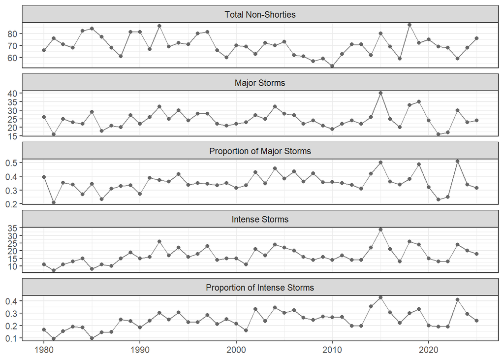

### Regression Methods

#### Poisson Regression on non-Shorties

```
Call:  glm(formula = Total_Storms ~ YearsSinceStart, family = poisson(link = "log"),
    data = storm_basin)

Coefficients:
    (Intercept)  YearsSinceStart
       4.299518        -0.002218

Degrees of Freedom: 45 Total (i.e. Null);  44 Residual
Null Deviance:      42.58
Residual Deviance: 39.79    AIC: 323.6
```

```
Single term deletions

Model:
Total_Storms ~ YearsSinceStart
                Df Deviance    AIC    LRT Pr(>Chi)
<none>               39.786 323.64
YearsSinceStart  1   42.581 324.43 2.7955  0.09453 .
---
Signif. codes:  0 '***' 0.001 '**' 0.01 '*' 0.05 '.' 0.1 ' ' 1
```

Using this model, we would predict 73.6642858 storms in 1980 and 66.6669008 storms in 2025.

That is a change of -1.5211706 storms per decade.

#### Poisson Regression on Major Storms

```
Call:  glm(formula = Major_Storms ~ YearsSinceStart, family = poisson(link = "log"),
    data = storm_basin)

Coefficients:
    (Intercept)  YearsSinceStart
       3.170666         0.001588

Degrees of Freedom: 45 Total (i.e. Null);  44 Residual
Null Deviance:      42.59
Residual Deviance: 42.08    AIC: 277.6
```

```
Single term deletions

Model:
Major_Storms ~ YearsSinceStart
                Df Deviance   AIC     LRT Pr(>Chi)
<none>               42.085 277.6
YearsSinceStart  1   42.590 276.1 0.50509   0.4773
```

Using this model the number of a major storm in 1980 was 23.8233455 and 25.5885183 in 2025.

That is a change of 0.3837332 storms per decade.

#### Poisson Regression on Intense Storms

```
Call:  glm(formula = Intense_Storms ~ YearsSinceStart, family = poisson(link = "log"),
    data = storm_basin)

Coefficients:
    (Intercept)  YearsSinceStart
       2.601652         0.009802

Degrees of Freedom: 45 Total (i.e. Null);  44 Residual
Null Deviance:      73.23
Residual Deviance: 60.09    AIC: 277.1
```

```
Single term deletions

Model:
Intense_Storms ~ YearsSinceStart
                Df Deviance    AIC    LRT  Pr(>Chi)
<none>               60.090 277.13
YearsSinceStart  1   73.232 288.28 13.142 0.0002887 ***
---
Signif. codes:  0 '***' 0.001 '**' 0.01 '*' 0.05 '.' 0.1 ' ' 1
```

Using this model the number of a intense storm in 1980 was 13.4859981 and 20.9627555 in 2025.

That is a change of 1.625382 storms per decade.

#### Logistic Regression on Proportions of Major

```
Call:  glm(formula = cbind(Major_Storms, Non_Major) ~ YearsSinceStart,
    family = binomial, data = prop_data)

Coefficients:
    (Intercept)  YearsSinceStart
      -0.737546         0.005767

Degrees of Freedom: 45 Total (i.e. Null);  44 Residual
Null Deviance:      59.3
Residual Deviance: 54.91    AIC: 270.1
```

```
Single term deletions

Model:
cbind(Major_Storms, Non_Major) ~ YearsSinceStart
                Df Deviance    AIC    LRT Pr(>Chi)
<none>               54.907 270.15
YearsSinceStart  1   59.300 272.54 4.3931  0.03608 *
---
Signif. codes:  0 '***' 0.001 '**' 0.01 '*' 0.05 '.' 0.1 ' ' 1
```

Using this model the probability of a major storm in 1980 was 0.323541 and 0.3827122 in 2025.

That is a change of 1.286331 percent per decade.

#### Logistic Regression on Proportions of Intense

```
Call:  glm(formula = cbind(Intense_Storms, Non_Intense) ~ YearsSinceStart,
    family = binomial, data = prop_data)

Coefficients:
    (Intercept)  YearsSinceStart
       -1.49808          0.01558

Degrees of Freedom: 45 Total (i.e. Null);  44 Residual
Null Deviance:      95.57
Residual Deviance: 69.97    AIC: 274
```

```
Single term deletions

Model:
cbind(Intense_Storms, Non_Intense) ~ YearsSinceStart
                Df Deviance   AIC    LRT  Pr(>Chi)
<none>               69.969 274.0
YearsSinceStart  1   95.571 297.6 25.602 4.196e-07 ***
---
Signif. codes:  0 '***' 0.001 '**' 0.01 '*' 0.05 '.' 0.1 ' ' 1
```

Using this model the probability of an intense storm in 1980 was 0.1827126 and 0.3106283 in 2025.

That is a change of 2.7807767 percent per decade.

### Changepoint Methods

#### Change in Non-Shorty Counts

```
  SCUSUM Stat chpt Location       p-value
   0.47539287   18.00000000    0.04988123
```

The dates suggest the changepoint would occur from 1997 to 1998 with $p$-value 0.0498812.

In regime one, the mean number of total storms is 74.5 and in regime two, the mean number of storms is 67.2857143; a change of -7.2142857.

#### Change in counts of major storms

```
  SCUSUM Stat chpt Location       p-value
    0.1044240    11.0000000     0.6639078
```

The dates suggest the changepoint would occur from 1990 to 1991 with $p$-value 0.6639078.

In regime one, the mean number of major storms is 22.6363636 and in regime two, the mean number of storms is 25.3428571; a change of 2.7064935.

#### Change in counts of intense storms

```
  SCUSUM Stat chpt Location       p-value
 1.387755e+00  1.200000e+01  3.235722e-04
```

The dates suggest the changepoint would occur from 1991 to 1992 with $p$-value 3.2357224^{-4}.

In regime one, the mean number of intense storms is 12.5833333 and in regime two, the mean number of storms is 18.5; a change of 5.9166667.

#### Proportion of major storms

A change in the proportion of major storms?

```
  SCUSUM Stat chpt Location       p-value
   0.57608652   11.00000000    0.02756876
```

The change in proportions occurs 1990 to 1991 with $p$-value 0.0275688.

In regime one, the proportion of major storms is 0.3055215 and in regime two, the proportion of major storms is 0.3680498; a change of 0.0625283.

#### Proportion of intense storms

A change in the proportion of major storms?

```
  SCUSUM Stat chpt Location       p-value
 2.620880e+00  2.200000e+01  5.359492e-07
```

The change in proportions occurs 2001 to 2002 with $p$-value 5.3594924^{-7}.

In regime one, the proportion of intense storms is 0.2042341 and in regime two, the proportion of major storms is 0.2791847; a change of 0.0749506.

## IBTracs Test Results

**Generalized Linear Model Approaches**

Note:

- we report the Likelihood Ratio Test for the generalized linear models, this is better to use than the default $Z$-test provided in the `summary()` output.
- the Change per decade is found by comparing the predicted value at the start time (1980) and end time (2025) and scaling by the number of years $\times 10$.

| Response | Coefficent | p.value | Start | End | Change per Decade |
| --- | --- | --- | --- | --- | --- |
| Cyclone Freq | -0.00222 | 0.09453 | 73.66429 | 66.66690 | -1.52117 |
| Major Freq | 0.00159 | 0.47727 | 23.82335 | 25.58852 | 0.38373 |
| Prop Major | 0.00577 | 0.03608 | 32.35410 | 38.27122 | 1.28633 |
| Intense Freq | 0.00980 | 0.00029 | 13.48600 | 20.96276 | 1.62538 |
| Prop Freq | 0.01558 | 0.00000 | 18.27126 | 31.06283 | 2.78078 |

**Changepoint Methods**

| Response | Chpt.Location | p.value | Regime1 | Regime2 | Change | Perc_Change |
| --- | --- | --- | --- | --- | --- | --- |
| Cyclone Freq | 1998 | 0.04988 | 74.50000 | 67.28571 | -7.21429 | -9.68360 |
| Major Freq | 1991 | 0.66391 | 22.63636 | 25.34286 | 2.70649 | 11.95640 |
| Prop Major | 1991 | 0.02757 | 30.55215 | 36.80498 | 6.25283 | 20.46610 |
| Intense Freq | 1992 | 0.00032 | 12.58333 | 18.50000 | 5.91667 | 47.01987 |
| Prop Freq | 2002 | 0.00000 | 20.42341 | 27.91847 | 7.49506 | 36.69835 |

## HURSAT Full Analysis

### Summary Statistics (overall)

| Total Storms (Avg) | Total Storms (stddev) | Major Storms (Avg) | Major Storms (stddev) | Prop Major Storms | Intense Storms (Avg) | Intense Storms (stddev) | Prop Intense Storms |
| --- | --- | --- | --- | --- | --- | --- | --- |
| 85.21622 | 9.16253 | 24.62162 | 5.335163 | 0.2889312 | 16.40541 | 4.884553 | 0.1925151 |

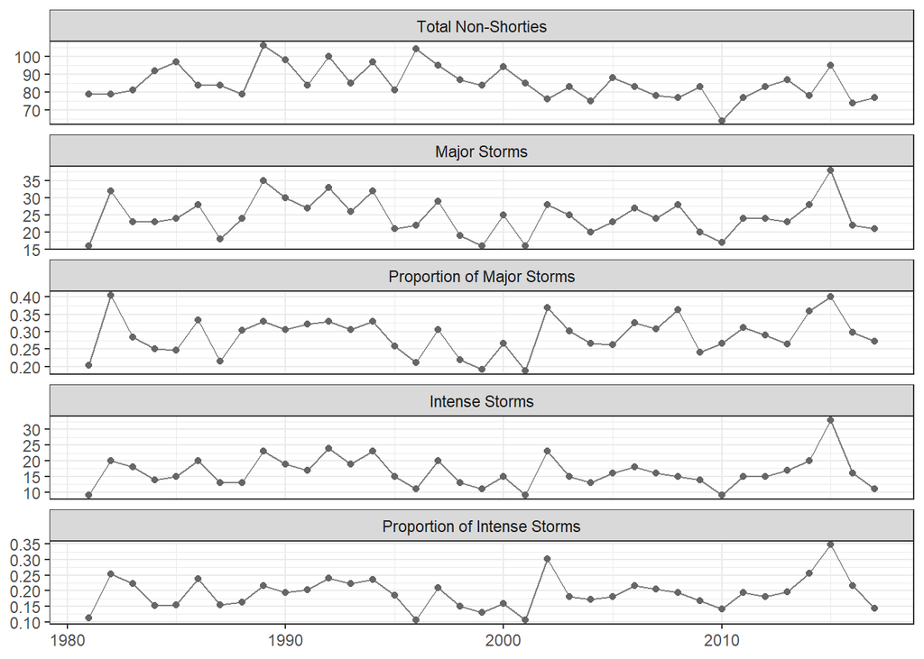

### Regression Methods

#### Poisson Regression on non-Shorties

```
Call:  glm(formula = Total_Storms ~ YearsSinceStart, family = poisson(link = "log"),
    data = storm_basin)

Coefficients:
    (Intercept)  YearsSinceStart
       4.508391        -0.003551

Degrees of Freedom: 36 Total (i.e. Null);  35 Residual
Null Deviance:      35.15
Residual Deviance: 30.62    AIC: 267
```

```
Single term deletions

Model:
Total_Storms ~ YearsSinceStart
                Df Deviance    AIC    LRT Pr(>Chi)
<none>               30.622 266.96
YearsSinceStart  1   35.153 269.49 4.5304   0.0333 *
---
Signif. codes:  0 '***' 0.001 '**' 0.01 '*' 0.05 '.' 0.1 ' ' 1
```

Using this model, we would predict 90.7756025 storms in 1981 and 79.8824099 storms in 2017.

That is a change of -2.9441061 storms per decade.

#### Poisson Regression on Major Storms

```
Call:  glm(formula = Major_Storms ~ YearsSinceStart, family = poisson(link = "log"),
    data = storm_basin)

Coefficients:
    (Intercept)  YearsSinceStart
        3.22676         -0.00129

Degrees of Freedom: 36 Total (i.e. Null);  35 Residual
Null Deviance:      41.27
Residual Deviance: 41.1     AIC: 231
```

```
Single term deletions

Model:
Major_Storms ~ YearsSinceStart
                Df Deviance    AIC    LRT Pr(>Chi)
<none>               41.099 231.05
YearsSinceStart  1   41.272 229.22 0.1729   0.6775
```

Using this model the number of a major storm in 1981 was 25.1977796 and 24.0540719 in 2017.

That is a change of -0.3091102 storms per decade.

#### Poisson Regression on Intense Storms

```
Call:  glm(formula = Intense_Storms ~ YearsSinceStart, family = poisson(link = "log"),
    data = storm_basin)

Coefficients:
    (Intercept)  YearsSinceStart
      2.7942273        0.0001879

Degrees of Freedom: 36 Total (i.e. Null);  35 Residual
Null Deviance:      49.89
Residual Deviance: 49.88    AIC: 224.3
```

```
Single term deletions

Model:
Intense_Storms ~ YearsSinceStart
                Df Deviance    AIC       LRT Pr(>Chi)
<none>               49.884 224.29
YearsSinceStart  1   49.887 222.29 0.0024423   0.9606
```

Using this model the number of a intense storms in 1981 was 16.3499896 and 16.4609428 in 2017.

That is a change of 0.0299873 storms per decade.

#### Logistic Regression on Proportions of Major

```
Call:  glm(formula = cbind(Major_Storms, Non_Major) ~ YearsSinceStart,
    family = binomial, data = prop_data)

Coefficients:
    (Intercept)  YearsSinceStart
      -0.958165         0.003259

Degrees of Freedom: 36 Total (i.e. Null);  35 Residual
Null Deviance:      45.24
Residual Deviance: 44.47    AIC: 221.7
```

```
Single term deletions

Model:
cbind(Major_Storms, Non_Major) ~ YearsSinceStart
                Df Deviance    AIC     LRT Pr(>Chi)
<none>               44.474 221.72
YearsSinceStart  1   45.239 220.49 0.76478   0.3818
```

Using this model the probability of a major storm in 1981 was 0.2772457 and 0.3013544 in 2017.

That is a change of 0.6515848 percent per decade.

#### Logistic Regression on Proportions of Intense

```
Call:  glm(formula = cbind(Intense_Storms, Non_Intense) ~ YearsSinceStart,
    family = binomial, data = prop_data)

Coefficients:
    (Intercept)  YearsSinceStart
      -1.518002         0.004745

Degrees of Freedom: 36 Total (i.e. Null);  35 Residual
Null Deviance:      51.9
Residual Deviance: 50.67    AIC: 217.1
```

```
Single term deletions

Model:
cbind(Intense_Storms, Non_Intense) ~ YearsSinceStart
                Df Deviance    AIC    LRT Pr(>Chi)
<none>               50.673 217.12
YearsSinceStart  1   51.900 216.35 1.2274   0.2679
```

Using this model the probability of an intense storm in 1981 was 0.1797559 and 0.2063292 in 2017.

That is a change of 0.7181977 percent per decade.

### Changepoint Methods

#### Change in Non-Shorty Counts

```
  SCUSUM Stat chpt Location       p-value
   0.69537076   20.00000000    0.01392862
```

The dates suggest the changepoint would occur from 2000 to 2001 with $p$-value 0.0139286.

In regime one, the mean number of total storms is 89.5 and in regime two, the mean number of storms is 80.1764706; a change of -9.3235294.

#### Change in counts of major storms

```
  SCUSUM Stat chpt Location       p-value
    0.1295536    14.0000000     0.5265341
```

The dates suggest the changepoint would occur from 1994 to 1995 with $p$-value 0.5265341.

In regime one, the mean number of major storms is 26.5 and in regime two, the mean number of storms is 23.4782609; a change of -3.0217391.

#### Change in counts of intense storms

```
  SCUSUM Stat chpt Location       p-value
    0.1100059    14.0000000     0.6292705
```

The dates suggest the changepoint would occur from 1994 to 1995 with $p$-value 0.6292705.

In regime one, the mean number of intense storms is 17.6428571 and in regime two, the mean number of storms is 15.6521739; a change of -1.9906832.

#### Proportion of major storms

A change in the proportion of major storms?

```
  SCUSUM Stat chpt Location       p-value
    0.1651585    21.0000000     0.3911958
```

The change in proportions occurs 2001 to 2002 with $p$-value 0.3911958.

In regime one, the proportion of major storms is 0.2768 and in regime two, the proportion of major storms is 0.3067293; a change of 0.0299293.

#### Proportion of intense storms

A change in the proportion of major storms?

```
  SCUSUM Stat chpt Location       p-value
    0.1671876    21.0000000     0.3849408
```

The change in proportions occurs 2001 to 2002 with $p$-value 0.3849408.

In regime one, the proportion of intense storms is 0.1818667 and in regime two, the proportion of major storms is 0.2081377; a change of 0.026271.

## HURSAT Test Results

**Generalized Linear Model Approaches**

Note:

- we report the Likelihood Ratio Test for the generalized linear models, this is better to use than the default $Z$-test provided in the `summary()` output.
- the Change per decade is found by comparing the predicted value at the start time (1981) and end time (2017) and scaling by the number of years $\times 10$.

| Response | Coefficent | p.value | Start | End | Change per Decade |
| --- | --- | --- | --- | --- | --- |
| Cyclone Freq | -0.00355 | 0.03330 | 90.77560 | 79.88241 | -2.94411 |
| Major Freq | -0.00129 | 0.67755 | 25.19778 | 24.05407 | -0.30911 |
| Prop Major | 0.00326 | 0.38184 | 27.72457 | 30.13544 | 0.65158 |
| Intense Freq | 0.00019 | 0.96059 | 16.34999 | 16.46094 | 0.02999 |
| Prop Freq | 0.00474 | 0.26791 | 17.97559 | 20.63292 | 0.71820 |

**Changepoint Methods**

| Response | Chpt.Location | p.value | Regime1 | Regime2 | Change | Perc_Change |
| --- | --- | --- | --- | --- | --- | --- |
| Cyclone Freq | 2001 | 0.01393 | 89.50000 | 80.17647 | -9.32353 | -10.41735 |
| Major Freq | 1995 | 0.52653 | 26.50000 | 23.47826 | -3.02174 | -11.40279 |
| Prop Major | 2002 | 0.39120 | 27.68000 | 30.67293 | 2.99293 | 10.81260 |
| Intense Freq | 1995 | 0.62927 | 17.64286 | 15.65217 | -1.99068 | -11.28322 |
| Prop Freq | 2002 | 0.38494 | 18.18667 | 20.81377 | 2.62710 | 14.44522 |

## Trimmed IBTRacs Full Analysis

### Summary Statistics (overall)

| Total Storms (Avg) | Total Storms (stddev) | Major Storms (Avg) | Major Storms (stddev) | Prop Major Storms | Intense Storms (Avg) | Intense Storms (stddev) | Prop Intense Storms |
| --- | --- | --- | --- | --- | --- | --- | --- |
| 69.86486 | 8.313851 | 24.54054 | 4.519062 | 0.3512573 | 16.64865 | 5.297883 | 0.2382979 |

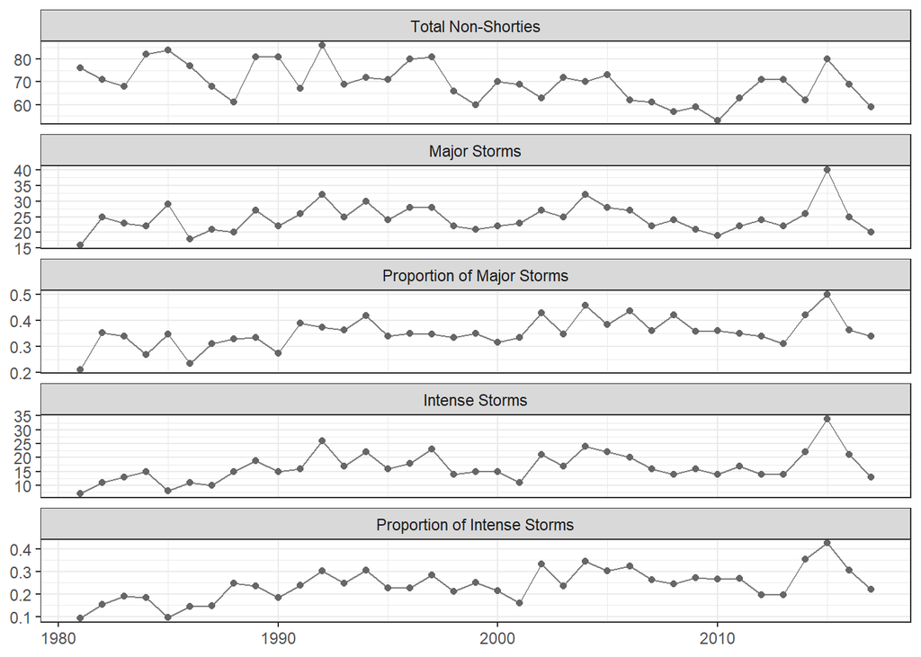

### Regression Methods

#### Poisson Regression on non-Shorties

```
Call:  glm(formula = Total_Storms ~ YearsSinceStart, family = poisson(link = "log"),
    data = storm_basin)

Coefficients:
    (Intercept)  YearsSinceStart
         4.3404          -0.0053

Degrees of Freedom: 36 Total (i.e. Null);  35 Residual
Null Deviance:      35.65
Residual Deviance: 27.38    AIC: 256.3
```

```
Single term deletions

Model:
Total_Storms ~ YearsSinceStart
                Df Deviance    AIC    LRT Pr(>Chi)
<none>               27.382 256.34
YearsSinceStart  1   35.654 262.61 8.2714 0.004027 **
---
Signif. codes:  0 '***' 0.001 '**' 0.01 '*' 0.05 '.' 0.1 ' ' 1
```

Using this model, we would predict 76.7359851 storms in 1981 and 63.4056617 storms in 2017.

That is a change of -3.6027901 storms per decade.

#### Poisson Regression on Major Storms

```
Call:  glm(formula = Major_Storms ~ YearsSinceStart, family = poisson(link = "log"),
    data = storm_basin)

Coefficients:
    (Intercept)  YearsSinceStart
        3.14856          0.00285

Degrees of Freedom: 36 Total (i.e. Null);  35 Residual
Null Deviance:      28.74
Residual Deviance: 27.9     AIC: 218
```

```
Single term deletions

Model:
Major_Storms ~ YearsSinceStart
                Df Deviance    AIC    LRT Pr(>Chi)
<none>               27.899 218.00
YearsSinceStart  1   28.739 216.84 0.8408   0.3592
```

Using this model the number of a major storm in 1981 was 23.3023792 and 25.8205658 in 2017.

That is a change of 0.680591 storms per decade.

#### Poisson Regression on Intense Storms

```
Call:  glm(formula = Intense_Storms ~ YearsSinceStart, family = poisson(link = "log"),
    data = storm_basin)

Coefficients:
    (Intercept)  YearsSinceStart
        2.58142          0.01235

Degrees of Freedom: 36 Total (i.e. Null);  35 Residual
Null Deviance:      58.49
Residual Deviance: 47.84    AIC: 222.5
```

```
Single term deletions

Model:
Intense_Storms ~ YearsSinceStart
                Df Deviance    AIC    LRT Pr(>Chi)
<none>               47.842 222.52
YearsSinceStart  1   58.491 231.17 10.649 0.001102 **
---
Signif. codes:  0 '***' 0.001 '**' 0.01 '*' 0.05 '.' 0.1 ' ' 1
```

Using this model the number of an intense storm in 1981 was 13.215934 and 20.6123008 in 2017.

That is a change of 1.9990181 storms per decade.

#### Logistic Regression on Proportions of Major

```
Call:  glm(formula = cbind(Major_Storms, Non_Major) ~ YearsSinceStart,
    family = binomial, data = prop_data)

Coefficients:
    (Intercept)  YearsSinceStart
       -0.83448          0.01255

Degrees of Freedom: 36 Total (i.e. Null);  35 Residual
Null Deviance:      38.25
Residual Deviance: 27.68    AIC: 201.6
```

```
Single term deletions

Model:
cbind(Major_Storms, Non_Major) ~ YearsSinceStart
                Df Deviance    AIC    LRT Pr(>Chi)
<none>               27.676 201.57
YearsSinceStart  1   38.250 210.15 10.574 0.001147 **
---
Signif. codes:  0 '***' 0.001 '**' 0.01 '*' 0.05 '.' 0.1 ' ' 1
```

Using this model the probability of a major storm in 1981 was 0.3026992 and 0.4054713 in 2017.

That is a change of 2.7776253 percent per decade.

#### Logistic Regression on Proportions of Intense

```
Call:  glm(formula = cbind(Intense_Storms, Non_Intense) ~ YearsSinceStart,
    family = binomial, data = prop_data)

Coefficients:
    (Intercept)  YearsSinceStart
       -1.58091          0.02316

Degrees of Freedom: 36 Total (i.e. Null);  35 Residual
Null Deviance:      77.01
Residual Deviance: 48.46    AIC: 212.9
```

```
Single term deletions

Model:
cbind(Intense_Storms, Non_Intense) ~ YearsSinceStart
                Df Deviance    AIC    LRT  Pr(>Chi)
<none>               48.464 212.85
YearsSinceStart  1   77.005 239.39 28.541 9.172e-08 ***
---
Signif. codes:  0 '***' 0.001 '**' 0.01 '*' 0.05 '.' 0.1 ' ' 1
```

Using this model the probability of an intense storm in 1981 was 0.1706664 and 0.3214575 in 2017.

That is a change of 4.0754371 percent per decade.

### Changepoint Methods

#### Change in Non-Shorty Counts

```
  SCUSUM Stat chpt Location       p-value
  0.979027174  17.000000000   0.002895333
```

The dates suggest the changepoint would occur from 1997 to 1998 with $p$-value 0.0028953.

In regime one, the mean number of total storms is 75 and in regime two, the mean number of storms is 65.5; a change of -9.5.

#### Change in counts of major storms

```
  SCUSUM Stat chpt Location       p-value
    0.1297508    10.0000000     0.5256223
```

The dates suggest the changepoint would occur from 1990 to 1991 with $p$-value 0.5256223.

In regime one, the mean number of major storms is 22.3 and in regime two, the mean number of storms is 25.3703704; a change of 3.0703704.

#### Change in counts of intense storms

```
  SCUSUM Stat chpt Location       p-value
   1.10402891    8.00000000    0.00147132
```

The dates suggest the changepoint would occur from 1988 to 1989 with $p$-value 0.0014713.

In regime one, the mean number of intense storms is 11.25 and in regime two, the mean number of storms is 18.137931; a change of 6.887931.

#### Proportion of major storms

A change in the proportion of major storms?

```
  SCUSUM Stat chpt Location       p-value
  0.987899907  10.000000000   0.002758822
```

The change in proportions occurs 1990 to 1991 with $p$-value 0.0027588.

In regime one, the proportion of major storms is 0.2977303 and in regime two, the proportion of major storms is 0.3730937; a change of 0.0753634.

#### Proportion of intense storms

A change in the proportion of major storms?

```
  SCUSUM Stat chpt Location       p-value
 2.590321e+00  1.100000e+01  6.268503e-07
```

The change in proportions occurs 1991 to 1992 with $p$-value 6.2685032^{-7}.

In regime one, the proportion of intense storms is 0.1715686 and in regime two, the proportion of major storms is 0.2690786; a change of 0.0975099.

## Trimmed IBTRacs Test Results

**Generalized Linear Model Approaches**

Note:

- we report the Likelihood Ratio Test for the generalized linear models, this is better to use than the default $Z$-test provided in the `summary()` output.
- the Change per decade is found by comparing the predicted value at the start time (1981) and end time (2017) and scaling by the number of years $\times 10$.

| Response | Coefficent | p.value | Start | End | Change per Decade |
| --- | --- | --- | --- | --- | --- |
| Cyclone Freq | -0.00530 | 0.00403 | 76.73599 | 63.40566 | -3.60279 |
| Major Freq | 0.00285 | 0.35917 | 23.30238 | 25.82057 | 0.68059 |
| Prop Major | 0.01255 | 0.00115 | 30.26992 | 40.54713 | 2.77763 |
| Intense Freq | 0.01235 | 0.00110 | 13.21593 | 20.61230 | 1.99902 |
| Prop Freq | 0.02316 | 0.00000 | 17.06664 | 32.14575 | 4.07544 |

**Changepoint Methods**

| Response | Chpt.Location | p.value | Regime1 | Regime2 | Change | Perc_Change |
| --- | --- | --- | --- | --- | --- | --- |
| Cyclone Freq | 1998 | 0.00290 | 75.00000 | 65.50000 | -9.50000 | -12.66667 |
| Major Freq | 1991 | 0.52562 | 22.30000 | 25.37037 | 3.07037 | 13.76848 |
| Prop Major | 1991 | 0.00276 | 29.77303 | 37.30937 | 7.53634 | 25.31263 |
| Intense Freq | 1989 | 0.00147 | 11.25000 | 18.13793 | 6.88793 | 61.22605 |
| Prop Freq | 1992 | 0.00000 | 17.15686 | 26.90786 | 9.75099 | 56.83437 |

# North Atlantic

## IBTracs Full Analysis

### Summary Statistics (overall)

| Total Storms (Avg) | Total Storms (stddev) | Major Storms (Avg) | Major Storms (stddev) | Prop Major Storms | Intense Storms (Avg) | Intense Storms (stddev) | Prop Intense Storms |
| --- | --- | --- | --- | --- | --- | --- | --- |
| 10.45652 | 4.370134 | 2.913044 | 1.847835 | 0.2785863 | 1.847826 | 1.519757 | 0.1767152 |

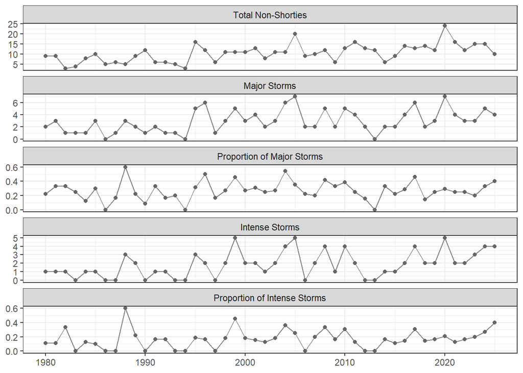

### Regression Methods

#### Poisson Regression on non-Shorties

```
Call:  glm(formula = Total_Storms ~ YearsSinceStart, family = poisson(link = "log"),
    data = storm_basin)

Coefficients:
    (Intercept)  YearsSinceStart
        1.89698          0.01866

Degrees of Freedom: 45 Total (i.e. Null);  44 Residual
Null Deviance:      83.14
Residual Deviance: 54.17    AIC: 247.2
```

```
Single term deletions

Model:
Total_Storms ~ YearsSinceStart
                Df Deviance    AIC    LRT  Pr(>Chi)
<none>               54.171 247.18
YearsSinceStart  1   83.144 274.15 28.973 7.339e-08 ***
---
Signif. codes:  0 '***' 0.001 '**' 0.01 '*' 0.05 '.' 0.1 ' ' 1
```

Using this model, we would predict 6.665732 storms in 1980 and 15.43289 storms in 2025.

That is a change of 1.9059039 storms per decade.

#### Poisson Regression on Major Storms

```
Call:  glm(formula = Major_Storms ~ YearsSinceStart, family = poisson(link = "log"),
    data = storm_basin)

Coefficients:
    (Intercept)  YearsSinceStart
        0.58054          0.02014

Degrees of Freedom: 45 Total (i.e. Null);  44 Residual
Null Deviance:      58.19
Residual Deviance: 48.81    AIC: 176.8
```

```
Single term deletions

Model:
Major_Storms ~ YearsSinceStart
                Df Deviance    AIC    LRT Pr(>Chi)
<none>               48.812 176.81
YearsSinceStart  1   58.191 184.19 9.3792 0.002195 **
---
Signif. codes:  0 '***' 0.001 '**' 0.01 '*' 0.05 '.' 0.1 ' ' 1
```

Using this model the number of a major storm in 1980 was 1.7870006 and 4.42322 in 2025.

That is a change of 0.5730912 storms per decade.

#### Poisson Regression on Intense Storms

```
Call:  glm(formula = Intense_Storms ~ YearsSinceStart, family = poisson(link = "log"),
    data = storm_basin)

Coefficients:
    (Intercept)  YearsSinceStart
       -0.09641          0.02845

Degrees of Freedom: 45 Total (i.e. Null);  44 Residual
Null Deviance:      66.26
Residual Deviance: 54.63    AIC: 153.6
```

```
Single term deletions

Model:
Intense_Storms ~ YearsSinceStart
                Df Deviance    AIC    LRT  Pr(>Chi)
<none>               54.634 153.62
YearsSinceStart  1   66.262 163.25 11.628 0.0006497 ***
---
Signif. codes:  0 '***' 0.001 '**' 0.01 '*' 0.05 '.' 0.1 ' ' 1
```

Using this model the number of a intense storm in 1980 was 0.9080904 and 3.2666721 in 2025.

That is a change of 0.5127352 storms per decade.

#### Logistic Regression on Proportions of Major

```
Call:  glm(formula = cbind(Major_Storms, Non_Major) ~ YearsSinceStart,
    family = binomial, data = prop_data)

Coefficients:
    (Intercept)  YearsSinceStart
      -1.006405         0.002127

Degrees of Freedom: 45 Total (i.e. Null);  44 Residual
Null Deviance:      38.28
Residual Deviance: 38.21    AIC: 151.3
```

```
Single term deletions

Model:
cbind(Major_Storms, Non_Major) ~ YearsSinceStart
                Df Deviance    AIC      LRT Pr(>Chi)
<none>               38.207 151.32
YearsSinceStart  1   38.279 149.39 0.071634    0.789
```

Using this model the probability of a major storm in 1980 was 0.267684 and 0.2868545 in 2025.

That is a change of 0.4167513 percent per decade.

#### Logistic Regression on Proportions of Intense

```
Call:  glm(formula = cbind(Intense_Storms, Non_Intense) ~ YearsSinceStart,
    family = binomial, data = prop_data)

Coefficients:
    (Intercept)  YearsSinceStart
       -1.86288          0.01228

Degrees of Freedom: 45 Total (i.e. Null);  44 Residual
Null Deviance:      52.24
Residual Deviance: 50.56    AIC: 140.6
```

```
Single term deletions

Model:
cbind(Intense_Storms, Non_Intense) ~ YearsSinceStart
                Df Deviance    AIC    LRT Pr(>Chi)
<none>               50.556 140.65
YearsSinceStart  1   52.243 140.33 1.6866   0.1941
```

Using this model the probability of an intense storm in 1980 was 0.1343677 and 0.2124283 in 2025.

That is a change of 1.6969694 percent per decade.

### Changepoint Methods

#### Change in Non-Shorty Counts

```
  SCUSUM Stat chpt Location       p-value
 2.989222e+00  1.500000e+01  8.149900e-08
```

The dates suggest the changepoint would occur from 1994 to 1995 with $p$-value 8.1499002^{-8}.

In regime one, the mean number of total storms is 6.6666667 and in regime two, the mean number of storms is 12.2903226; a change of 5.6236559.

#### Change in counts of major storms

```
  SCUSUM Stat chpt Location       p-value
  1.008414920  15.000000000   0.002467708
```

The dates suggest the changepoint would occur from 1994 to 1995 with $p$-value 0.0024677.

In regime one, the mean number of major storms is 1.4666667 and in regime two, the mean number of storms is 3.6129032; a change of 2.1462366.

#### Change in counts of intense storms

```
  SCUSUM Stat chpt Location       p-value
  1.150686645  18.000000000   0.001144785
```

The dates suggest the changepoint would occur from 1997 to 1998 with $p$-value 0.0011448.

In regime one, the mean number of intense storms is 0.9444444 and in regime two, the mean number of storms is 2.4285714; a change of 1.484127.

#### Proportion of major storms

A change in the proportion of major storms?

```
  SCUSUM Stat chpt Location       p-value
   0.07746082   15.00000000    0.68220957
```

The change in proportions occurs 1994 to 1995 with $p$-value 0.6822096.

In regime one, the proportion of major storms is 0.22 and in regime two, the proportion of major storms is 0.2939633; a change of 0.0739633.

#### Proportion of intense storms

A change in the proportion of major storms?

```
  SCUSUM Stat chpt Location       p-value
    0.1814216    18.0000000     0.3444654
```

The change in proportions occurs 1997 to 1998 with $p$-value 0.3444654.

In regime one, the proportion of intense storms is 0.1268657 and in regime two, the proportion of major storms is 0.1959654; a change of 0.0690997.

## IBTracs Test Results

**Generalized Linear Model Approaches**

Note:

- we report the Likelihood Ratio Test for the generalized linear models, this is better to use than the default $Z$-test provided in the `summary()` output.
- the Change per decade is found by comparing the predicted value at the start time (1980) and end time (2025) and scaling by the number of years $\times 10$.

| Response | Coefficent | p.value | Start | End | Change per Decade |
| --- | --- | --- | --- | --- | --- |
| Cyclone Freq | 0.01866 | 0.00000 | 6.66573 | 15.43289 | 1.90590 |
| Major Freq | 0.02014 | 0.00219 | 1.78700 | 4.42322 | 0.57309 |
| Prop Major | 0.00213 | 0.78897 | 26.76840 | 28.68545 | 0.41675 |
| Intense Freq | 0.02845 | 0.00065 | 0.90809 | 3.26667 | 0.51274 |
| Prop Freq | 0.01228 | 0.19405 | 13.43677 | 21.24283 | 1.69697 |

**Changepoint Methods**

| Response | Chpt.Location | p.value | Regime1 | Regime2 | Change | Perc_Change |
| --- | --- | --- | --- | --- | --- | --- |
| Cyclone Freq | 1995 | 0.00000 | 6.66667 | 12.29032 | 5.62366 | 84.35484 |
| Major Freq | 1995 | 0.00247 | 1.46667 | 3.61290 | 2.14624 | 146.33431 |
| Prop Major | 1995 | 0.68221 | 22.00000 | 29.39633 | 7.39633 | 33.61966 |
| Intense Freq | 1998 | 0.00114 | 0.94444 | 2.42857 | 1.48413 | 157.14286 |
| Prop Freq | 1998 | 0.34447 | 12.68657 | 19.59654 | 6.90997 | 54.46686 |

## HURSAT Full Analysis

### Summary Statistics (overall)

| Total Storms (Avg) | Total Storms (stddev) | Major Storms (Avg) | Major Storms (stddev) | Prop Major Storms | Intense Storms (Avg) | Intense Storms (stddev) | Prop Intense Storms |
| --- | --- | --- | --- | --- | --- | --- | --- |
| 10.86486 | 3.980244 | 2.675676 | 2.055535 | 0.2462687 | 1.567568 | 1.38525 | 0.1442786 |

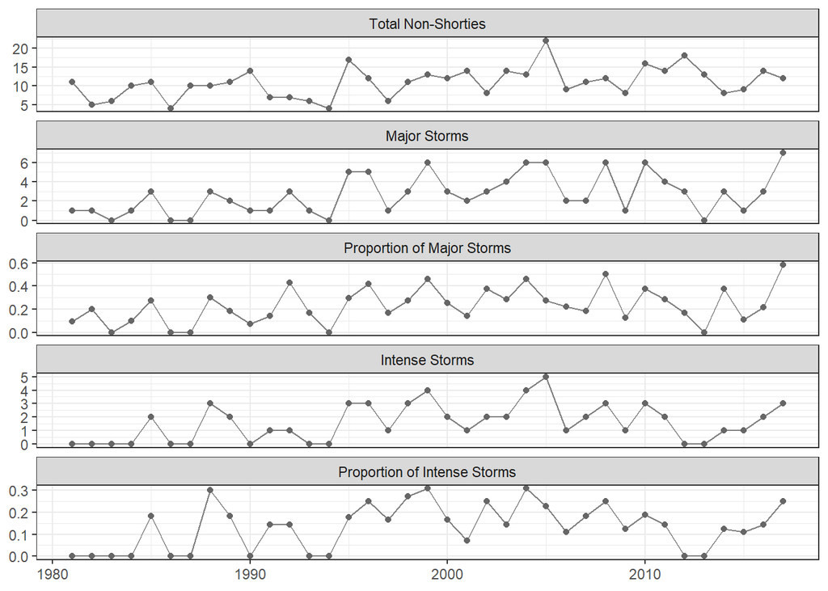

### Regression Methods

#### Poisson Regression on non-Shorties

```
Call:  glm(formula = Total_Storms ~ YearsSinceStart, family = poisson(link = "log"),
    data = storm_basin)

Coefficients:
    (Intercept)  YearsSinceStart
        2.11967          0.01414

Degrees of Freedom: 36 Total (i.e. Null);  35 Residual
Null Deviance:      53.33
Residual Deviance: 44.23    AIC: 202.5
```

```
Single term deletions

Model:
Total_Storms ~ YearsSinceStart
                Df Deviance    AIC    LRT Pr(>Chi)
<none>               44.229 202.49
YearsSinceStart  1   53.328 209.59 9.0986 0.002558 **
---
Signif. codes:  0 '***' 0.001 '**' 0.01 '*' 0.05 '.' 0.1 ' ' 1
```

Using this model, we would predict 8.3284164 storms in 1981 and 13.855172 storms in 2017.

That is a change of 1.4937178 storms per decade.

#### Poisson Regression on Major Storms

```
Call:  glm(formula = Major_Storms ~ YearsSinceStart, family = poisson(link = "log"),
    data = storm_basin)

Coefficients:
    (Intercept)  YearsSinceStart
         0.3484           0.0321

Degrees of Freedom: 36 Total (i.e. Null);  35 Residual
Null Deviance:      64.66
Residual Deviance: 53.43    AIC: 148.4
```

```
Single term deletions

Model:
Major_Storms ~ YearsSinceStart
                Df Deviance    AIC    LRT  Pr(>Chi)
<none>               53.430 148.40
YearsSinceStart  1   64.661 157.63 11.231 0.0008042 ***
---
Signif. codes:  0 '***' 0.001 '**' 0.01 '*' 0.05 '.' 0.1 ' ' 1
```

Using this model the number of a major storm in 1981 was 1.4168174 and 4.4991952 in 2017.

That is a change of 0.8330751 storms per decade.

#### Poisson Regression on Intense Storms

```
Call:  glm(formula = Intense_Storms ~ YearsSinceStart, family = poisson(link = "log"),
    data = storm_basin)

Coefficients:
    (Intercept)  YearsSinceStart
       -0.09909          0.02802

Degrees of Freedom: 36 Total (i.e. Null);  35 Residual
Null Deviance:      54.45
Residual Deviance: 49.4     AIC: 121.3
```

```
Single term deletions

Model:
Intense_Storms ~ YearsSinceStart
                Df Deviance    AIC    LRT Pr(>Chi)
<none>               49.399 121.26
YearsSinceStart  1   54.453 124.32 5.0538  0.02457 *
---
Signif. codes:  0 '***' 0.001 '**' 0.01 '*' 0.05 '.' 0.1 ' ' 1
```

Using this model the number of a intense storms in 1981 was 0.9056592 and 2.4829744 in 2017.

That is a change of 0.4263014 storms per decade.

#### Logistic Regression on Proportions of Major

```
Call:  glm(formula = cbind(Major_Storms, Non_Major) ~ YearsSinceStart,
    family = binomial, data = prop_data)

Coefficients:
    (Intercept)  YearsSinceStart
        -1.6277           0.0251

Degrees of Freedom: 36 Total (i.e. Null);  35 Residual
Null Deviance:      53.46
Residual Deviance: 48.62    AIC: 133.4
```

```
Single term deletions

Model:
cbind(Major_Storms, Non_Major) ~ YearsSinceStart
                Df Deviance    AIC    LRT Pr(>Chi)
<none>               48.616 133.36
YearsSinceStart  1   53.464 136.20 4.8473  0.02769 *
---
Signif. codes:  0 '***' 0.001 '**' 0.01 '*' 0.05 '.' 0.1 ' ' 1
```

Using this model the probability of a major storm in 1981 was 0.1641392 and 0.3264752 in 2017.

That is a change of 4.3874596 percent per decade.

#### Logistic Regression on Proportions of Intense

```
Call:  glm(formula = cbind(Intense_Storms, Non_Intense) ~ YearsSinceStart,
    family = binomial, data = prop_data)

Coefficients:
    (Intercept)  YearsSinceStart
       -2.12625          0.01709

Degrees of Freedom: 36 Total (i.e. Null);  35 Residual
Null Deviance:      44.95
Residual Deviance: 43.44    AIC: 109.9
```

```
Single term deletions

Model:
cbind(Intense_Storms, Non_Intense) ~ YearsSinceStart
                Df Deviance    AIC    LRT Pr(>Chi)
<none>               43.441 109.87
YearsSinceStart  1   44.950 109.38 1.5088   0.2193
```

Using this model the probability of an intense storm in 1981 was 0.1065713 and 0.1807854 in 2017.

That is a change of 2.0057852 percent per decade.

### Changepoint Methods

#### Change in Non-Shorty Counts

```
  SCUSUM Stat chpt Location       p-value
  1.049858451  14.000000000   0.001971188
```

The dates suggest the changepoint would occur from 1994 to 1995 with $p$-value 0.0019712.

In regime one, the mean number of total storms is 8.2857143 and in regime two, the mean number of storms is 12.4347826; a change of 4.1490683.

#### Change in counts of major storms

```
  SCUSUM Stat chpt Location       p-value
 1.274055e+00  1.400000e+01  5.918476e-04
```

The dates suggest the changepoint would occur from 1994 to 1995 with $p$-value 5.9184755^{-4}.

In regime one, the mean number of major storms is 1.2142857 and in regime two, the mean number of storms is 3.5652174; a change of 2.3509317.

#### Change in counts of intense storms

```
  SCUSUM Stat chpt Location       p-value
   0.73789073   14.00000000    0.01096209
```

The dates suggest the changepoint would occur from 1994 to 1995 with $p$-value 0.0109621.

In regime one, the mean number of intense storms is 0.6428571 and in regime two, the mean number of storms is 2.1304348; a change of 1.4875776.

#### Proportion of major storms

A change in the proportion of major storms?

```
  SCUSUM Stat chpt Location       p-value
   0.71386928   14.00000000    0.01254763
```

The change in proportions occurs 1994 to 1995 with $p$-value 0.0125476.

In regime one, the proportion of major storms is 0.1465517 and in regime two, the proportion of major storms is 0.2867133; a change of 0.1401616.

#### Proportion of intense storms

A change in the proportion of major storms?

```
  SCUSUM Stat chpt Location       p-value
   0.46173177   14.00000000    0.05414352
```

The change in proportions occurs 1994 to 1995 with $p$-value 0.0541435.

In regime one, the proportion of intense storms is 0.0775862 and in regime two, the proportion of major storms is 0.1713287; a change of 0.0937425.

## HURSAT Test Results

**Generalized Linear Model Approaches**

Note:

- we report the Likelihood Ratio Test for the generalized linear models, this is better to use than the default $Z$-test provided in the `summary()` output.
- the Change per decade is found by comparing the predicted value at the start time (1981) and end time (2017) and scaling by the number of years $\times 10$.

| Response | Coefficent | p.value | Start | End | Change per Decade |
| --- | --- | --- | --- | --- | --- |
| Cyclone Freq | 0.01414 | 0.00256 | 8.32842 | 13.85517 | 1.49372 |
| Major Freq | 0.03210 | 0.00080 | 1.41682 | 4.49920 | 0.83308 |
| Prop Major | 0.02510 | 0.02769 | 16.41392 | 32.64752 | 4.38746 |
| Intense Freq | 0.02802 | 0.02457 | 0.90566 | 2.48297 | 0.42630 |
| Prop Freq | 0.01709 | 0.21933 | 10.65713 | 18.07854 | 2.00579 |

**Changepoint Methods**

| Response | Chpt.Location | p.value | Regime1 | Regime2 | Change | Perc_Change |
| --- | --- | --- | --- | --- | --- | --- |
| Cyclone Freq | 1995 | 0.00197 | 8.28571 | 12.43478 | 4.14907 | 50.07496 |
| Major Freq | 1995 | 0.00059 | 1.21429 | 3.56522 | 2.35093 | 193.60614 |
| Prop Major | 1995 | 0.01255 | 14.65517 | 28.67133 | 14.01616 | 95.63965 |
| Intense Freq | 1995 | 0.01096 | 0.64286 | 2.13043 | 1.48758 | 231.40097 |
| Prop Freq | 1995 | 0.05414 | 7.75862 | 17.13287 | 9.37425 | 120.82362 |

## Trimmed IBTRacs Full Analysis

### Summary Statistics (overall)

| Total Storms (Avg) | Total Storms (stddev) | Major Storms (Avg) | Major Storms (stddev) | Prop Major Storms | Intense Storms (Avg) | Intense Storms (stddev) | Prop Intense Storms |
| --- | --- | --- | --- | --- | --- | --- | --- |
| 9.567568 | 3.926693 | 2.72973 | 1.880435 | 0.2853107 | 1.621622 | 1.497245 | 0.1694915 |

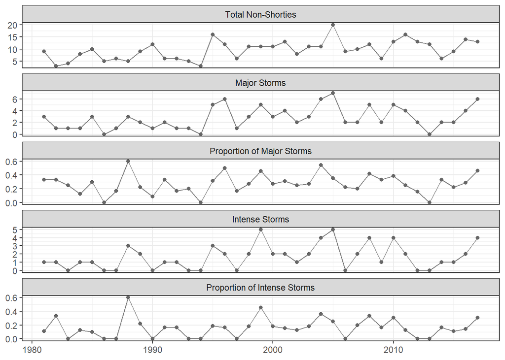

### Regression Methods

#### Poisson Regression on non-Shorties

```
Call:  glm(formula = Total_Storms ~ YearsSinceStart, family = poisson(link = "log"),
    data = storm_basin)

Coefficients:
    (Intercept)  YearsSinceStart
         1.8838           0.0196

Degrees of Freedom: 36 Total (i.e. Null);  35 Residual
Null Deviance:      59.72
Residual Deviance: 44.42    AIC: 197.3
```

```
Single term deletions

Model:
Total_Storms ~ YearsSinceStart
                Df Deviance   AIC    LRT  Pr(>Chi)
<none>               44.423 197.3
YearsSinceStart  1   59.720 210.6 15.297 9.186e-05 ***
---
Signif. codes:  0 '***' 0.001 '**' 0.01 '*' 0.05 '.' 0.1 ' ' 1
```

Using this model, we would predict 6.5787284 storms in 1981 and 13.3208019 storms in 2017.

That is a change of 1.822182 storms per decade.

#### Poisson Regression on Major Storms

```
Call:  glm(formula = Major_Storms ~ YearsSinceStart, family = poisson(link = "log"),
    data = storm_basin)

Coefficients:
    (Intercept)  YearsSinceStart
        0.53915          0.02402

Degrees of Freedom: 36 Total (i.e. Null);  35 Residual
Null Deviance:      51.05
Residual Deviance: 44.53    AIC: 144.5
```

```
Single term deletions

Model:
Major_Storms ~ YearsSinceStart
                Df Deviance    AIC   LRT Pr(>Chi)
<none>               44.534 144.51
YearsSinceStart  1   51.049 149.02 6.515   0.0107 *
---
Signif. codes:  0 '***' 0.001 '**' 0.01 '*' 0.05 '.' 0.1 ' ' 1
```

Using this model the number of a major storm in 1981 was 1.7145508 and 4.0710608 in 2017.

That is a change of 0.6368946 storms per decade.

#### Poisson Regression on Intense Storms

```
Call:  glm(formula = Intense_Storms ~ YearsSinceStart, family = poisson(link = "log"),
    data = storm_basin)

Coefficients:
    (Intercept)  YearsSinceStart
       -0.04483          0.02705

Degrees of Freedom: 36 Total (i.e. Null);  35 Residual
Null Deviance:      56.68
Residual Deviance: 51.79    AIC: 125.3
```

```
Single term deletions

Model:
Intense_Storms ~ YearsSinceStart
                Df Deviance    AIC    LRT Pr(>Chi)
<none>               51.793 125.32
YearsSinceStart  1   56.676 128.21 4.8825  0.02713 *
---
Signif. codes:  0 '***' 0.001 '**' 0.01 '*' 0.05 '.' 0.1 ' ' 1
```

Using this model the number of an intense storm in 1981 was 0.9561613 and 2.5318653 in 2017.

That is a change of 0.4258659 storms per decade.

#### Logistic Regression on Proportions of Major

```
Call:  glm(formula = cbind(Major_Storms, Non_Major) ~ YearsSinceStart,
    family = binomial, data = prop_data)

Coefficients:
    (Intercept)  YearsSinceStart
      -1.053291         0.006631

Degrees of Freedom: 36 Total (i.e. Null);  35 Residual
Null Deviance:      35.01
Residual Deviance: 34.68    AIC: 122.5
```

```
Single term deletions

Model:
cbind(Major_Storms, Non_Major) ~ YearsSinceStart
                Df Deviance    AIC     LRT Pr(>Chi)
<none>               34.680 122.48
YearsSinceStart  1   35.007 120.81 0.32646   0.5678
```

Using this model the probability of a major storm in 1981 was 0.2585937 and 0.3069159 in 2017.

That is a change of 1.3060053 percent per decade.

#### Logistic Regression on Proportions of Intense

```
Call:  glm(formula = cbind(Intense_Storms, Non_Intense) ~ YearsSinceStart,
    family = binomial, data = prop_data)

Coefficients:
    (Intercept)  YearsSinceStart
      -1.786891         0.009622

Degrees of Freedom: 36 Total (i.e. Null);  35 Residual
Null Deviance:      47.66
Residual Deviance: 47.19    AIC: 113.8
```

```
Single term deletions

Model:
cbind(Intense_Storms, Non_Intense) ~ YearsSinceStart
                Df Deviance    AIC     LRT Pr(>Chi)
<none>               47.193 113.84
YearsSinceStart  1   47.664 112.31 0.47083   0.4926
```

Using this model the probability of an intense storm in 1981 was 0.1434543 and 0.1914659 in 2017.

That is a change of 1.2976114 percent per decade.

### Changepoint Methods

#### Change in Non-Shorty Counts

```
  SCUSUM Stat chpt Location       p-value
 1.663394e+00  1.400000e+01  7.583897e-05
```

The dates suggest the changepoint would occur from 1994 to 1995 with $p$-value 7.583897^{-5}.

In regime one, the mean number of total storms is 6.5 and in regime two, the mean number of storms is 11.4347826; a change of 4.9347826.

#### Change in counts of major storms

```
  SCUSUM Stat chpt Location       p-value
  0.807635840  14.000000000   0.007426885
```

The dates suggest the changepoint would occur from 1994 to 1995 with $p$-value 0.0074269.

In regime one, the mean number of major storms is 1.4285714 and in regime two, the mean number of storms is 3.5217391; a change of 2.0931677.

#### Change in counts of intense storms

```
  SCUSUM Stat chpt Location       p-value
    0.6440711    14.0000000     0.0186420
```

The dates suggest the changepoint would occur from 1994 to 1995 with $p$-value 0.018642.

In regime one, the mean number of intense storms is 0.7857143 and in regime two, the mean number of storms is 2.1304348; a change of 1.3447205.

#### Proportion of major storms

A change in the proportion of major storms?

```
  SCUSUM Stat chpt Location       p-value
   0.09965549   14.00000000    0.54477587
```

The change in proportions occurs 1994 to 1995 with $p$-value 0.5447759.

In regime one, the proportion of major storms is 0.2197802 and in regime two, the proportion of major storms is 0.3079848; a change of 0.0882046.

#### Proportion of intense storms

A change in the proportion of major storms?

```
  SCUSUM Stat chpt Location       p-value
    0.0863996    17.0000000     0.6244675
```

The change in proportions occurs 1997 to 1998 with $p$-value 0.6244675.

In regime one, the proportion of intense storms is 0.128 and in regime two, the proportion of major storms is 0.1921397; a change of 0.0641397.

## Trimmed IBTRacs Test Results

**Generalized Linear Model Approaches**

Note:

- we report the Likelihood Ratio Test for the generalized linear models, this is better to use than the default $Z$-test provided in the `summary()` output.
- the Change per decade is found by comparing the predicted value at the start time (1981) and end time (2017) and scaling by the number of years $\times 10$.

| Response | Coefficent | p.value | Start | End | Change per Decade |
| --- | --- | --- | --- | --- | --- |
| Cyclone Freq | 0.01960 | 0.00009 | 6.57873 | 13.32080 | 1.82218 |
| Major Freq | 0.02402 | 0.01070 | 1.71455 | 4.07106 | 0.63689 |
| Prop Major | 0.00663 | 0.56775 | 25.85937 | 30.69159 | 1.30601 |
| Intense Freq | 0.02705 | 0.02713 | 0.95616 | 2.53187 | 0.42587 |
| Prop Freq | 0.00962 | 0.49260 | 14.34543 | 19.14659 | 1.29761 |

**Changepoint Methods**

| Response | Chpt.Location | p.value | Regime1 | Regime2 | Change | Perc_Change |
| --- | --- | --- | --- | --- | --- | --- |
| Cyclone Freq | 1995 | 0.00008 | 6.50000 | 11.43478 | 4.93478 | 75.91973 |
| Major Freq | 1995 | 0.00743 | 1.42857 | 3.52174 | 2.09317 | 146.52174 |
| Prop Major | 1995 | 0.54478 | 21.97802 | 30.79848 | 8.82046 | 40.13308 |
| Intense Freq | 1995 | 0.01864 | 0.78571 | 2.13043 | 1.34472 | 171.14625 |
| Prop Freq | 1998 | 0.62447 | 12.80000 | 19.21397 | 6.41397 | 50.10917 |

# Eastern North Pacific

## IBTracs Full Analysis

### Summary Statistics (overall)

| Total Storms (Avg) | Total Storms (stddev) | Major Storms (Avg) | Major Storms (stddev) | Prop Major Storms | Intense Storms (Avg) | Intense Storms (stddev) | Prop Intense Storms |
| --- | --- | --- | --- | --- | --- | --- | --- |
| 12.56522 | 4.14006 | 4.673913 | 2.820988 | 0.3719723 | 3.173913 | 2.514883 | 0.2525952 |

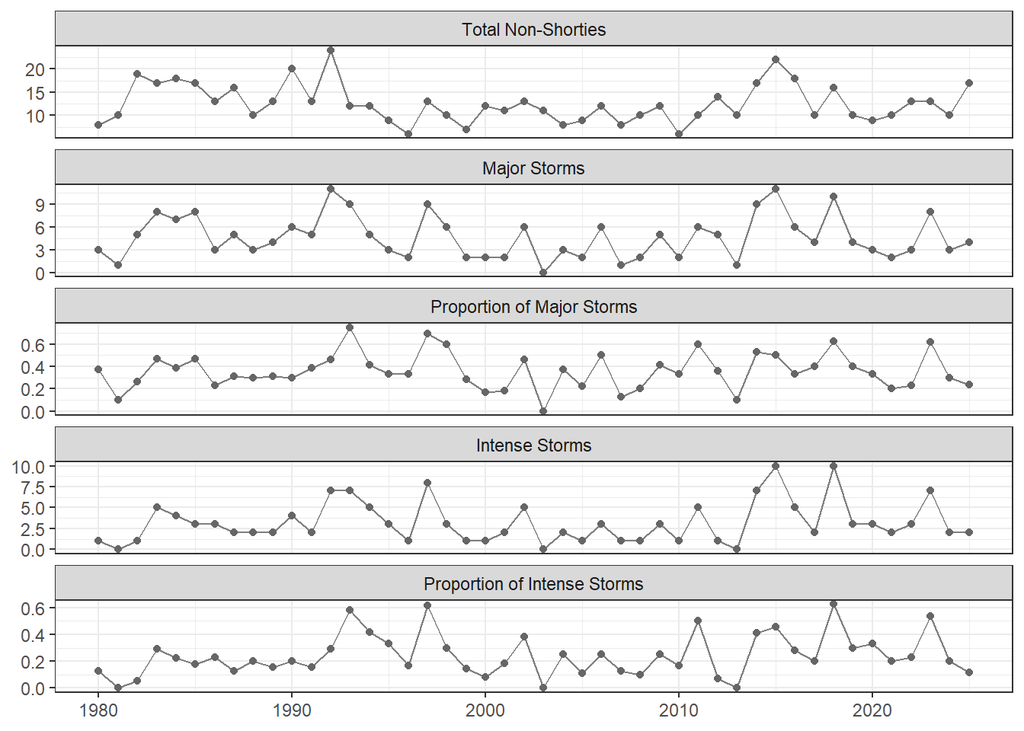

### Regression Methods

#### Poisson Regression on non-Shorties

```
Call:  glm(formula = Total_Storms ~ YearsSinceStart, family = poisson(link = "log"),
    data = storm_basin)

Coefficients:
    (Intercept)  YearsSinceStart
       2.606581        -0.003408

Degrees of Freedom: 45 Total (i.e. Null);  44 Residual
Null Deviance:      59.02
Residual Deviance: 57.84    AIC: 261.1
```

```
Single term deletions

Model:
Total_Storms ~ YearsSinceStart
                Df Deviance    AIC    LRT Pr(>Chi)
<none>               57.836 261.12
YearsSinceStart  1   59.018 260.30 1.1822   0.2769
```

Using this model, we would predict 13.552631 storms in 1980 and 11.6259315 storms in 2025.

That is a change of -0.4188477 storms per decade.

#### Poisson Regression on Major Storms

```
Call:  glm(formula = Major_Storms ~ YearsSinceStart, family = poisson(link = "log"),
    data = storm_basin)

Coefficients:
    (Intercept)  YearsSinceStart
       1.587652        -0.002045

Degrees of Freedom: 45 Total (i.e. Null);  44 Residual
Null Deviance:      79.06
Residual Deviance: 78.9     AIC: 230.1
```

```
Single term deletions

Model:
Major_Storms ~ YearsSinceStart
                Df Deviance    AIC     LRT Pr(>Chi)
<none>               78.897 230.07
YearsSinceStart  1   79.055 228.23 0.15851   0.6905
```

Using this model the number of a major storm in 1980 was 4.8922463 and 4.4620322 in 2025.

That is a change of -0.0935248 storms per decade.

#### Poisson Regression on Intense Storms

```
Call:  glm(formula = Intense_Storms ~ YearsSinceStart, family = poisson(link = "log"),
    data = storm_basin)

Coefficients:
    (Intercept)  YearsSinceStart
        0.94244          0.00912

Degrees of Freedom: 45 Total (i.e. Null);  44 Residual
Null Deviance:      86.8
Residual Deviance: 84.67    AIC: 213.1
```

```
Single term deletions

Model:
Intense_Storms ~ YearsSinceStart
                Df Deviance    AIC   LRT Pr(>Chi)
<none>               84.668 213.15
YearsSinceStart  1   86.799 213.28 2.131   0.1443
```

Using this model the number of a intense storm in 1980 was 2.5662381 and 3.8684374 in 2025.

That is a change of 0.2830868 storms per decade.

#### Logistic Regression on Proportions of Major

```
Call:  glm(formula = cbind(Major_Storms, Non_Major) ~ YearsSinceStart,
    family = binomial, data = prop_data)

Coefficients:
    (Intercept)  YearsSinceStart
      -0.568135         0.002022

Degrees of Freedom: 45 Total (i.e. Null);  44 Residual
Null Deviance:      66.33
Residual Deviance: 66.22    AIC: 195.7
```

```
Single term deletions

Model:
cbind(Major_Storms, Non_Major) ~ YearsSinceStart
                Df Deviance    AIC     LRT Pr(>Chi)
<none>               66.224 195.71
YearsSinceStart  1   66.328 193.81 0.10426   0.7468
```

Using this model the probability of a major storm in 1980 was 0.3616672 and 0.3829219 in 2025.

That is a change of 0.4620579 percent per decade.

#### Logistic Regression on Proportions of Intense

```
Call:  glm(formula = cbind(Intense_Storms, Non_Intense) ~ YearsSinceStart,
    family = binomial, data = prop_data)

Coefficients:
    (Intercept)  YearsSinceStart
       -1.43903          0.01565

Degrees of Freedom: 45 Total (i.e. Null);  44 Residual
Null Deviance:      82.08
Residual Deviance: 77.06    AIC: 191.8
```

```
Single term deletions

Model:
cbind(Intense_Storms, Non_Intense) ~ YearsSinceStart
                Df Deviance    AIC    LRT Pr(>Chi)
<none>               77.057 191.84
YearsSinceStart  1   82.081 194.86 5.0234  0.02501 *
---
Signif. codes:  0 '***' 0.001 '**' 0.01 '*' 0.05 '.' 0.1 ' ' 1
```

Using this model the probability of an intense storm in 1980 was 0.1916951 and 0.3241797 in 2025.

That is a change of 2.8800992 percent per decade.

### Changepoint Methods

#### Change in Non-Shorty Counts

```
  SCUSUM Stat chpt Location       p-value
   0.38694311   13.00000000    0.08554638
```

The dates suggest the changepoint would occur from 1992 to 1993 with $p$-value 0.0855464.

In regime one, the mean number of total storms is 15.2307692 and in regime two, the mean number of storms is 11.5151515; a change of -3.7156177.

#### Change in counts of major storms

```
  SCUSUM Stat chpt Location       p-value
    0.1916615    19.0000000     0.3186228
```

The dates suggest the changepoint would occur from 1998 to 1999 with $p$-value 0.3186228.

In regime one, the mean number of major storms is 5.4210526 and in regime two, the mean number of storms is 4.1481481; a change of -1.2729045.

#### Change in counts of intense storms

```
  SCUSUM Stat chpt Location       p-value
    0.3531087    34.0000000     0.1058238
```

The dates suggest the changepoint would occur from 2013 to 2014 with $p$-value 0.1058238.

In regime one, the mean number of intense storms is 2.6470588 and in regime two, the mean number of storms is 4.6666667; a change of 2.0196078.

#### Proportion of major storms

A change in the proportion of major storms?

```
  SCUSUM Stat chpt Location       p-value
   0.07850174   19.00000000    0.67533633
```

The change in proportions occurs 1998 to 1999 with $p$-value 0.6753363.

In regime one, the proportion of major storms is 0.3961538 and in regime two, the proportion of major storms is 0.3522013; a change of -0.0439526.

#### Proportion of intense storms

A change in the proportion of major storms?

```
  SCUSUM Stat chpt Location       p-value
   0.39090801   34.00000000    0.08346233
```

The change in proportions occurs 2013 to 2014 with $p$-value 0.0834623.

In regime one, the proportion of intense storms is 0.2179177 and in regime two, the proportion of major storms is 0.3393939; a change of 0.1214763.

## IBTracs Test Results

**Generalized Linear Model Approaches**

Note:

- we report the Likelihood Ratio Test for the generalized linear models, this is better to use than the default $Z$-test provided in the `summary()` output.
- the Change per decade is found by comparing the predicted value at the start time (1980) and end time (2025) and scaling by the number of years $\times 10$.

| Response | Coefficent | p.value | Start | End | Change per Decade |
| --- | --- | --- | --- | --- | --- |
| Cyclone Freq | -0.00341 | 0.27691 | 13.55263 | 11.62593 | -0.41885 |
| Major Freq | -0.00205 | 0.69053 | 4.89225 | 4.46203 | -0.09352 |
| Prop Major | 0.00202 | 0.74677 | 36.16672 | 38.29219 | 0.46206 |
| Intense Freq | 0.00912 | 0.14435 | 2.56624 | 3.86844 | 0.28309 |
| Prop Freq | 0.01565 | 0.02501 | 19.16951 | 32.41797 | 2.88010 |

**Changepoint Methods**

| Response | Chpt.Location | p.value | Regime1 | Regime2 | Change | Perc_Change |
| --- | --- | --- | --- | --- | --- | --- |
| Cyclone Freq | 1993 | 0.08555 | 15.23077 | 11.51515 | -3.71562 | -24.39547 |
| Major Freq | 1999 | 0.31862 | 5.42105 | 4.14815 | -1.27290 | -23.48076 |
| Prop Major | 1999 | 0.67534 | 39.61538 | 35.22013 | -4.39526 | -11.09483 |
| Intense Freq | 2014 | 0.10582 | 2.64706 | 4.66667 | 2.01961 | 76.29630 |
| Prop Freq | 2014 | 0.08346 | 21.79177 | 33.93939 | 12.14763 | 55.74411 |

## HURSAT Full Analysis

### Summary Statistics (overall)

| Total Storms (Avg) | Total Storms (stddev) | Major Storms (Avg) | Major Storms (stddev) | Prop Major Storms | Intense Storms (Avg) | Intense Storms (stddev) | Prop Intense Storms |
| --- | --- | --- | --- | --- | --- | --- | --- |
| 15.40541 | 4.699051 | 5.135135 | 2.485091 | 0.3333333 | 3.594595 | 2.350644 | 0.2333333 |

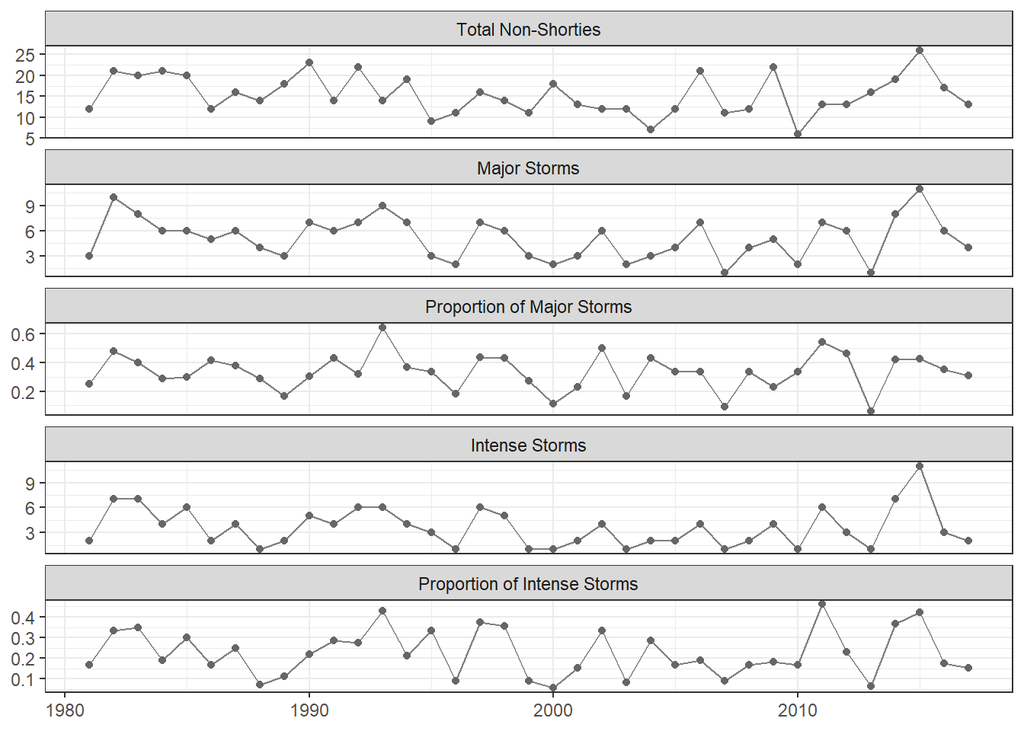

### Regression Methods

#### Poisson Regression on non-Shorties

```
Call:  glm(formula = Total_Storms ~ YearsSinceStart, family = poisson(link = "log"),
    data = storm_basin)

Coefficients:
    (Intercept)  YearsSinceStart
       2.816646        -0.004619

Degrees of Freedom: 36 Total (i.e. Null);  35 Residual
Null Deviance:      52.45
Residual Deviance: 51.06    AIC: 222.9
```

```
Single term deletions

Model:
Total_Storms ~ YearsSinceStart
                Df Deviance    AIC    LRT Pr(>Chi)
<none>               51.062 222.88
YearsSinceStart  1   52.447 222.27 1.3854   0.2392
```

Using this model, we would predict 16.7206684 storms in 1981 and 14.15913 storms in 2017.

That is a change of -0.6923077 storms per decade.

#### Poisson Regression on Major Storms

```
Call:  glm(formula = Major_Storms ~ YearsSinceStart, family = poisson(link = "log"),
    data = storm_basin)

Coefficients:
    (Intercept)  YearsSinceStart
        1.75018         -0.00647

Degrees of Freedom: 36 Total (i.e. Null);  35 Residual
Null Deviance:      45.83
Residual Deviance: 44.93    AIC: 173.8
```

```
Single term deletions

Model:
Major_Storms ~ YearsSinceStart
                Df Deviance    AIC     LRT Pr(>Chi)
<none>               44.928 173.80
YearsSinceStart  1   45.833 172.71 0.90533   0.3414
```

Using this model the number of a major storm in 1981 was 5.7556161 and 4.5597455 in 2017.

That is a change of -0.3232083 storms per decade.

#### Poisson Regression on Intense Storms

```
Call:  glm(formula = Intense_Storms ~ YearsSinceStart, family = poisson(link = "log"),
    data = storm_basin)

Coefficients:
    (Intercept)  YearsSinceStart
       1.375176        -0.005412

Degrees of Freedom: 36 Total (i.e. Null);  35 Residual
Null Deviance:      53.44
Residual Deviance: 52.99    AIC: 166.7
```

```
Single term deletions

Model:
Intense_Storms ~ YearsSinceStart
                Df Deviance    AIC     LRT Pr(>Chi)
<none>               52.992 166.66
YearsSinceStart  1   53.436 165.10 0.44363   0.5054
```

Using this model the number of a intense storms in 1981 was 3.9557731 and 3.2555089 in 2017.

That is a change of -0.1892606 storms per decade.

#### Logistic Regression on Proportions of Major

```
Call:  glm(formula = cbind(Major_Storms, Non_Major) ~ YearsSinceStart,
    family = binomial, data = prop_data)

Coefficients:
    (Intercept)  YearsSinceStart
      -0.648575        -0.002559

Degrees of Freedom: 36 Total (i.e. Null);  35 Residual
Null Deviance:      40.54
Residual Deviance: 40.44    AIC: 153.9
```

```
Single term deletions

Model:
cbind(Major_Storms, Non_Major) ~ YearsSinceStart
                Df Deviance    AIC     LRT Pr(>Chi)
<none>               40.435 153.89
YearsSinceStart  1   40.537 151.99 0.10232   0.7491
```

Using this model the probability of a major storm in 1981 was 0.3433108 and 0.3228549 in 2017.

That is a change of -0.5528629 percent per decade.

#### Logistic Regression on Proportions of Intense

```
Call:  glm(formula = cbind(Intense_Storms, Non_Intense) ~ YearsSinceStart,
    family = binomial, data = prop_data)

Coefficients:
    (Intercept)  YearsSinceStart
     -1.1729579       -0.0009532

Degrees of Freedom: 36 Total (i.e. Null);  35 Residual
Null Deviance:      41.47
Residual Deviance: 41.46    AIC: 145.4
```

```
Single term deletions

Model:
cbind(Intense_Storms, Non_Intense) ~ YearsSinceStart
                Df Deviance    AIC      LRT Pr(>Chi)
<none>               41.459 145.39
YearsSinceStart  1   41.470 143.40 0.011437   0.9148
```

Using this model the probability of an intense storm in 1981 was 0.2363207 and 0.2301838 in 2017.

That is a change of -0.165862 percent per decade.

### Changepoint Methods

#### Change in Non-Shorty Counts

```
  SCUSUM Stat chpt Location       p-value
   0.38189740   14.00000000    0.08828067
```

The dates suggest the changepoint would occur from 1994 to 1995 with $p$-value 0.0882807.

In regime one, the mean number of total storms is 17.5714286 and in regime two, the mean number of storms is 14.0869565; a change of -3.484472.

#### Change in counts of major storms

```
  SCUSUM Stat chpt Location       p-value
    0.2775057    14.0000000     0.1733528
```

The dates suggest the changepoint would occur from 1994 to 1995 with $p$-value 0.1733528.

In regime one, the mean number of major storms is 6.2142857 and in regime two, the mean number of storms is 4.4782609; a change of -1.7360248.

#### Change in counts of intense storms

```
  SCUSUM Stat chpt Location       p-value
    0.2534862    18.0000000     0.2042054
```

The dates suggest the changepoint would occur from 1998 to 1999 with $p$-value 0.2042054.

In regime one, the mean number of intense storms is 4.1666667 and in regime two, the mean number of storms is 3.0526316; a change of -1.1140351.

#### Proportion of major storms

A change in the proportion of major storms?

```
  SCUSUM Stat chpt Location       p-value
   0.05402001   18.00000000    0.84222754
```

The change in proportions occurs 1998 to 1999 with $p$-value 0.8422275.

In regime one, the proportion of major storms is 0.3547297 and in regime two, the proportion of major storms is 0.310219; a change of -0.0445108.

#### Proportion of intense storms

A change in the proportion of major storms?

```
  SCUSUM Stat chpt Location       p-value
    0.0654641    18.0000000     0.7635663
```

The change in proportions occurs 1998 to 1999 with $p$-value 0.7635663.

In regime one, the proportion of intense storms is 0.2533784 and in regime two, the proportion of major storms is 0.2116788; a change of -0.0416995.

## HURSAT Test Results

**Generalized Linear Model Approaches**

Note:

- we report the Likelihood Ratio Test for the generalized linear models, this is better to use than the default $Z$-test provided in the `summary()` output.
- the Change per decade is found by comparing the predicted value at the start time (1981) and end time (2017) and scaling by the number of years $\times 10$.

| Response | Coefficent | p.value | Start | End | Change per Decade |
| --- | --- | --- | --- | --- | --- |
| Cyclone Freq | -0.00462 | 0.23919 | 16.72067 | 14.15913 | -0.69231 |
| Major Freq | -0.00647 | 0.34136 | 5.75562 | 4.55975 | -0.32321 |
| Prop Major | -0.00256 | 0.74906 | 34.33108 | 32.28549 | -0.55286 |
| Intense Freq | -0.00541 | 0.50538 | 3.95577 | 3.25551 | -0.18926 |
| Prop Freq | -0.00095 | 0.91483 | 23.63207 | 23.01838 | -0.16586 |

**Changepoint Methods**

| Response | Chpt.Location | p.value | Regime1 | Regime2 | Change | Perc_Change |
| --- | --- | --- | --- | --- | --- | --- |
| Cyclone Freq | 1995 | 0.08828 | 17.57143 | 14.08696 | -3.48447 | -19.83033 |
| Major Freq | 1995 | 0.17335 | 6.21429 | 4.47826 | -1.73602 | -27.93603 |
| Prop Major | 1999 | 0.84223 | 35.47297 | 31.02190 | -4.45108 | -12.54779 |
| Intense Freq | 1999 | 0.20421 | 4.16667 | 3.05263 | -1.11404 | -26.73684 |
| Prop Freq | 1999 | 0.76357 | 25.33784 | 21.16788 | -4.16995 | -16.45742 |

## Trimmed IBTRacs Full Analysis

### Summary Statistics (overall)

| Total Storms (Avg) | Total Storms (stddev) | Major Storms (Avg) | Major Storms (stddev) | Prop Major Storms | Intense Storms (Avg) | Intense Storms (stddev) | Prop Intense Storms |
| --- | --- | --- | --- | --- | --- | --- | --- |
| 12.75676 | 4.361482 | 4.72973 | 2.883369 | 0.3707627 | 3.054054 | 2.437507 | 0.2394068 |

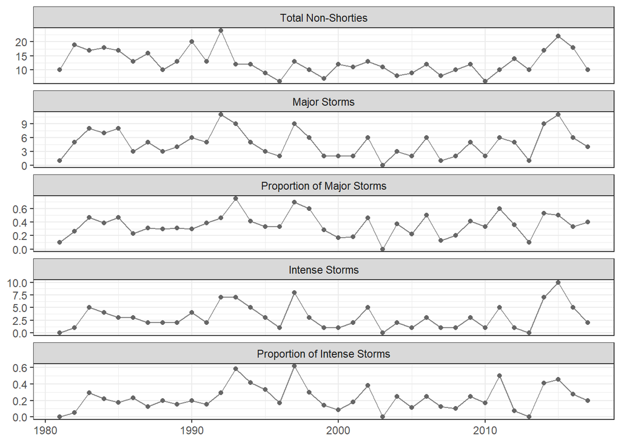

### Regression Methods

#### Poisson Regression on non-Shorties

```
Call:  glm(formula = Total_Storms ~ YearsSinceStart, family = poisson(link = "log"),
    data = storm_basin)

Coefficients:
    (Intercept)  YearsSinceStart
       2.673041        -0.007219

Degrees of Freedom: 36 Total (i.e. Null);  35 Residual
Null Deviance:      51.89
Residual Deviance: 49.09    AIC: 213.8
```

```
Single term deletions

Model:
Total_Storms ~ YearsSinceStart
                Df Deviance    AIC    LRT Pr(>Chi)
<none>               49.089 213.78
YearsSinceStart  1   51.888 214.58 2.7995   0.0943 .
---
Signif. codes:  0 '***' 0.001 '**' 0.01 '*' 0.05 '.' 0.1 ' ' 1
```

Using this model, we would predict 14.4839512 storms in 1981 and 11.169008 storms in 2017.

That is a change of -0.8959306 storms per decade.

#### Poisson Regression on Major Storms

```
Call:  glm(formula = Major_Storms ~ YearsSinceStart, family = poisson(link = "log"),
    data = storm_basin)

Coefficients:
    (Intercept)  YearsSinceStart
       1.629556        -0.004262

Degrees of Freedom: 36 Total (i.e. Null);  35 Residual
Null Deviance:      67.62
Residual Deviance: 67.25    AIC: 189.2
```

```
Single term deletions

Model:
Major_Storms ~ YearsSinceStart
                Df Deviance    AIC     LRT Pr(>Chi)
<none>               67.255 189.22
YearsSinceStart  1   67.617 187.59 0.36223   0.5473
```

Using this model the number of a major storm in 1981 was 5.1016103 and 4.3758866 in 2017.

That is a change of -0.1961415 storms per decade.

#### Poisson Regression on Intense Storms

```
Call:  glm(formula = Intense_Storms ~ YearsSinceStart, family = poisson(link = "log"),
    data = storm_basin)

Coefficients:
    (Intercept)  YearsSinceStart
       1.019803         0.005282

Degrees of Freedom: 36 Total (i.e. Null);  35 Residual
Null Deviance:      70.34
Residual Deviance: 69.98    AIC: 171.7
```

```
Single term deletions

Model:
Intense_Storms ~ YearsSinceStart
                Df Deviance    AIC     LRT Pr(>Chi)
<none>                69.98 171.68
YearsSinceStart  1    70.34 170.04 0.35906    0.549
```

Using this model the number of an intense storm in 1981 was 2.7726493 and 3.3533402 in 2017.

That is a change of 0.1569435 storms per decade.

#### Logistic Regression on Proportions of Major

```
Call:  glm(formula = cbind(Major_Storms, Non_Major) ~ YearsSinceStart,
    family = binomial, data = prop_data)

Coefficients:
    (Intercept)  YearsSinceStart
      -0.601231         0.004191

Degrees of Freedom: 36 Total (i.e. Null);  35 Residual
Null Deviance:      54.62
Residual Deviance: 54.38    AIC: 159
```

```
Single term deletions

Model:
cbind(Major_Storms, Non_Major) ~ YearsSinceStart
                Df Deviance    AIC     LRT Pr(>Chi)
<none>               54.378 159.00
YearsSinceStart  1   54.624 157.24 0.24672   0.6194
```

Using this model the probability of a major storm in 1981 was 0.3540622 and 0.3892782 in 2017.

That is a change of 0.9517844 percent per decade.

#### Logistic Regression on Proportions of Intense

```
Call:  glm(formula = cbind(Intense_Storms, Non_Intense) ~ YearsSinceStart,
    family = binomial, data = prop_data)

Coefficients:
    (Intercept)  YearsSinceStart
       -1.41470          0.01465

Degrees of Freedom: 36 Total (i.e. Null);  35 Residual
Null Deviance:      63.51
Residual Deviance: 61.16    AIC: 152.6
```

```
Single term deletions

Model:
cbind(Intense_Storms, Non_Intense) ~ YearsSinceStart
                Df Deviance    AIC    LRT Pr(>Chi)
<none>               61.156 152.57
YearsSinceStart  1   63.513 152.93 2.3574   0.1247
```

Using this model the probability of an intense storm in 1981 was 0.1954944 and 0.2916674 in 2017.

That is a change of 2.599272 percent per decade.

### Changepoint Methods

#### Change in Non-Shorty Counts

```
  SCUSUM Stat chpt Location       p-value
   0.69094415   12.00000000    0.01428176
```

The dates suggest the changepoint would occur from 1992 to 1993 with $p$-value 0.0142818.

In regime one, the mean number of total storms is 15.8333333 and in regime two, the mean number of storms is 11.28; a change of -4.5533333.

#### Change in counts of major storms

```
  SCUSUM Stat chpt Location       p-value
    0.3116394    18.0000000     0.1382251
```

The dates suggest the changepoint would occur from 1998 to 1999 with $p$-value 0.1382251.

In regime one, the mean number of major storms is 5.5555556 and in regime two, the mean number of storms is 3.9473684; a change of -1.6081871.

#### Change in counts of intense storms

```
  SCUSUM Stat chpt Location       p-value
    0.2122860    33.0000000     0.2734528
```

The dates suggest the changepoint would occur from 2013 to 2014 with $p$-value 0.2734528.

In regime one, the mean number of intense storms is 2.6969697 and in regime two, the mean number of storms is 6; a change of 3.3030303.

#### Proportion of major storms

A change in the proportion of major storms?

```
  SCUSUM Stat chpt Location       p-value
    0.1132624    18.0000000     0.6102719
```

The change in proportions occurs 1998 to 1999 with $p$-value 0.6102719.

In regime one, the proportion of major storms is 0.3968254 and in regime two, the proportion of major storms is 0.3409091; a change of -0.0559163.

#### Proportion of intense storms

A change in the proportion of major storms?

```
  SCUSUM Stat chpt Location       p-value
    0.1924071    11.0000000     0.3168370
```

The change in proportions occurs 1991 to 1992 with $p$-value 0.316837.

In regime one, the proportion of intense storms is 0.1686747 and in regime two, the proportion of major storms is 0.2777778; a change of 0.1091031.

## Trimmed IBTRacs Test Results

**Generalized Linear Model Approaches**

Note:

- we report the Likelihood Ratio Test for the generalized linear models, this is better to use than the default $Z$-test provided in the `summary()` output.
- the Change per decade is found by comparing the predicted value at the start time (1981) and end time (2017) and scaling by the number of years $\times 10$.

| Response | Coefficent | p.value | Start | End | Change per Decade |
| --- | --- | --- | --- | --- | --- |
| Cyclone Freq | -0.00722 | 0.09430 | 14.48395 | 11.16901 | -0.89593 |
| Major Freq | -0.00426 | 0.54727 | 5.10161 | 4.37589 | -0.19614 |
| Prop Major | 0.00419 | 0.61939 | 35.40622 | 38.92782 | 0.95178 |
| Intense Freq | 0.00528 | 0.54903 | 2.77265 | 3.35334 | 0.15694 |
| Prop Freq | 0.01465 | 0.12469 | 19.54944 | 29.16674 | 2.59927 |

**Changepoint Methods**

| Response | Chpt.Location | p.value | Regime1 | Regime2 | Change | Perc_Change |
| --- | --- | --- | --- | --- | --- | --- |
| Cyclone Freq | 1993 | 0.01428 | 15.83333 | 11.28000 | -4.55333 | -28.75789 |
| Major Freq | 1999 | 0.13823 | 5.55556 | 3.94737 | -1.60819 | -28.94737 |
| Prop Major | 1999 | 0.61027 | 39.68254 | 34.09091 | -5.59163 | -14.09091 |
| Intense Freq | 2014 | 0.27345 | 2.69697 | 6.00000 | 3.30303 | 122.47191 |
| Prop Freq | 1992 | 0.31684 | 16.86747 | 27.77778 | 10.91031 | 64.68254 |

# Western North Pacific

## IBTracs Full Analysis

### Summary Statistics (overall)

| Total Storms (Avg) | Total Storms (stddev) | Major Storms (Avg) | Major Storms (stddev) | Prop Major Storms | Intense Storms (Avg) | Intense Storms (stddev) | Prop Intense Storms |
| --- | --- | --- | --- | --- | --- | --- | --- |
| 21.93478 | 4.518614 | 8.782609 | 2.665942 | 0.4003964 | 6.804348 | 2.777845 | 0.3102081 |

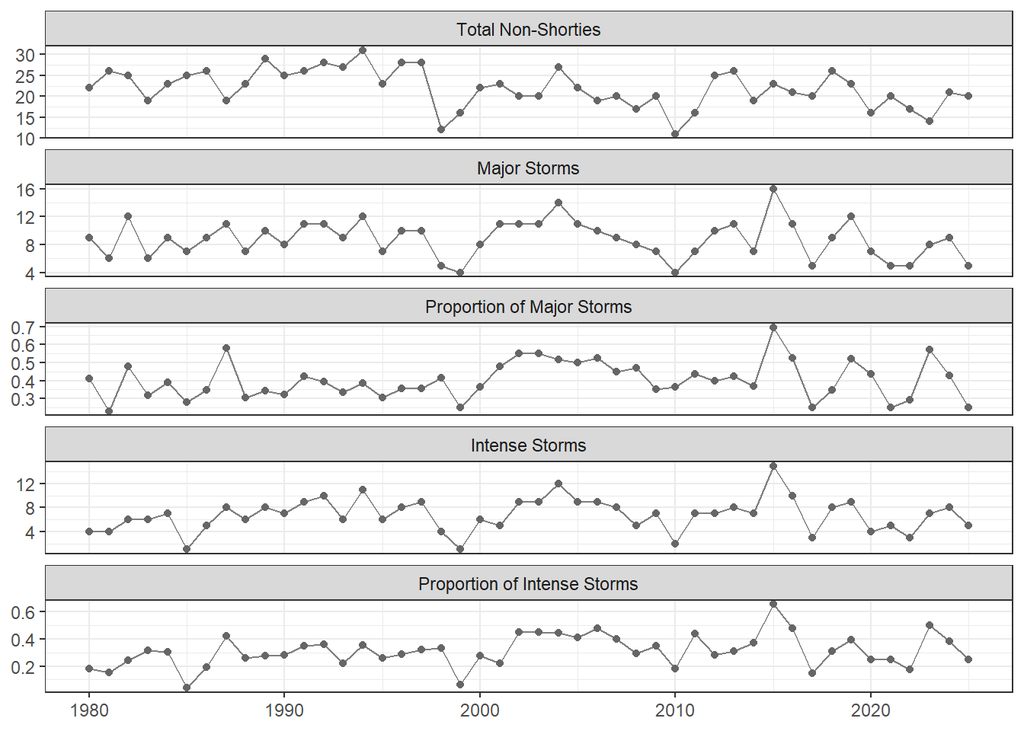

### Regression Methods

#### Poisson Regression on non-Shorties

```
Call:  glm(formula = Total_Storms ~ YearsSinceStart, family = poisson(link = "log"),
    data = storm_basin)

Coefficients:
    (Intercept)  YearsSinceStart
       3.229552        -0.006451

Degrees of Freedom: 45 Total (i.e. Null);  44 Residual
Null Deviance:      43.74
Residual Deviance: 36.36    AIC: 266.3
```

```
Single term deletions

Model:
Total_Storms ~ YearsSinceStart
                Df Deviance    AIC    LRT Pr(>Chi)
<none>               36.361 266.25
YearsSinceStart  1   43.745 271.64 7.3839 0.006581 **
---
Signif. codes:  0 '***' 0.001 '**' 0.01 '*' 0.05 '.' 0.1 ' ' 1
```

Using this model, we would predict 25.2683228 storms in 1980 and 18.9019839 storms in 2025.

That is a change of -1.3839867 storms per decade.

#### Poisson Regression on Major Storms

```
Call:  glm(formula = Major_Storms ~ YearsSinceStart, family = poisson(link = "log"),
    data = storm_basin)

Coefficients:
    (Intercept)  YearsSinceStart
       2.228791        -0.002514

Degrees of Freedom: 45 Total (i.e. Null);  44 Residual
Null Deviance:      37.26
Residual Deviance: 36.81    AIC: 224
```

```
Single term deletions

Model:
Major_Storms ~ YearsSinceStart
                Df Deviance    AIC     LRT Pr(>Chi)
<none>               36.809 224.00
YearsSinceStart  1   37.259 222.45 0.45003   0.5023
```

Using this model the number of a major storm in 1980 was 9.2886297 and 8.2949072 in 2025.

That is a change of -0.2160266 storms per decade.

#### Poisson Regression on Intense Storms

```
Call:  glm(formula = Intense_Storms ~ YearsSinceStart, family = poisson(link = "log"),
    data = storm_basin)

Coefficients:
    (Intercept)  YearsSinceStart
       1.846320         0.003128

Degrees of Freedom: 45 Total (i.e. Null);  44 Residual
Null Deviance:      55.59
Residual Deviance: 55.05    AIC: 228.1
```

```
Single term deletions

Model:
Intense_Storms ~ YearsSinceStart
                Df Deviance    AIC     LRT Pr(>Chi)
<none>               55.046 228.11
YearsSinceStart  1   55.586 226.65 0.53949   0.4626
```

Using this model the number of a intense storm in 1980 was 6.3364577 and 7.2941999 in 2025.

That is a change of 0.2082048 storms per decade.

#### Logistic Regression on Proportions of Major

```
Call:  glm(formula = cbind(Major_Storms, Non_Major) ~ YearsSinceStart,
    family = binomial, data = prop_data)

Coefficients:
    (Intercept)  YearsSinceStart
      -0.546288         0.006633

Degrees of Freedom: 45 Total (i.e. Null);  44 Residual
Null Deviance:      43.41
Residual Deviance: 41.55    AIC: 204.5
```

```
Single term deletions

Model:
cbind(Major_Storms, Non_Major) ~ YearsSinceStart
                Df Deviance    AIC    LRT Pr(>Chi)
<none>               41.554 204.53
YearsSinceStart  1   43.409 204.38 1.8546   0.1732
```

Using this model the probability of a major storm in 1980 was 0.3667261 and 0.4383674 in 2025.

That is a change of 1.5574184 percent per decade.

#### Logistic Regression on Proportions of Intense

```
Call:  glm(formula = cbind(Intense_Storms, Non_Intense) ~ YearsSinceStart,
    family = binomial, data = prop_data)

Coefficients:
    (Intercept)  YearsSinceStart
       -1.10599          0.01406

Degrees of Freedom: 45 Total (i.e. Null);  44 Residual
Null Deviance:      64.93
Residual Deviance: 57.52    AIC: 212.9
```

```
Single term deletions

Model:
cbind(Intense_Storms, Non_Intense) ~ YearsSinceStart
                Df Deviance    AIC    LRT Pr(>Chi)
<none>               57.516 212.88
YearsSinceStart  1   64.928 218.29 7.4122 0.006478 **
---
Signif. codes:  0 '***' 0.001 '**' 0.01 '*' 0.05 '.' 0.1 ' ' 1
```

Using this model the probability of an intense storm in 1980 was 0.2486183 and 0.383828 in 2025.

That is a change of 2.9393407 percent per decade.

### Changepoint Methods

#### Change in Non-Shorty Counts

```
  SCUSUM Stat chpt Location       p-value
  0.864418017  18.000000000   0.005424497
```

The dates suggest the changepoint would occur from 1997 to 1998 with $p$-value 0.0054245.

In regime one, the mean number of total storms is 25.1666667 and in regime two, the mean number of storms is 19.8571429; a change of -5.3095238.

#### Change in counts of major storms

```
  SCUSUM Stat chpt Location       p-value
    0.1074627    37.0000000     0.6447136
```

The dates suggest the changepoint would occur from 2016 to 2017 with $p$-value 0.6447136.

In regime one, the mean number of major storms is 9.1621622 and in regime two, the mean number of storms is 7.2222222; a change of -1.9399399.

#### Change in counts of intense storms

```
  SCUSUM Stat chpt Location       p-value
    0.1773835     7.0000000     0.3553758
```

The dates suggest the changepoint would occur from 1986 to 1987 with $p$-value 0.3553758.

In regime one, the mean number of intense storms is 4.7142857 and in regime two, the mean number of storms is 7.1794872; a change of 2.4652015.

#### Proportion of major storms

A change in the proportion of major storms?

```
  SCUSUM Stat chpt Location       p-value
     0.280296     21.000000      0.170129
```

The change in proportions occurs 2000 to 2001 with $p$-value 0.170129.

In regime one, the proportion of major storms is 0.359841 and in regime two, the proportion of major storms is 0.4407115; a change of 0.0808705.

#### Proportion of intense storms

A change in the proportion of major storms?

```
  SCUSUM Stat chpt Location       p-value
   0.73638334   22.00000000    0.01105523
```

The change in proportions occurs 2001 to 2002 with $p$-value 0.0110552.

In regime one, the proportion of intense storms is 0.2604563 and in regime two, the proportion of major storms is 0.3643892; a change of 0.103933.

## IBTracs Test Results

**Generalized Linear Model Approaches**

Note:

- we report the Likelihood Ratio Test for the generalized linear models, this is better to use than the default $Z$-test provided in the `summary()` output.
- the Change per decade is found by comparing the predicted value at the start time (1980) and end time (2025) and scaling by the number of years $\times 10$.

| Response | Coefficent | p.value | Start | End | Change per Decade |
| --- | --- | --- | --- | --- | --- |
| Cyclone Freq | -0.00645 | 0.00658 | 25.26832 | 18.90198 | -1.38399 |
| Major Freq | -0.00251 | 0.50232 | 9.28863 | 8.29491 | -0.21603 |
| Prop Major | 0.00663 | 0.17325 | 36.67261 | 43.83674 | 1.55742 |
| Intense Freq | 0.00313 | 0.46265 | 6.33646 | 7.29420 | 0.20820 |
| Prop Freq | 0.01406 | 0.00648 | 24.86183 | 38.38280 | 2.93934 |

**Changepoint Methods**

| Response | Chpt.Location | p.value | Regime1 | Regime2 | Change | Perc_Change |
| --- | --- | --- | --- | --- | --- | --- |
| Cyclone Freq | 1998 | 0.00542 | 25.16667 | 19.85714 | -5.30952 | -21.09745 |
| Major Freq | 2017 | 0.64471 | 9.16216 | 7.22222 | -1.93994 | -21.17339 |
| Prop Major | 2001 | 0.17013 | 35.98410 | 44.07115 | 8.08705 | 22.47396 |
| Intense Freq | 1987 | 0.35538 | 4.71429 | 7.17949 | 2.46520 | 52.29215 |
| Prop Freq | 2002 | 0.01106 | 26.04563 | 36.43892 | 10.39330 | 39.90419 |

## HURSAT Full Analysis

### Summary Statistics (overall)

| Total Storms (Avg) | Total Storms (stddev) | Major Storms (Avg) | Major Storms (stddev) | Prop Major Storms | Intense Storms (Avg) | Intense Storms (stddev) | Prop Intense Storms |
| --- | --- | --- | --- | --- | --- | --- | --- |
| 28.56757 | 4.752429 | 9.513514 | 3.123581 | 0.333018 | 6.72973 | 3.09703 | 0.2355724 |

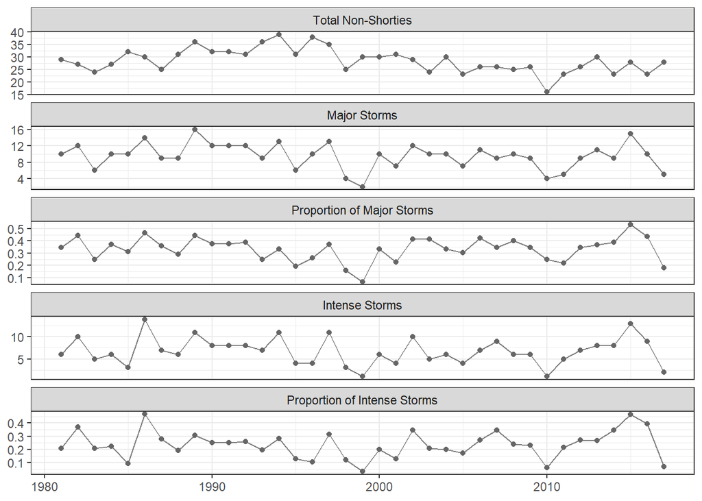

### Regression Methods

#### Poisson Regression on non-Shorties

```
Call:  glm(formula = Total_Storms ~ YearsSinceStart, family = poisson(link = "log"),
    data = storm_basin)

Coefficients:
    (Intercept)  YearsSinceStart
       3.466221        -0.006463

Degrees of Freedom: 36 Total (i.e. Null);  35 Residual
Null Deviance:      28.85
Residual Deviance: 23.82    AIC: 219.6
```

```
Single term deletions

Model:
Total_Storms ~ YearsSinceStart
                Df Deviance    AIC    LRT Pr(>Chi)
<none>               23.822 219.56
YearsSinceStart  1   28.848 222.58 5.0256  0.02498 *
---
Signif. codes:  0 '***' 0.001 '**' 0.01 '*' 0.05 '.' 0.1 ' ' 1
```

Using this model, we would predict 32.0155271 storms in 1981 and 25.3699154 storms in 2017.

That is a change of -1.7961113 storms per decade.

#### Poisson Regression on Major Storms

```
Call:  glm(formula = Major_Storms ~ YearsSinceStart, family = poisson(link = "log"),
    data = storm_basin)

Coefficients:
    (Intercept)  YearsSinceStart
        2.37524         -0.00696

Degrees of Freedom: 36 Total (i.e. Null);  35 Residual
Null Deviance:      40.97
Residual Deviance: 39.03    AIC: 192.5
```

```
Single term deletions

Model:
Major_Storms ~ YearsSinceStart
                Df Deviance    AIC    LRT Pr(>Chi)
<none>               39.026 192.53
YearsSinceStart  1   40.967 192.48 1.9409   0.1636
```

Using this model the number of a major storm in 1981 was 10.7536063 and 8.3700961 in 2017.

That is a change of -0.6441919 storms per decade.

#### Poisson Regression on Intense Storms

```
Call:  glm(formula = Intense_Storms ~ YearsSinceStart, family = poisson(link = "log"),
    data = storm_basin)

Coefficients:
    (Intercept)  YearsSinceStart
       1.987813        -0.004582

Degrees of Freedom: 36 Total (i.e. Null);  35 Residual
Null Deviance:      55.03
Residual Deviance: 54.43    AIC: 193.1
```

```
Single term deletions

Model:
Intense_Storms ~ YearsSinceStart
                Df Deviance    AIC     LRT Pr(>Chi)
<none>               54.432 193.13
YearsSinceStart  1   55.027 191.73 0.59551   0.4403
```

Using this model the number of a intense storms in 1981 was 7.2995531 and 6.1895606 in 2017.

That is a change of -0.299998 storms per decade.

#### Logistic Regression on Proportions of Major

```
Call:  glm(formula = cbind(Major_Storms, Non_Major) ~ YearsSinceStart,
    family = binomial, data = prop_data)

Coefficients:
    (Intercept)  YearsSinceStart
     -0.6810104       -0.0007859

Degrees of Freedom: 36 Total (i.e. Null);  35 Residual
Null Deviance:      45.93
Residual Deviance: 45.91    AIC: 184.2
```

```
Single term deletions

Model:
cbind(Major_Storms, Non_Major) ~ YearsSinceStart
                Df Deviance    AIC      LRT Pr(>Chi)
<none>               45.914 184.19
YearsSinceStart  1   45.929 182.20 0.015647   0.9005
```

Using this model the probability of a major storm in 1981 was 0.3360358 and 0.3297531 in 2017.

That is a change of -0.1698033 percent per decade.

#### Logistic Regression on Proportions of Intense

```
Call:  glm(formula = cbind(Intense_Storms, Non_Intense) ~ YearsSinceStart,
    family = binomial, data = prop_data)

Coefficients:
    (Intercept)  YearsSinceStart
      -1.222026         0.002591

Degrees of Freedom: 36 Total (i.e. Null);  35 Residual
Null Deviance:      63.81
Residual Deviance: 63.67    AIC: 192.2
```

```
Single term deletions

Model:
cbind(Intense_Storms, Non_Intense) ~ YearsSinceStart
                Df Deviance    AIC     LRT Pr(>Chi)
<none>               63.673 192.16
YearsSinceStart  1   63.811 190.30 0.13806   0.7102
```

Using this model the probability of an intense storm in 1981 was 0.2275801 and 0.2443897 in 2017.

That is a change of 0.454313 percent per decade.

### Changepoint Methods

#### Change in Non-Shorty Counts

```
  SCUSUM Stat chpt Location       p-value
  0.811132849  22.000000000   0.007284066
```

The dates suggest the changepoint would occur from 2002 to 2003 with $p$-value 0.0072841.

In regime one, the mean number of total storms is 30.9090909 and in regime two, the mean number of storms is 25.1333333; a change of -5.7757576.

#### Change in counts of major storms

```
  SCUSUM Stat chpt Location       p-value
    0.2894386    17.0000000     0.1600348
```

The dates suggest the changepoint would occur from 1997 to 1998 with $p$-value 0.1600348.

In regime one, the mean number of major storms is 10.7647059 and in regime two, the mean number of storms is 8.45; a change of -2.3147059.

#### Change in counts of intense storms

```
  SCUSUM Stat chpt Location       p-value
    0.1824332    14.0000000     0.3417986
```

The dates suggest the changepoint would occur from 1994 to 1995 with $p$-value 0.3417986.

In regime one, the mean number of intense storms is 7.8571429 and in regime two, the mean number of storms is 6.0434783; a change of -1.8136646.

#### Proportion of major storms

A change in the proportion of major storms?

```
  SCUSUM Stat chpt Location       p-value
    0.1603657    12.0000000     0.4064999
```

The change in proportions occurs 1992 to 1993 with $p$-value 0.4064999.

In regime one, the proportion of major storms is 0.3707865 and in regime two, the proportion of major storms is 0.3138374; a change of -0.0569491.

#### Proportion of intense storms

A change in the proportion of major storms?

```
  SCUSUM Stat chpt Location       p-value
    0.2145102    31.0000000     0.2690618
```

The change in proportions occurs 2011 to 2012 with $p$-value 0.2690618.

In regime one, the proportion of intense storms is 0.2246941 and in regime two, the proportion of major storms is 0.2974684; a change of 0.0727742.

## HURSAT Test Results

**Generalized Linear Model Approaches**

Note:

- we report the Likelihood Ratio Test for the generalized linear models, this is better to use than the default $Z$-test provided in the `summary()` output.
- the Change per decade is found by comparing the predicted value at the start time (1981) and end time (2017) and scaling by the number of years $\times 10$.

| Response | Coefficent | p.value | Start | End | Change per Decade |
| --- | --- | --- | --- | --- | --- |
| Cyclone Freq | -0.00646 | 0.02498 | 32.01553 | 25.36992 | -1.79611 |
| Major Freq | -0.00696 | 0.16357 | 10.75361 | 8.37010 | -0.64419 |
| Prop Major | -0.00079 | 0.90045 | 33.60358 | 32.97531 | -0.16980 |
| Intense Freq | -0.00458 | 0.44030 | 7.29955 | 6.18956 | -0.30000 |
| Prop Freq | 0.00259 | 0.71022 | 22.75801 | 24.43897 | 0.45431 |

**Changepoint Methods**

| Response | Chpt.Location | p.value | Regime1 | Regime2 | Change | Perc_Change |
| --- | --- | --- | --- | --- | --- | --- |
| Cyclone Freq | 2003 | 0.00728 | 30.90909 | 25.13333 | -5.77576 | -18.68627 |
| Major Freq | 1998 | 0.16003 | 10.76471 | 8.45000 | -2.31471 | -21.50273 |
| Prop Major | 1993 | 0.40650 | 37.07865 | 31.38374 | -5.69491 | -15.35901 |
| Intense Freq | 1995 | 0.34180 | 7.85714 | 6.04348 | -1.81366 | -23.08300 |
| Prop Freq | 2012 | 0.26906 | 22.46941 | 29.74684 | 7.27742 | 32.38814 |

## Trimmed IBTRacs Full Analysis

### Summary Statistics (overall)

| Total Storms (Avg) | Total Storms (stddev) | Major Storms (Avg) | Major Storms (stddev) | Prop Major Storms | Intense Storms (Avg) | Intense Storms (stddev) | Prop Intense Storms |
| --- | --- | --- | --- | --- | --- | --- | --- |
| 22.43243 | 4.59795 | 9.054054 | 2.68686 | 0.4036145 | 7.027027 | 2.891429 | 0.313253 |

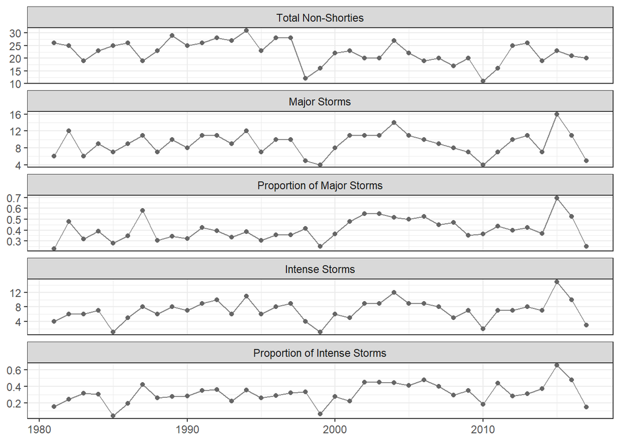

### Regression Methods

#### Poisson Regression on non-Shorties

```
Call:  glm(formula = Total_Storms ~ YearsSinceStart, family = poisson(link = "log"),
    data = storm_basin)

Coefficients:
    (Intercept)  YearsSinceStart
       3.240349        -0.007386

Degrees of Freedom: 36 Total (i.e. Null);  35 Residual
Null Deviance:      35.9
Residual Deviance: 30.75    AIC: 217.3
```

```
Single term deletions

Model:
Total_Storms ~ YearsSinceStart
                Df Deviance    AIC    LRT Pr(>Chi)
<none>               30.748 217.26
YearsSinceStart  1   35.900 220.41 5.1523  0.02322 *
---
Signif. codes:  0 '***' 0.001 '**' 0.01 '*' 0.05 '.' 0.1 ' ' 1
```

Using this model, we would predict 25.5426405 storms in 1981 and 19.5788729 storms in 2017.

That is a change of -1.6118291 storms per decade.

#### Poisson Regression on Major Storms

```
Call:  glm(formula = Major_Storms ~ YearsSinceStart, family = poisson(link = "log"),
    data = storm_basin)

Coefficients:
    (Intercept)  YearsSinceStart
        2.16716          0.00199

Degrees of Freedom: 36 Total (i.e. Null);  35 Residual
Null Deviance:      29.62
Residual Deviance: 29.47    AIC: 182
```

```
Single term deletions

Model:
Major_Storms ~ YearsSinceStart
                Df Deviance    AIC     LRT Pr(>Chi)
<none>               29.471 181.98
YearsSinceStart  1   29.623 180.13 0.15125   0.6973
```

Using this model the number of a major storm in 1981 was 8.7334695 and 9.3821691 in 2017.

That is a change of 0.1753242 storms per decade.

#### Poisson Regression on Intense Storms

```
Call:  glm(formula = Intense_Storms ~ YearsSinceStart, family = poisson(link = "log"),
    data = storm_basin)

Coefficients:
    (Intercept)  YearsSinceStart
       1.792987         0.008482

Degrees of Freedom: 36 Total (i.e. Null);  35 Residual
Null Deviance:      47.81
Residual Deviance: 45.68    AIC: 186.5
```

```
Single term deletions

Model:
Intense_Storms ~ YearsSinceStart
                Df Deviance    AIC    LRT Pr(>Chi)
<none>               45.679 186.52
YearsSinceStart  1   47.806 186.65 2.1273   0.1447
```

Using this model the number of an intense storm in 1981 was 6.0073678 and 8.1526698 in 2017.

That is a change of 0.5798113 storms per decade.

#### Logistic Regression on Proportions of Major

```
Call:  glm(formula = cbind(Major_Storms, Non_Major) ~ YearsSinceStart,
    family = binomial, data = prop_data)

Coefficients:
    (Intercept)  YearsSinceStart
       -0.66583          0.01589

Degrees of Freedom: 36 Total (i.e. Null);  35 Residual
Null Deviance:      35
Residual Deviance: 29.33    AIC: 162.1
```

```
Single term deletions

Model:
cbind(Major_Storms, Non_Major) ~ YearsSinceStart
                Df Deviance    AIC    LRT Pr(>Chi)
<none>               29.325 162.15
YearsSinceStart  1   35.002 165.83 5.6772  0.01719 *
---
Signif. codes:  0 '***' 0.001 '**' 0.01 '*' 0.05 '.' 0.1 ' ' 1
```

Using this model the probability of a major storm in 1981 was 0.3394313 and 0.4765968 in 2017.

That is a change of 3.7071766 percent per decade.

#### Logistic Regression on Proportions of Intense

```
Call:  glm(formula = cbind(Intense_Storms, Non_Intense) ~ YearsSinceStart,
    family = binomial, data = prop_data)

Coefficients:
    (Intercept)  YearsSinceStart
       -1.19738          0.02337

Degrees of Freedom: 36 Total (i.e. Null);  35 Residual
Null Deviance:      57.13
Residual Deviance: 46.18    AIC: 172.6
```

```
Single term deletions

Model:
cbind(Intense_Storms, Non_Intense) ~ YearsSinceStart
                Df Deviance    AIC    LRT  Pr(>Chi)
<none>               46.178 172.57
YearsSinceStart  1   57.126 181.52 10.948 0.0009373 ***
---
Signif. codes:  0 '***' 0.001 '**' 0.01 '*' 0.05 '.' 0.1 ' ' 1
```

Using this model the probability of an intense storm in 1981 was 0.231942 and 0.4119381 in 2017.

That is a change of 4.8647603 percent per decade.

### Changepoint Methods

#### Change in Non-Shorty Counts

```
  SCUSUM Stat chpt Location       p-value
   0.67928397   17.00000000    0.01525693
```

The dates suggest the changepoint would occur from 1997 to 1998 with $p$-value 0.0152569.

In regime one, the mean number of total storms is 25.3529412 and in regime two, the mean number of storms is 19.95; a change of -5.4029412.

#### Change in counts of major storms

```
  SCUSUM Stat chpt Location       p-value
    0.0512674    20.0000000     0.8606603
```

The dates suggest the changepoint would occur from 2000 to 2001 with $p$-value 0.8606603.

In regime one, the mean number of major storms is 8.6 and in regime two, the mean number of storms is 9.5882353; a change of 0.9882353.

#### Change in counts of intense storms

```
  SCUSUM Stat chpt Location       p-value
    0.2564168    21.0000000     0.2001199
```

The dates suggest the changepoint would occur from 2001 to 2002 with $p$-value 0.2001199.

In regime one, the mean number of intense storms is 6.3333333 and in regime two, the mean number of storms is 7.9375; a change of 1.6041667.

#### Proportion of major storms

A change in the proportion of major storms?

```
  SCUSUM Stat chpt Location       p-value
   0.53588284   20.00000000    0.03485692
```

The change in proportions occurs 2000 to 2001 with $p$-value 0.0348569.

In regime one, the proportion of major storms is 0.3575884 and in regime two, the proportion of major storms is 0.4670487; a change of 0.1094604.

#### Proportion of intense storms

A change in the proportion of major storms?

```
  SCUSUM Stat chpt Location       p-value
  0.929782409  21.000000000   0.003788301
```

The change in proportions occurs 2001 to 2002 with $p$-value 0.0037883.

In regime one, the proportion of intense storms is 0.2638889 and in regime two, the proportion of major storms is 0.3895706; a change of 0.1256817.

## Trimmed IBTRacs Test Results

**Generalized Linear Model Approaches**

Note:

- we report the Likelihood Ratio Test for the generalized linear models, this is better to use than the default $Z$-test provided in the `summary()` output.
- the Change per decade is found by comparing the predicted value at the start time (1981) and end time (2017) and scaling by the number of years $\times 10$.

| Response | Coefficent | p.value | Start | End | Change per Decade |
| --- | --- | --- | --- | --- | --- |
| Cyclone Freq | -0.00739 | 0.02322 | 25.54264 | 19.57887 | -1.61183 |
| Major Freq | 0.00199 | 0.69734 | 8.73347 | 9.38217 | 0.17532 |
| Prop Major | 0.01589 | 0.01719 | 33.94313 | 47.65968 | 3.70718 |
| Intense Freq | 0.00848 | 0.14470 | 6.00737 | 8.15267 | 0.57981 |
| Prop Freq | 0.02337 | 0.00094 | 23.19420 | 41.19381 | 4.86476 |

**Changepoint Methods**

| Response | Chpt.Location | p.value | Regime1 | Regime2 | Change | Perc_Change |
| --- | --- | --- | --- | --- | --- | --- |
| Cyclone Freq | 1998 | 0.01526 | 25.35294 | 19.95000 | -5.40294 | -21.31090 |
| Major Freq | 2001 | 0.86066 | 8.60000 | 9.58824 | 0.98824 | 11.49111 |
| Prop Major | 2001 | 0.03486 | 35.75884 | 46.70487 | 10.94604 | 30.61071 |
| Intense Freq | 2002 | 0.20012 | 6.33333 | 7.93750 | 1.60417 | 25.32895 |
| Prop Freq | 2002 | 0.00379 | 26.38889 | 38.95706 | 12.56817 | 47.62674 |

# North Indian

## IBTracs Full Analysis

### Summary Statistics (overall)

| Total Storms (Avg) | Total Storms (stddev) | Major Storms (Avg) | Major Storms (stddev) | Prop Major Storms | Intense Storms (Avg) | Intense Storms (stddev) | Prop Intense Storms |
| --- | --- | --- | --- | --- | --- | --- | --- |
| 2.934783 | 1.569178 | 0.8913043 | 0.9713281 | 0.3037037 | 0.6086957 | 0.7142443 | 0.2074074 |

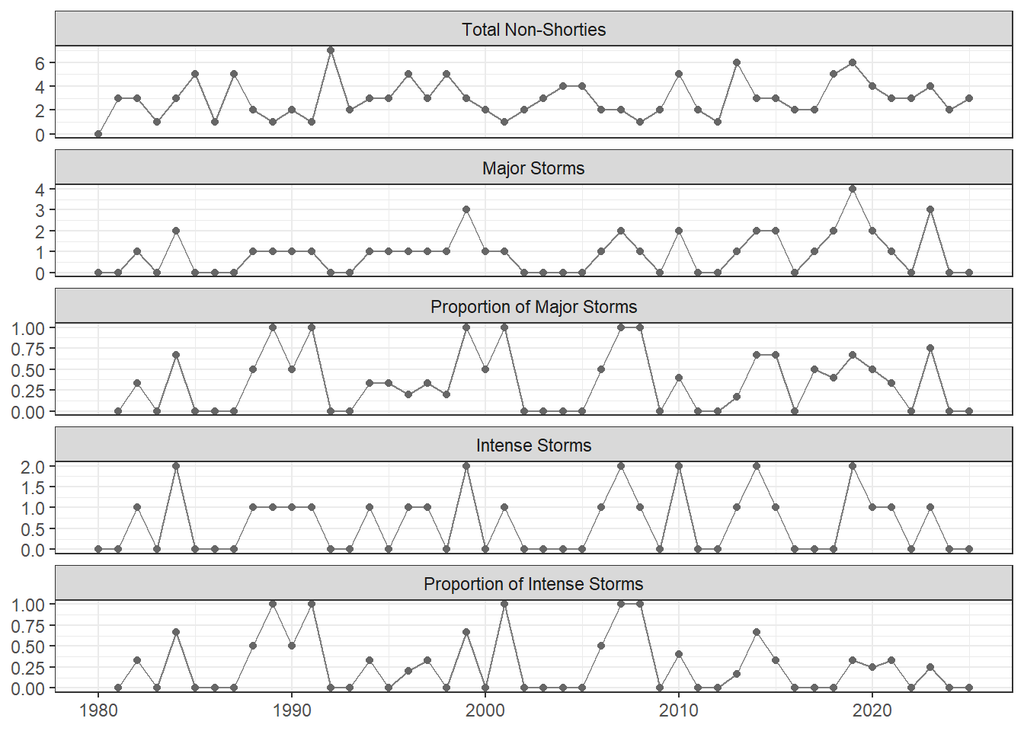

### Regression Methods

#### Poisson Regression on non-Shorties

```
Call:  glm(formula = Total_Storms ~ YearsSinceStart, family = poisson(link = "log"),
    data = storm_basin)

Coefficients:
    (Intercept)  YearsSinceStart
       0.912581         0.007094

Degrees of Freedom: 45 Total (i.e. Null);  44 Residual
Null Deviance:      39.44
Residual Deviance: 38.25    AIC: 171.6
```

```
Single term deletions

Model:
Total_Storms ~ YearsSinceStart
                Df Deviance    AIC    LRT Pr(>Chi)
<none>               38.250 171.58
YearsSinceStart  1   39.444 170.77 1.1943   0.2745
```

Using this model, we would predict 2.4907437 storms in 1980 and 3.4274718 storms in 2025.

That is a change of 0.2036366 storms per decade.

#### Poisson Regression on Major Storms

```
Call:  glm(formula = Major_Storms ~ YearsSinceStart, family = poisson(link = "log"),
    data = storm_basin)

Coefficients:
    (Intercept)  YearsSinceStart
       -0.67226          0.02275

Degrees of Freedom: 45 Total (i.e. Null);  44 Residual
Null Deviance:      53.12
Residual Deviance: 49.48    AIC: 115
```

```
Single term deletions

Model:
Major_Storms ~ YearsSinceStart
                Df Deviance    AIC    LRT Pr(>Chi)
<none>               49.476 115.02
YearsSinceStart  1   53.118 116.66 3.6418  0.05635 .
---
Signif. codes:  0 '***' 0.001 '**' 0.01 '*' 0.05 '.' 0.1 ' ' 1
```

Using this model the number of a major storm in 1980 was 0.5105554 and 1.4214574 in 2025.

That is a change of 0.1980222 storms per decade.

#### Poisson Regression on Intense Storms

```
Call:  glm(formula = Intense_Storms ~ YearsSinceStart, family = poisson(link = "log"),
    data = storm_basin)

Coefficients:
    (Intercept)  YearsSinceStart
      -0.636657         0.006087

Degrees of Freedom: 45 Total (i.e. Null);  44 Residual
Null Deviance:      44.44
Residual Deviance: 44.25    AIC: 95.94
```

```
Single term deletions

Model:
Intense_Storms ~ YearsSinceStart
                Df Deviance    AIC     LRT Pr(>Chi)
<none>               44.254 95.936
YearsSinceStart  1   44.436 94.118 0.18249   0.6692
```

Using this model the number of a intense storm in 1980 was 0.5290583 and 0.6957652 in 2025.

That is a change of 0.0362406 storms per decade.

#### Logistic Regression on Proportions of Major

```
Call:  glm(formula = cbind(Major_Storms, Non_Major) ~ YearsSinceStart,
    family = binomial, data = prop_data)

Coefficients:
    (Intercept)  YearsSinceStart
       -1.39353          0.02299

Degrees of Freedom: 44 Total (i.e. Null);  43 Residual
Null Deviance:      74.8
Residual Deviance: 72.28    AIC: 111.7
```

```
Single term deletions

Model:
cbind(Major_Storms, Non_Major) ~ YearsSinceStart
                Df Deviance    AIC    LRT Pr(>Chi)
<none>               72.283 111.74
YearsSinceStart  1   74.799 112.26 2.5164   0.1127
```

Using this model the probability of a major storm in 1980 was 0.1988452 and 0.4112526 in 2025.

That is a change of 4.617553 percent per decade.

#### Logistic Regression on Proportions of Intense

```
Call:  glm(formula = cbind(Intense_Storms, Non_Intense) ~ YearsSinceStart,
    family = binomial, data = prop_data)

Coefficients:
    (Intercept)  YearsSinceStart
      -1.309750        -0.001304

Degrees of Freedom: 44 Total (i.e. Null);  43 Residual
Null Deviance:      65.19
Residual Deviance: 65.18    AIC: 97.72
```

```
Single term deletions

Model:
cbind(Intense_Storms, Non_Intense) ~ YearsSinceStart
                Df Deviance    AIC       LRT Pr(>Chi)
<none>               65.182 97.723
YearsSinceStart  1   65.189 95.730 0.0064511    0.936
```

Using this model the probability of an intense storm in 1980 was 0.2125287 and 0.2028761 in 2025.

That is a change of -0.2098378 percent per decade.

### Changepoint Methods

#### Change in Non-Shorty Counts

```
  SCUSUM Stat chpt Location       p-value
    0.1339092    12.0000000     0.5068874
```

The dates suggest the changepoint would occur from 1991 to 1992 with $p$-value 0.5068874.

In regime one, the mean number of total storms is 2.25 and in regime two, the mean number of storms is 3.1764706; a change of 0.9264706.

#### Change in counts of major storms

```
  SCUSUM Stat chpt Location       p-value
   0.41025981   33.00000000    0.07404988
```

The dates suggest the changepoint would occur from 2012 to 2013 with $p$-value 0.0740499.

In regime one, the mean number of major storms is 0.6969697 and in regime two, the mean number of storms is 1.3846154; a change of 0.6876457.

#### Change in counts of intense storms

```
  SCUSUM Stat chpt Location       p-value
   0.04928436   26.00000000    0.87368109
```

The dates suggest the changepoint would occur from 2005 to 2006 with $p$-value 0.8736811.

In regime one, the mean number of intense storms is 0.5 and in regime two, the mean number of storms is 0.75; a change of 0.25.

#### Proportion of major storms

A change in the proportion of major storms?

```
  SCUSUM Stat chpt Location       p-value
    0.1026393     8.0000000     0.6755793
```

The change in proportions occurs 1987 to 1988 with $p$-value 0.6755793.

In regime one, the proportion of major storms is 0.1428571 and in regime two, the proportion of major storms is 0.3333333; a change of 0.1904762.

#### Proportion of intense storms

A change in the proportion of major storms?

```
  SCUSUM Stat chpt Location       p-value
    0.1764642    29.0000000     0.3579204
```

The change in proportions occurs 2008 to 2009 with $p$-value 0.3579204.

In regime one, the proportion of intense storms is 0.2151899 and in regime two, the proportion of major storms is 0.1964286; a change of -0.0187613.

## IBTracs Test Results

**Generalized Linear Model Approaches**

Note:

- we report the Likelihood Ratio Test for the generalized linear models, this is better to use than the default $Z$-test provided in the `summary()` output.
- the Change per decade is found by comparing the predicted value at the start time (1980) and end time (2025) and scaling by the number of years $\times 10$.

| Response | Coefficent | p.value | Start | End | Change per Decade |
| --- | --- | --- | --- | --- | --- |
| Cyclone Freq | 0.00709 | 0.27446 | 2.49074 | 3.42747 | 0.20364 |
| Major Freq | 0.02275 | 0.05635 | 0.51056 | 1.42146 | 0.19802 |
| Prop Major | 0.02299 | 0.11266 | 19.88452 | 41.12526 | 4.61755 |
| Intense Freq | 0.00609 | 0.66924 | 0.52906 | 0.69577 | 0.03624 |
| Prop Freq | -0.00130 | 0.93598 | 21.25287 | 20.28761 | -0.20984 |

**Changepoint Methods**

| Response | Chpt.Location | p.value | Regime1 | Regime2 | Change | Perc_Change |
| --- | --- | --- | --- | --- | --- | --- |
| Cyclone Freq | 1992 | 0.50689 | 2.25000 | 3.17647 | 0.92647 | 41.17647 |
| Major Freq | 2013 | 0.07405 | 0.69697 | 1.38462 | 0.68765 | 98.66221 |
| Prop Major | 1988 | 0.67558 | 14.28571 | 33.33333 | 19.04762 | 133.33333 |
| Intense Freq | 2006 | 0.87368 | 0.50000 | 0.75000 | 0.25000 | 50.00000 |
| Prop Freq | 2009 | 0.35792 | 21.51899 | 19.64286 | -1.87613 | -8.71849 |

## HURSAT Full Analysis

### Summary Statistics (overall)

| Total Storms (Avg) | Total Storms (stddev) | Major Storms (Avg) | Major Storms (stddev) | Prop Major Storms | Intense Storms (Avg) | Intense Storms (stddev) | Prop Intense Storms |
| --- | --- | --- | --- | --- | --- | --- | --- |
| 4.297297 | 1.838853 | 0.5405405 | 0.6495552 | 0.1257862 | 0.2702703 | 0.4502252 | 0.0628931 |

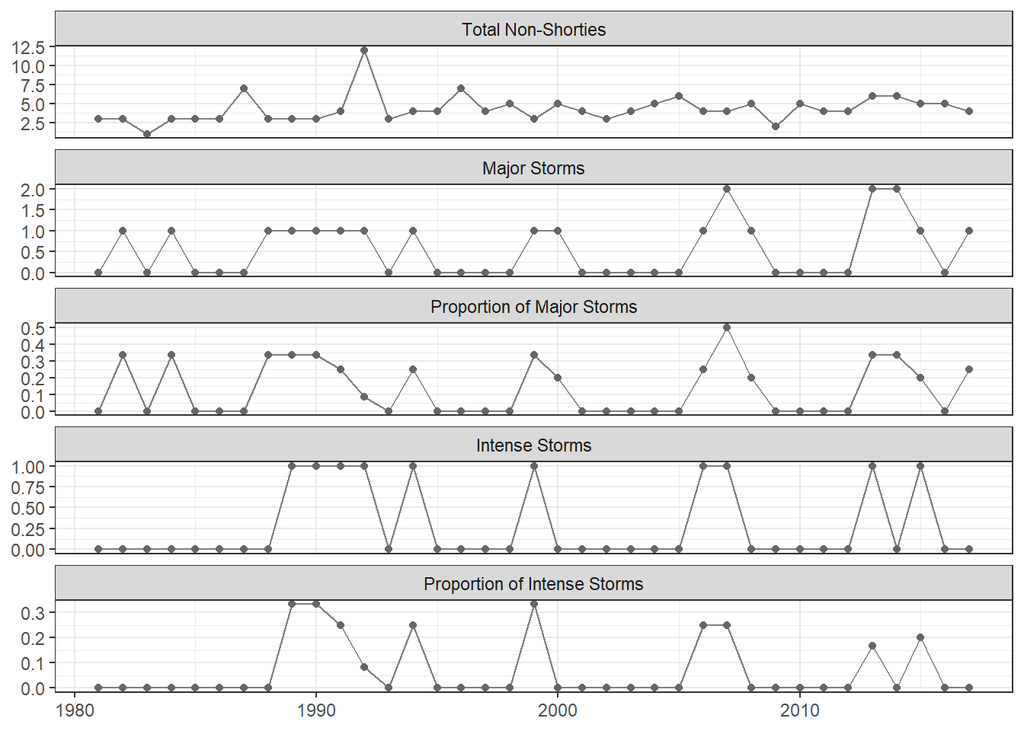

### Regression Methods

#### Poisson Regression on non-Shorties

```
Call:  glm(formula = Total_Storms ~ YearsSinceStart, family = poisson(link = "log"),
    data = storm_basin)

Coefficients:
    (Intercept)  YearsSinceStart
        1.28909          0.00912

Degrees of Freedom: 36 Total (i.e. Null);  35 Residual
Null Deviance:      24.92
Residual Deviance: 23.42    AIC: 148.2
```

```
Single term deletions

Model:
Total_Storms ~ YearsSinceStart
                Df Deviance    AIC    LRT Pr(>Chi)
<none>               23.419 148.16
YearsSinceStart  1   24.922 147.66 1.5034   0.2201
```

Using this model, we would predict 3.6294664 storms in 1981 and 5.0400378 storms in 2017.

That is a change of 0.3812355 storms per decade.

#### Poisson Regression on Major Storms

```
Call:  glm(formula = Major_Storms ~ YearsSinceStart, family = poisson(link = "log"),
    data = storm_basin)

Coefficients:
    (Intercept)  YearsSinceStart
       -0.97798          0.01901

Degrees of Freedom: 36 Total (i.e. Null);  35 Residual
Null Deviance:      32.93
Residual Deviance: 32.11    AIC: 71.95
```

```
Single term deletions

Model:
Major_Storms ~ YearsSinceStart
                Df Deviance    AIC     LRT Pr(>Chi)
<none>               32.111 71.952
YearsSinceStart  1   32.925 70.766 0.81429   0.3669
```

Using this model the number of a major storm in 1981 was 0.3760712 and 0.7456911 in 2017.

That is a change of 0.0998973 storms per decade.

#### Poisson Regression on Intense Storms

```
Call:  glm(formula = Intense_Storms ~ YearsSinceStart, family = poisson(link = "log"),
    data = storm_basin)

Coefficients:
    (Intercept)  YearsSinceStart
      -1.404710         0.005266

Degrees of Freedom: 36 Total (i.e. Null);  35 Residual
Null Deviance:      26.17
Residual Deviance: 26.14    AIC: 50.14
```

```
Single term deletions

Model:
Intense_Storms ~ YearsSinceStart
                Df Deviance    AIC      LRT Pr(>Chi)
<none>               26.135 50.135
YearsSinceStart  1   26.167 48.167 0.031589   0.8589
```

Using this model the number of a intense storms in 1981 was 0.2454382 and 0.2966755 in 2017.

That is a change of 0.0138479 storms per decade.

#### Logistic Regression on Proportions of Major

```
Call:  glm(formula = cbind(Major_Storms, Non_Major) ~ YearsSinceStart,
    family = binomial, data = prop_data)

Coefficients:
    (Intercept)  YearsSinceStart
       -2.17571          0.01214

Degrees of Freedom: 36 Total (i.e. Null);  35 Residual
Null Deviance:      36.67
Residual Deviance: 36.4     AIC: 70.71
```

```
Single term deletions

Model:
cbind(Major_Storms, Non_Major) ~ YearsSinceStart
                Df Deviance    AIC     LRT Pr(>Chi)
<none>               36.402 70.713
YearsSinceStart  1   36.672 68.983 0.26967   0.6036
```

Using this model the probability of a major storm in 1981 was 0.1019529 and 0.1494957 in 2017.

That is a change of 1.2849408 percent per decade.

#### Logistic Regression on Proportions of Intense

```
Call:  glm(formula = cbind(Intense_Storms, Non_Intense) ~ YearsSinceStart,
    family = binomial, data = prop_data)

Coefficients:
    (Intercept)  YearsSinceStart
      -2.617715        -0.004441

Degrees of Freedom: 36 Total (i.e. Null);  35 Residual
Null Deviance:      27.94
Residual Deviance: 27.92    AIC: 49.21
```

```
Single term deletions

Model:
cbind(Intense_Storms, Non_Intense) ~ YearsSinceStart
                Df Deviance   AIC     LRT Pr(>Chi)
<none>               27.918 49.21
YearsSinceStart  1   27.937 47.23 0.01944   0.8891
```

Using this model the probability of an intense storm in 1981 was 0.068007 and 0.0585465 in 2017.

That is a change of -0.255687 percent per decade.

### Changepoint Methods

#### Change in Non-Shorty Counts

```
  SCUSUM Stat chpt Location       p-value
    0.1776396    11.0000000     0.3546709
```

The dates suggest the changepoint would occur from 1991 to 1992 with $p$-value 0.3546709.

In regime one, the mean number of total storms is 3.2727273 and in regime two, the mean number of storms is 4.7307692; a change of 1.458042.

#### Change in counts of major storms

```
  SCUSUM Stat chpt Location       p-value
    0.1239956    25.0000000     0.5531716
```

The dates suggest the changepoint would occur from 2005 to 2006 with $p$-value 0.5531716.

In regime one, the mean number of major storms is 0.4 and in regime two, the mean number of storms is 0.8333333; a change of 0.4333333.

#### Change in counts of intense storms

```
  SCUSUM Stat chpt Location       p-value
   0.06764061    8.00000000    0.74858400
```

The dates suggest the changepoint would occur from 1988 to 1989 with $p$-value 0.748584.

In regime one, the mean number of intense storms is 0 and in regime two, the mean number of storms is 0.3448276; a change of 0.3448276.

#### Proportion of major storms

A change in the proportion of major storms?

```
  SCUSUM Stat chpt Location       p-value
   0.04665221   25.00000000    0.89052351
```

The change in proportions occurs 2005 to 2006 with $p$-value 0.8905235.

In regime one, the proportion of major storms is 0.0952381 and in regime two, the proportion of major storms is 0.1851852; a change of 0.0899471.

#### Proportion of intense storms

A change in the proportion of major storms?

```
  SCUSUM Stat chpt Location       p-value
   0.07125468    8.00000000    0.72387868
```

The change in proportions occurs 1988 to 1989 with $p$-value 0.7238787.

In regime one, the proportion of intense storms is 0 and in regime two, the proportion of major storms is 0.075188; a change of 0.075188.

## HURSAT Test Results

**Generalized Linear Model Approaches**

Note:

- we report the Likelihood Ratio Test for the generalized linear models, this is better to use than the default $Z$-test provided in the `summary()` output.
- the Change per decade is found by comparing the predicted value at the start time (1981) and end time (2017) and scaling by the number of years $\times 10$.

| Response | Coefficent | p.value | Start | End | Change per Decade |
| --- | --- | --- | --- | --- | --- |
| Cyclone Freq | 0.00912 | 0.22015 | 3.62947 | 5.04004 | 0.38124 |
| Major Freq | 0.01901 | 0.36686 | 0.37607 | 0.74569 | 0.09990 |
| Prop Major | 0.01214 | 0.60356 | 10.19529 | 14.94957 | 1.28494 |
| Intense Freq | 0.00527 | 0.85893 | 0.24544 | 0.29668 | 0.01385 |
| Prop Freq | -0.00444 | 0.88911 | 6.80070 | 5.85465 | -0.25569 |

**Changepoint Methods**

| Response | Chpt.Location | p.value | Regime1 | Regime2 | Change | Perc_Change |
| --- | --- | --- | --- | --- | --- | --- |
| Cyclone Freq | 1992 | 0.35467 | 3.27273 | 4.73077 | 1.45804 | 44.55128 |
| Major Freq | 2006 | 0.55317 | 0.40000 | 0.83333 | 0.43333 | 108.33333 |
| Prop Major | 2006 | 0.89052 | 9.52381 | 18.51852 | 8.99471 | 94.44444 |
| Intense Freq | 1989 | 0.74858 | 0.00000 | 0.34483 | 0.34483 | Inf |
| Prop Freq | 1989 | 0.72388 | 0.00000 | 7.51880 | 7.51880 | Inf |

## Trimmed IBTRacs Full Analysis

### Summary Statistics (overall)

| Total Storms (Avg) | Total Storms (stddev) | Major Storms (Avg) | Major Storms (stddev) | Prop Major Storms | Intense Storms (Avg) | Intense Storms (stddev) | Prop Intense Storms |
| --- | --- | --- | --- | --- | --- | --- | --- |
| 2.837838 | 1.536835 | 0.7837838 | 0.7865231 | 0.2761905 | 0.6216216 | 0.720777 | 0.2190476 |

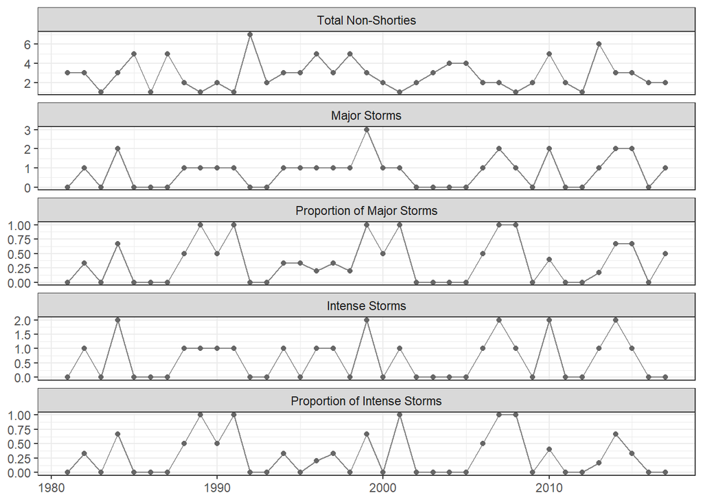

### Regression Methods

#### Poisson Regression on non-Shorties

```
Call:  glm(formula = Total_Storms ~ YearsSinceStart, family = poisson(link = "log"),
    data = storm_basin)

Coefficients:
    (Intercept)  YearsSinceStart
        1.06849         -0.00142

Degrees of Freedom: 36 Total (i.e. Null);  35 Residual
Null Deviance:      28.77
Residual Deviance: 28.75    AIC: 136.8
```

```
Single term deletions

Model:
Total_Storms ~ YearsSinceStart
                Df Deviance    AIC      LRT Pr(>Chi)
<none>               28.749 136.82
YearsSinceStart  1   28.773 134.84 0.024144   0.8765
```

Using this model, we would predict 2.910988 storms in 1981 and 2.7658897 storms in 2017.

That is a change of -0.0392157 storms per decade.

#### Poisson Regression on Major Storms

```
Call:  glm(formula = Major_Storms ~ YearsSinceStart, family = poisson(link = "log"),
    data = storm_basin)

Coefficients:
    (Intercept)  YearsSinceStart
       -0.53650          0.01551

Degrees of Freedom: 36 Total (i.e. Null);  35 Residual
Null Deviance:      34.58
Residual Deviance: 33.8     AIC: 85.86
```

```
Single term deletions

Model:
Major_Storms ~ YearsSinceStart
                Df Deviance    AIC    LRT Pr(>Chi)
<none>               33.796 85.856
YearsSinceStart  1   34.585 84.645 0.7889   0.3744
```

Using this model the number of a major storm in 1981 was 0.5847931 and 1.022142 in 2017.

That is a change of 0.1182024 storms per decade.

#### Poisson Regression on Intense Storms

```
Call:  glm(formula = Intense_Storms ~ YearsSinceStart, family = poisson(link = "log"),
    data = storm_basin)

Coefficients:
    (Intercept)  YearsSinceStart
      -0.623465         0.008021

Degrees of Freedom: 36 Total (i.e. Null);  35 Residual
Null Deviance:      35.73
Residual Deviance: 35.56    AIC: 78.63
```

```
Single term deletions

Model:
Intense_Storms ~ YearsSinceStart
                Df Deviance    AIC     LRT Pr(>Chi)
<none>               35.564 78.633
YearsSinceStart  1   35.732 76.801 0.16832   0.6816
```

Using this model the number of an intense storm in 1981 was 0.536084 and 0.7155443 in 2017.

That is a change of 0.0485028 storms per decade.

#### Logistic Regression on Proportions of Major

```
Call:  glm(formula = cbind(Major_Storms, Non_Major) ~ YearsSinceStart,
    family = binomial, data = prop_data)

Coefficients:
    (Intercept)  YearsSinceStart
       -1.41248          0.02436

Degrees of Freedom: 36 Total (i.e. Null);  35 Residual
Null Deviance:      61.02
Residual Deviance: 59.67    AIC: 89.47
```

```
Single term deletions

Model:
cbind(Major_Storms, Non_Major) ~ YearsSinceStart
                Df Deviance    AIC    LRT Pr(>Chi)
<none>               59.665 89.468
YearsSinceStart  1   61.016 88.819 1.3505   0.2452
```

Using this model the probability of a major storm in 1981 was 0.195844 and 0.369228 in 2017.

That is a change of 4.6860547 percent per decade.

#### Logistic Regression on Proportions of Intense

```
Call:  glm(formula = cbind(Intense_Storms, Non_Intense) ~ YearsSinceStart,
    family = binomial, data = prop_data)

Coefficients:
    (Intercept)  YearsSinceStart
       -1.49996          0.01255

Degrees of Freedom: 36 Total (i.e. Null);  35 Residual
Null Deviance:      58.2
Residual Deviance: 57.89    AIC: 83.14
```

```
Single term deletions

Model:
cbind(Intense_Storms, Non_Intense) ~ YearsSinceStart
                Df Deviance   AIC     LRT Pr(>Chi)
<none>               57.895 83.14
YearsSinceStart  1   58.205 81.45 0.30998   0.5777
```

Using this model the probability of an intense storm in 1981 was 0.1824321 and 0.2595824 in 2017.

That is a change of 2.0851443 percent per decade.

### Changepoint Methods

#### Change in Non-Shorty Counts

```
  SCUSUM Stat chpt Location       p-value
   0.03064454   11.00000000    0.97299339
```

The dates suggest the changepoint would occur from 1991 to 1992 with $p$-value 0.9729934.

In regime one, the mean number of total storms is 2.4545455 and in regime two, the mean number of storms is 3; a change of 0.5454545.

#### Change in counts of major storms

```
  SCUSUM Stat chpt Location       p-value
    0.1022896    13.0000000     0.6779016
```

The dates suggest the changepoint would occur from 1993 to 1994 with $p$-value 0.6779016.

In regime one, the mean number of major storms is 0.5384615 and in regime two, the mean number of storms is 0.9166667; a change of 0.3782051.

#### Change in counts of intense storms

```
  SCUSUM Stat chpt Location       p-value
   0.04042938   25.00000000    0.92752074
```

The dates suggest the changepoint would occur from 2005 to 2006 with $p$-value 0.9275207.

In regime one, the mean number of intense storms is 0.52 and in regime two, the mean number of storms is 0.8333333; a change of 0.3133333.

#### Proportion of major storms

A change in the proportion of major storms?

```
  SCUSUM Stat chpt Location       p-value
   0.09808116    7.00000000    0.55384949
```

The change in proportions occurs 1987 to 1988 with $p$-value 0.5538495.

In regime one, the proportion of major storms is 0.1428571 and in regime two, the proportion of major storms is 0.3095238; a change of 0.1666667.

#### Proportion of intense storms

A change in the proportion of major storms?

```
  SCUSUM Stat chpt Location       p-value
   0.08299029   28.00000000    0.64613665
```

The change in proportions occurs 2008 to 2009 with $p$-value 0.6461366.

In regime one, the proportion of intense storms is 0.2151899 and in regime two, the proportion of major storms is 0.2307692; a change of 0.0155794.

## Trimmed IBTRacs Test Results

**Generalized Linear Model Approaches**

Note:

- we report the Likelihood Ratio Test for the generalized linear models, this is better to use than the default $Z$-test provided in the `summary()` output.
- the Change per decade is found by comparing the predicted value at the start time (1981) and end time (2017) and scaling by the number of years $\times 10$.

| Response | Coefficent | p.value | Start | End | Change per Decade |
| --- | --- | --- | --- | --- | --- |
| Cyclone Freq | -0.00142 | 0.87652 | 2.91099 | 2.76589 | -0.03922 |
| Major Freq | 0.01551 | 0.37443 | 0.58479 | 1.02214 | 0.11820 |
| Prop Major | 0.02436 | 0.24518 | 19.58440 | 36.92280 | 4.68605 |
| Intense Freq | 0.00802 | 0.68161 | 0.53608 | 0.71554 | 0.04850 |
| Prop Freq | 0.01255 | 0.57769 | 18.24321 | 25.95824 | 2.08514 |

**Changepoint Methods**

| Response | Chpt.Location | p.value | Regime1 | Regime2 | Change | Perc_Change |
| --- | --- | --- | --- | --- | --- | --- |
| Cyclone Freq | 1992 | 0.97299 | 2.45455 | 3.00000 | 0.54545 | 22.22222 |
| Major Freq | 1994 | 0.67790 | 0.53846 | 0.91667 | 0.37821 | 70.23810 |
| Prop Major | 1988 | 0.55385 | 14.28571 | 30.95238 | 16.66667 | 116.66667 |
| Intense Freq | 2006 | 0.92752 | 0.52000 | 0.83333 | 0.31333 | 60.25641 |
| Prop Freq | 2009 | 0.64614 | 21.51899 | 23.07692 | 1.55794 | 7.23982 |

# South Indian

## IBTracs Full Analysis

### Summary Statistics (overall)

| Total Storms (Avg) | Total Storms (stddev) | Major Storms (Avg) | Major Storms (stddev) | Prop Major Storms | Intense Storms (Avg) | Intense Storms (stddev) | Prop Intense Storms |
| --- | --- | --- | --- | --- | --- | --- | --- |
| 14.1087 | 3.177898 | 4.956522 | 2.384734 | 0.3513097 | 3.152174 | 1.931809 | 0.2234206 |

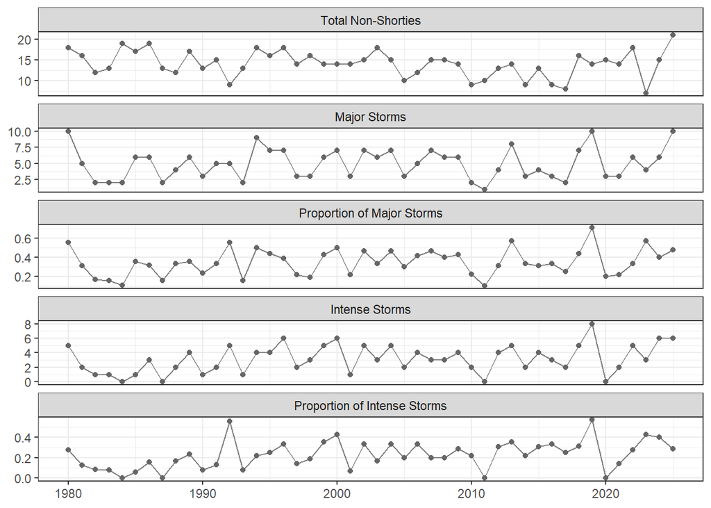

### Regression Methods

#### Poisson Regression on non-Shorties

```
Call:  glm(formula = Total_Storms ~ YearsSinceStart, family = poisson(link = "log"),
    data = storm_basin)

Coefficients:
    (Intercept)  YearsSinceStart
       2.736758        -0.004063

Degrees of Freedom: 45 Total (i.e. Null);  44 Residual
Null Deviance:      33.63
Residual Deviance: 31.74    AIC: 241.3
```

```
Single term deletions

Model:
Total_Storms ~ YearsSinceStart
                Df Deviance    AIC    LRT Pr(>Chi)
<none>               31.744 241.34
YearsSinceStart  1   33.631 241.22 1.8868   0.1696
```

Using this model, we would predict 15.4368596 storms in 1980 and 12.8573494 storms in 2025.

That is a change of -0.5607631 storms per decade.

#### Poisson Regression on Major Storms

```
Call:  glm(formula = Major_Storms ~ YearsSinceStart, family = poisson(link = "log"),
    data = storm_basin)

Coefficients:
    (Intercept)  YearsSinceStart
       1.524091         0.003361

Degrees of Freedom: 45 Total (i.e. Null);  44 Residual
Null Deviance:      52.74
Residual Deviance: 52.28    AIC: 210.5
```

```
Single term deletions

Model:
Major_Storms ~ YearsSinceStart
                Df Deviance    AIC     LRT Pr(>Chi)
<none>               52.283 210.52
YearsSinceStart  1   52.736 208.98 0.45362   0.5006
```

Using this model the number of a major storm in 1980 was 4.5909686 and 5.3405417 in 2025.

That is a change of 0.1629507 storms per decade.

#### Poisson Regression on Intense Storms

```
Call:  glm(formula = Intense_Storms ~ YearsSinceStart, family = poisson(link = "log"),
    data = storm_basin)

Coefficients:
    (Intercept)  YearsSinceStart
        0.77654          0.01557

Degrees of Freedom: 45 Total (i.e. Null);  44 Residual
Null Deviance:      63.81
Residual Deviance: 57.7     AIC: 187.4
```

```
Single term deletions

Model:
Intense_Storms ~ YearsSinceStart
                Df Deviance    AIC    LRT Pr(>Chi)
<none>               57.696 187.44
YearsSinceStart  1   63.811 191.55 6.1155   0.0134 *
---
Signif. codes:  0 '***' 0.001 '**' 0.01 '*' 0.05 '.' 0.1 ' ' 1
```

Using this model the number of a intense storm in 1980 was 2.1739443 and 4.3802506 in 2025.

That is a change of 0.4796318 storms per decade.

#### Logistic Regression on Proportions of Major

```
Call:  glm(formula = cbind(Major_Storms, Non_Major) ~ YearsSinceStart,
    family = binomial, data = prop_data)

Coefficients:
    (Intercept)  YearsSinceStart
       -0.85747          0.01106

Degrees of Freedom: 45 Total (i.e. Null);  44 Residual
Null Deviance:      55.04
Residual Deviance: 51.74    AIC: 189.5
```

```
Single term deletions

Model:
cbind(Major_Storms, Non_Major) ~ YearsSinceStart
                Df Deviance    AIC    LRT Pr(>Chi)
<none>               51.742 189.52
YearsSinceStart  1   55.036 190.82 3.2942  0.06952 .
---
Signif. codes:  0 '***' 0.001 '**' 0.01 '*' 0.05 '.' 0.1 ' ' 1
```

Using this model the probability of a major storm in 1980 was 0.297869 and 0.4109927 in 2025.

That is a change of 2.459211 percent per decade.

#### Logistic Regression on Proportions of Intense

```
Call:  glm(formula = cbind(Intense_Storms, Non_Intense) ~ YearsSinceStart,
    family = binomial, data = prop_data)

Coefficients:
    (Intercept)  YearsSinceStart
       -1.80814          0.02444

Degrees of Freedom: 45 Total (i.e. Null);  44 Residual
Null Deviance:      76
Residual Deviance: 63.89    AIC: 181.1
```

```
Single term deletions

Model:
cbind(Intense_Storms, Non_Intense) ~ YearsSinceStart
                Df Deviance    AIC    LRT  Pr(>Chi)
<none>               63.890 181.15
YearsSinceStart  1   75.999 191.25 12.109 0.0005018 ***
---
Signif. codes:  0 '***' 0.001 '**' 0.01 '*' 0.05 '.' 0.1 ' ' 1
```

Using this model the probability of an intense storm in 1980 was 0.140863 and 0.3299566 in 2025.

That is a change of 4.1107309 percent per decade.

### Changepoint Methods

#### Change in Non-Shorty Counts

```
  SCUSUM Stat chpt Location       p-value
    0.2946809    25.0000000     0.1545545
```

The dates suggest the changepoint would occur from 2004 to 2005 with $p$-value 0.1545545.

In regime one, the mean number of total storms is 15.12 and in regime two, the mean number of storms is 12.9047619; a change of -2.2152381.

#### Change in counts of major storms

```
  SCUSUM Stat chpt Location       p-value
    0.0867451    14.0000000     0.6222972
```

The dates suggest the changepoint would occur from 1993 to 1994 with $p$-value 0.6222972.

In regime one, the mean number of major storms is 4.2857143 and in regime two, the mean number of storms is 5.25; a change of 0.9642857.

#### Change in counts of intense storms

```
  SCUSUM Stat chpt Location       p-value
   0.63009745   14.00000000    0.02019312
```

The dates suggest the changepoint would occur from 1993 to 1994 with $p$-value 0.0201931.

In regime one, the mean number of intense storms is 2 and in regime two, the mean number of storms is 3.65625; a change of 1.65625.

#### Proportion of major storms

A change in the proportion of major storms?

```
  SCUSUM Stat chpt Location       p-value
    0.3232242    12.0000000     0.1281837
```

The change in proportions occurs 1991 to 1992 with $p$-value 0.1281837.

In regime one, the proportion of major storms is 0.2880435 and in regime two, the proportion of major storms is 0.3763441; a change of 0.0883006.

#### Proportion of intense storms

A change in the proportion of major storms?

```
  SCUSUM Stat chpt Location       p-value
  1.130598973  12.000000000   0.001275262
```

The change in proportions occurs 1991 to 1992 with $p$-value 0.0012753.

In regime one, the proportion of intense storms is 0.1195652 and in regime two, the proportion of major storms is 0.2645161; a change of 0.1449509.

## IBTracs Test Results

**Generalized Linear Model Approaches**

Note:

- we report the Likelihood Ratio Test for the generalized linear models, this is better to use than the default $Z$-test provided in the `summary()` output.
- the Change per decade is found by comparing the predicted value at the start time (1980) and end time (2025) and scaling by the number of years $\times 10$.

| Response | Coefficent | p.value | Start | End | Change per Decade |
| --- | --- | --- | --- | --- | --- |
| Cyclone Freq | -0.00406 | 0.16956 | 15.43686 | 12.85735 | -0.56076 |
| Major Freq | 0.00336 | 0.50062 | 4.59097 | 5.34054 | 0.16295 |
| Prop Major | 0.01106 | 0.06952 | 29.78690 | 41.09927 | 2.45921 |
| Intense Freq | 0.01557 | 0.01340 | 2.17394 | 4.38025 | 0.47963 |
| Prop Freq | 0.02444 | 0.00050 | 14.08630 | 32.99566 | 4.11073 |

**Changepoint Methods**

| Response | Chpt.Location | p.value | Regime1 | Regime2 | Change | Perc_Change |
| --- | --- | --- | --- | --- | --- | --- |
| Cyclone Freq | 2005 | 0.15455 | 15.12000 | 12.90476 | -2.21524 | -14.65105 |
| Major Freq | 1994 | 0.62230 | 4.28571 | 5.25000 | 0.96429 | 22.50000 |
| Prop Major | 1992 | 0.12818 | 28.80435 | 37.63441 | 8.83006 | 30.65531 |
| Intense Freq | 1994 | 0.02019 | 2.00000 | 3.65625 | 1.65625 | 82.81250 |
| Prop Freq | 1992 | 0.00128 | 11.95652 | 26.45161 | 14.49509 | 121.23167 |

## HURSAT Full Analysis

### Summary Statistics (overall)

| Total Storms (Avg) | Total Storms (stddev) | Major Storms (Avg) | Major Storms (stddev) | Prop Major Storms | Intense Storms (Avg) | Intense Storms (stddev) | Prop Intense Storms |
| --- | --- | --- | --- | --- | --- | --- | --- |
| 16.35135 | 3.874534 | 4.081081 | 2.384887 | 0.2495868 | 2.405405 | 1.707166 | 0.1471074 |

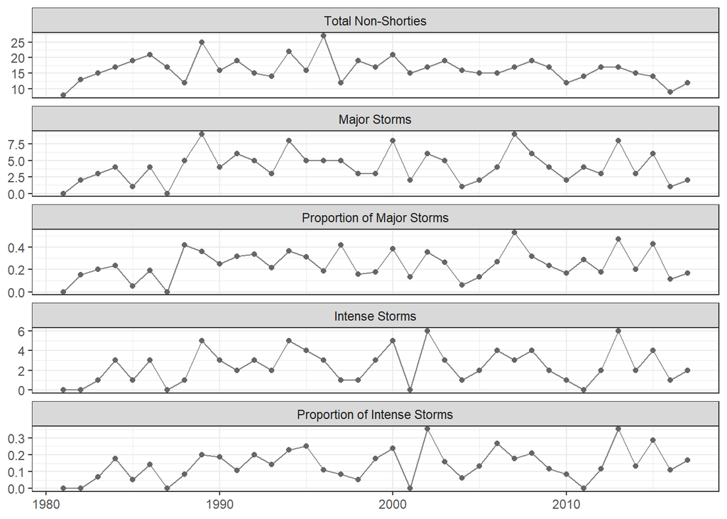

### Regression Methods

#### Poisson Regression on non-Shorties

```
Call:  glm(formula = Total_Storms ~ YearsSinceStart, family = poisson(link = "log"),
    data = storm_basin)

Coefficients:
    (Intercept)  YearsSinceStart
       2.861633        -0.003785

Degrees of Freedom: 36 Total (i.e. Null);  35 Residual
Null Deviance:      32.99
Residual Deviance: 32   AIC: 206.7
```

```
Single term deletions

Model:
Total_Storms ~ YearsSinceStart
                Df Deviance    AIC     LRT Pr(>Chi)
<none>               31.998 206.75
YearsSinceStart  1   32.986 205.73 0.98785   0.3203
```

Using this model, we would predict 17.4900602 storms in 1981 and 15.2618311 storms in 2017.

That is a change of -0.6022241 storms per decade.

#### Poisson Regression on Major Storms

```
Call:  glm(formula = Major_Storms ~ YearsSinceStart, family = poisson(link = "log"),
    data = storm_basin)

Coefficients:
    (Intercept)  YearsSinceStart
       1.301962         0.005697

Degrees of Freedom: 36 Total (i.e. Null);  35 Residual
Null Deviance:      56.72
Residual Deviance: 56.16    AIC: 172.2
```

```
Single term deletions

Model:
Major_Storms ~ YearsSinceStart
                Df Deviance    AIC     LRT Pr(>Chi)
<none>               56.160 172.21
YearsSinceStart  1   56.718 170.77 0.55812    0.455
```

Using this model the number of a major storm in 1981 was 3.6765022 and 4.5134558 in 2017.

That is a change of 0.2262037 storms per decade.

#### Poisson Regression on Intense Storms

```
Call:  glm(formula = Intense_Storms ~ YearsSinceStart, family = poisson(link = "log"),
    data = storm_basin)

Coefficients:
    (Intercept)  YearsSinceStart
        0.64842          0.01226

Degrees of Freedom: 36 Total (i.e. Null);  35 Residual
Null Deviance:      51.55
Residual Deviance: 50.04    AIC: 143.1
```

```
Single term deletions

Model:
Intense_Storms ~ YearsSinceStart
                Df Deviance    AIC    LRT Pr(>Chi)
<none>               50.036 143.09
YearsSinceStart  1   51.554 142.60 1.5181   0.2179
```

Using this model the number of a intense storms in 1981 was 1.9125133 and 2.9739863 in 2017.

That is a change of 0.2868846 storms per decade.

#### Logistic Regression on Proportions of Major

```
Call:  glm(formula = cbind(Major_Storms, Non_Major) ~ YearsSinceStart,
    family = binomial, data = prop_data)

Coefficients:
    (Intercept)  YearsSinceStart
       -1.35246          0.01404

Degrees of Freedom: 36 Total (i.e. Null);  35 Residual
Null Deviance:      55.02
Residual Deviance: 52.73    AIC: 158
```

```
Single term deletions

Model:
cbind(Major_Storms, Non_Major) ~ YearsSinceStart
                Df Deviance    AIC   LRT Pr(>Chi)
<none>               52.734 158.05
YearsSinceStart  1   55.022 158.34 2.288   0.1304
```

Using this model the probability of a major storm in 1981 was 0.2054687 and 0.3000267 in 2017.

That is a change of 2.5556198 percent per decade.

#### Logistic Regression on Proportions of Intense

```
Call:  glm(formula = cbind(Intense_Storms, Non_Intense) ~ YearsSinceStart,
    family = binomial, data = prop_data)

Coefficients:
    (Intercept)  YearsSinceStart
       -2.14023          0.02089

Degrees of Freedom: 36 Total (i.e. Null);  35 Residual
Null Deviance:      46.53
Residual Deviance: 43.15    AIC: 130.4
```

```
Single term deletions

Model:
cbind(Intense_Storms, Non_Intense) ~ YearsSinceStart
                Df Deviance    AIC    LRT Pr(>Chi)
<none>               43.149 130.41
YearsSinceStart  1   46.535 131.80 3.3853  0.06578 .
---
Signif. codes:  0 '***' 0.001 '**' 0.01 '*' 0.05 '.' 0.1 ' ' 1
```

Using this model the probability of an intense storm in 1981 was 0.105248 and 0.1996873 in 2017.

That is a change of 2.5524133 percent per decade.

### Changepoint Methods

#### Change in Non-Shorty Counts

```
  SCUSUM Stat chpt Location       p-value
    0.2748281    29.0000000     0.1765122
```

The dates suggest the changepoint would occur from 2009 to 2010 with $p$-value 0.1765122.

In regime one, the mean number of total storms is 17.0689655 and in regime two, the mean number of storms is 13.75; a change of -3.3189655.

#### Change in counts of major storms

```
  SCUSUM Stat chpt Location       p-value
    0.2171257     7.0000000     0.2640068
```

The dates suggest the changepoint would occur from 1987 to 1988 with $p$-value 0.2640068.

In regime one, the mean number of major storms is 2 and in regime two, the mean number of storms is 4.5666667; a change of 2.5666667.

#### Change in counts of intense storms

```
  SCUSUM Stat chpt Location       p-value
    0.2420039     8.0000000     0.2211778
```

The dates suggest the changepoint would occur from 1988 to 1989 with $p$-value 0.2211778.

In regime one, the mean number of intense storms is 1.125 and in regime two, the mean number of storms is 2.7586207; a change of 1.6336207.

#### Proportion of major storms

A change in the proportion of major storms?

```
  SCUSUM Stat chpt Location       p-value
    0.2911062     7.0000000     0.1582680
```

The change in proportions occurs 1987 to 1988 with $p$-value 0.158268.

In regime one, the proportion of major storms is 0.1272727 and in regime two, the proportion of major storms is 0.2767677; a change of 0.1494949.

#### Proportion of intense storms

A change in the proportion of major storms?

```
  SCUSUM Stat chpt Location       p-value
   0.40446066    8.00000000    0.07674396
```

The change in proportions occurs 1988 to 1989 with $p$-value 0.076744.

In regime one, the proportion of intense storms is 0.0737705 and in regime two, the proportion of major storms is 0.1656315; a change of 0.091861.

## HURSAT Test Results

**Generalized Linear Model Approaches**

Note:

- we report the Likelihood Ratio Test for the generalized linear models, this is better to use than the default $Z$-test provided in the `summary()` output.
- the Change per decade is found by comparing the predicted value at the start time (1981) and end time (2017) and scaling by the number of years $\times 10$.

| Response | Coefficent | p.value | Start | End | Change per Decade |
| --- | --- | --- | --- | --- | --- |
| Cyclone Freq | -0.00379 | 0.32027 | 17.49006 | 15.26183 | -0.60222 |
| Major Freq | 0.00570 | 0.45502 | 3.67650 | 4.51346 | 0.22620 |
| Prop Major | 0.01404 | 0.13038 | 20.54687 | 30.00267 | 2.55562 |
| Intense Freq | 0.01226 | 0.21791 | 1.91251 | 2.97399 | 0.28688 |
| Prop Freq | 0.02089 | 0.06578 | 10.52480 | 19.96873 | 2.55241 |

**Changepoint Methods**

| Response | Chpt.Location | p.value | Regime1 | Regime2 | Change | Perc_Change |
| --- | --- | --- | --- | --- | --- | --- |
| Cyclone Freq | 2010 | 0.17651 | 17.06897 | 13.75000 | -3.31897 | -19.44444 |
| Major Freq | 1988 | 0.26401 | 2.00000 | 4.56667 | 2.56667 | 128.33333 |
| Prop Major | 1988 | 0.15827 | 12.72727 | 27.67677 | 14.94949 | 117.46032 |
| Intense Freq | 1989 | 0.22118 | 1.12500 | 2.75862 | 1.63362 | 145.21073 |
| Prop Freq | 1989 | 0.07674 | 7.37705 | 16.56315 | 9.18610 | 124.52266 |

## Trimmed IBTRacs Full Analysis

### Summary Statistics (overall)

| Total Storms (Avg) | Total Storms (stddev) | Major Storms (Avg) | Major Storms (stddev) | Prop Major Storms | Intense Storms (Avg) | Intense Storms (stddev) | Prop Intense Storms |
| --- | --- | --- | --- | --- | --- | --- | --- |
| 13.81081 | 2.970576 | 4.567568 | 2.102123 | 0.3307241 | 2.837838 | 1.691704 | 0.2054795 |

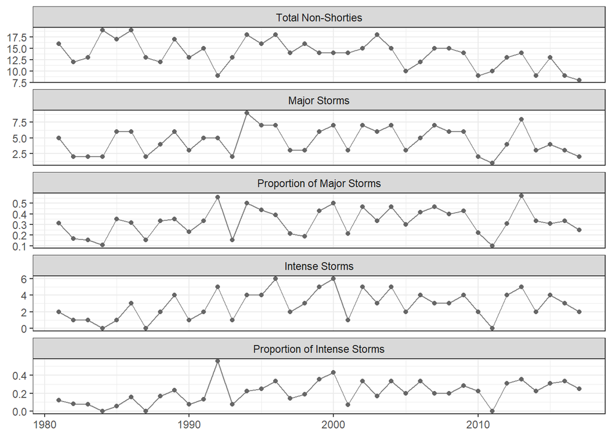

### Regression Methods

#### Poisson Regression on non-Shorties

```
Call:  glm(formula = Total_Storms ~ YearsSinceStart, family = poisson(link = "log"),
    data = storm_basin)

Coefficients:
    (Intercept)  YearsSinceStart
       2.793861        -0.009651

Degrees of Freedom: 36 Total (i.e. Null);  35 Residual
Null Deviance:      23.74
Residual Deviance: 18.33    AIC: 187
```

```
Single term deletions

Model:
Total_Storms ~ YearsSinceStart
                Df Deviance    AIC    LRT Pr(>Chi)
<none>               18.334 187.04
YearsSinceStart  1   23.742 190.45 5.4083  0.02004 *
---
Signif. codes:  0 '***' 0.001 '**' 0.01 '*' 0.05 '.' 0.1 ' ' 1
```

Using this model, we would predict 16.3440052 storms in 1981 and 11.5471186 storms in 2017.

That is a change of -1.2964558 storms per decade.

#### Poisson Regression on Major Storms

```
Call:  glm(formula = Major_Storms ~ YearsSinceStart, family = poisson(link = "log"),
    data = storm_basin)

Coefficients:
    (Intercept)  YearsSinceStart
      1.5030532        0.0008824

Degrees of Freedom: 36 Total (i.e. Null);  35 Residual
Null Deviance:      36.57
Residual Deviance: 36.55    AIC: 162
```

```
Single term deletions

Model:
Major_Storms ~ YearsSinceStart
                Df Deviance    AIC      LRT Pr(>Chi)
<none>               36.553 161.95
YearsSinceStart  1   36.568 159.97 0.015001   0.9025
```

Using this model the number of a major storm in 1981 was 4.4953936 and 4.6404883 in 2017.

That is a change of 0.0392148 storms per decade.

#### Poisson Regression on Intense Storms

```
Call:  glm(formula = Intense_Storms ~ YearsSinceStart, family = poisson(link = "log"),
    data = storm_basin)

Coefficients:
    (Intercept)  YearsSinceStart
        0.71580          0.01724

Degrees of Freedom: 36 Total (i.e. Null);  35 Residual
Null Deviance:      43.8
Residual Deviance: 40.28    AIC: 142.7
```

```
Single term deletions

Model:
Intense_Storms ~ YearsSinceStart
                Df Deviance    AIC    LRT Pr(>Chi)
<none>               40.276 142.72
YearsSinceStart  1   43.798 144.24 3.5227  0.06053 .
---
Signif. codes:  0 '***' 0.001 '**' 0.01 '*' 0.05 '.' 0.1 ' ' 1
```

Using this model the number of an intense storm in 1981 was 2.0458164 and 3.8057433 in 2017.

That is a change of 0.4756559 storms per decade.

#### Logistic Regression on Proportions of Major

```
Call:  glm(formula = cbind(Major_Storms, Non_Major) ~ YearsSinceStart,
    family = binomial, data = prop_data)

Coefficients:
    (Intercept)  YearsSinceStart
       -0.99448          0.01683

Degrees of Freedom: 36 Total (i.e. Null);  35 Residual
Null Deviance:      36.96
Residual Deviance: 33.55    AIC: 143.9
```

```
Single term deletions

Model:
cbind(Major_Storms, Non_Major) ~ YearsSinceStart
                Df Deviance   AIC    LRT Pr(>Chi)
<none>               33.555 143.9
YearsSinceStart  1   36.959 145.3 3.4039  0.06504 .
---
Signif. codes:  0 '***' 0.001 '**' 0.01 '*' 0.05 '.' 0.1 ' ' 1
```

Using this model the probability of a major storm in 1981 was 0.2700286 and 0.4040687 in 2017.

That is a change of 3.622707 percent per decade.

#### Logistic Regression on Proportions of Intense

```
Call:  glm(formula = cbind(Intense_Storms, Non_Intense) ~ YearsSinceStart,
    family = binomial, data = prop_data)

Coefficients:
    (Intercept)  YearsSinceStart
       -2.01054          0.03649

Degrees of Freedom: 36 Total (i.e. Null);  35 Residual
Null Deviance:      53.48
Residual Deviance: 41.89    AIC: 135.2
```

```
Single term deletions

Model:
cbind(Intense_Storms, Non_Intense) ~ YearsSinceStart
                Df Deviance    AIC    LRT  Pr(>Chi)
<none>               41.886 135.22
YearsSinceStart  1   53.475 144.81 11.589 0.0006633 ***
---
Signif. codes:  0 '***' 0.001 '**' 0.01 '*' 0.05 '.' 0.1 ' ' 1
```

Using this model the probability of an intense storm in 1981 was 0.118101 and 0.3324945 in 2017.

That is a change of 5.7944174 percent per decade.

### Changepoint Methods

#### Change in Non-Shorty Counts

```
  SCUSUM Stat chpt Location       p-value
   0.57366855   24.00000000    0.02795842
```

The dates suggest the changepoint would occur from 2004 to 2005 with $p$-value 0.0279584.

In regime one, the mean number of total storms is 15 and in regime two, the mean number of storms is 11.6153846; a change of -3.3846154.

#### Change in counts of major storms

```
  SCUSUM Stat chpt Location       p-value
    0.1594694    29.0000000     0.4094477
```

The dates suggest the changepoint would occur from 2009 to 2010 with $p$-value 0.4094477.

In regime one, the mean number of major storms is 4.8965517 and in regime two, the mean number of storms is 3.375; a change of -1.5215517.

#### Change in counts of intense storms

```
  SCUSUM Stat chpt Location       p-value
   0.53370204   11.00000000    0.03530598
```

The dates suggest the changepoint would occur from 1991 to 1992 with $p$-value 0.035306.

In regime one, the mean number of intense storms is 1.5454545 and in regime two, the mean number of storms is 3.3846154; a change of 1.8391608.

#### Proportion of major storms

A change in the proportion of major storms?

```
  SCUSUM Stat chpt Location       p-value
    0.2969966    10.0000000     0.1522015
```

The change in proportions occurs 1990 to 1991 with $p$-value 0.1522015.

In regime one, the proportion of major storms is 0.2516556 and in regime two, the proportion of major storms is 0.3638889; a change of 0.1122333.

#### Proportion of intense storms

A change in the proportion of major storms?

```
  SCUSUM Stat chpt Location       p-value
  0.955970970  11.000000000   0.003283119
```

The change in proportions occurs 1991 to 1992 with $p$-value 0.0032831.

In regime one, the proportion of intense storms is 0.1024096 and in regime two, the proportion of major storms is 0.2550725; a change of 0.1526628.

## Trimmed IBTRacs Test Results

**Generalized Linear Model Approaches**

Note:

- we report the Likelihood Ratio Test for the generalized linear models, this is better to use than the default $Z$-test provided in the `summary()` output.
- the Change per decade is found by comparing the predicted value at the start time (1981) and end time (2017) and scaling by the number of years $\times 10$.

| Response | Coefficent | p.value | Start | End | Change per Decade |
| --- | --- | --- | --- | --- | --- |
| Cyclone Freq | -0.00965 | 0.02004 | 16.34401 | 11.54712 | -1.29646 |
| Major Freq | 0.00088 | 0.90252 | 4.49539 | 4.64049 | 0.03921 |
| Prop Major | 0.01683 | 0.06504 | 27.00286 | 40.40687 | 3.62271 |
| Intense Freq | 0.01724 | 0.06053 | 2.04582 | 3.80574 | 0.47566 |
| Prop Freq | 0.03649 | 0.00066 | 11.81010 | 33.24945 | 5.79442 |

**Changepoint Methods**

| Response | Chpt.Location | p.value | Regime1 | Regime2 | Change | Perc_Change |
| --- | --- | --- | --- | --- | --- | --- |
| Cyclone Freq | 2005 | 0.02796 | 15.00000 | 11.61538 | -3.38462 | -22.56410 |
| Major Freq | 2010 | 0.40945 | 4.89655 | 3.37500 | -1.52155 | -31.07394 |
| Prop Major | 1991 | 0.15220 | 25.16556 | 36.38889 | 11.22333 | 44.59795 |
| Intense Freq | 1992 | 0.03531 | 1.54545 | 3.38462 | 1.83916 | 119.00452 |
| Prop Freq | 1992 | 0.00328 | 10.24096 | 25.50725 | 15.26628 | 149.07076 |

# South Pacific

## IBTracs Full Analysis

### Summary Statistics (overall)

| Total Storms (Avg) | Total Storms (stddev) | Major Storms (Avg) | Major Storms (stddev) | Prop Major Storms | Intense Storms (Avg) | Intense Storms (stddev) | Prop Intense Storms |
| --- | --- | --- | --- | --- | --- | --- | --- |
| 8.108696 | 3.092847 | 2.478261 | 1.545447 | 0.30563 | 1.369565 | 1.253594 | 0.1689008 |

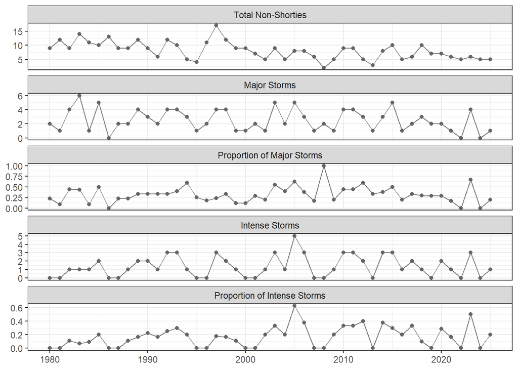

### Regression Methods

#### Poisson Regression on non-Shorties

```
Call:  glm(formula = Total_Storms ~ YearsSinceStart, family = poisson(link = "log"),
    data = storm_basin)

Coefficients:
    (Intercept)  YearsSinceStart
        2.42802         -0.01588

Degrees of Freedom: 45 Total (i.e. Null);  44 Residual
Null Deviance:      53.7
Residual Deviance: 37.35    AIC: 219.7
```

```
Single term deletions

Model:
Total_Storms ~ YearsSinceStart
                Df Deviance    AIC    LRT  Pr(>Chi)
<none>               37.347 219.67
YearsSinceStart  1   53.697 234.02 16.351 5.264e-05 ***
---
Signif. codes:  0 '***' 0.001 '**' 0.01 '*' 0.05 '.' 0.1 ' ' 1
```

Using this model, we would predict 11.3364155 storms in 1980 and 5.5490687 storms in 2025.

That is a change of -1.2581189 storms per decade.

#### Poisson Regression on Major Storms

```
Call:  glm(formula = Major_Storms ~ YearsSinceStart, family = poisson(link = "log"),
    data = storm_basin)

Coefficients:
    (Intercept)  YearsSinceStart
       1.114127        -0.009536

Degrees of Freedom: 45 Total (i.e. Null);  44 Residual
Null Deviance:      48.82
Residual Deviance: 47   AIC: 168.7
```

```
Single term deletions

Model:
Major_Storms ~ YearsSinceStart
                Df Deviance    AIC    LRT Pr(>Chi)
<none>               46.999 168.67
YearsSinceStart  1   48.817 168.49 1.8186   0.1775
```

Using this model the number of a major storm in 1980 was 3.0469056 and 1.9837405 in 2025.

That is a change of -0.2311229 storms per decade.

#### Poisson Regression on Intense Storms

```
Call:  glm(formula = Intense_Storms ~ YearsSinceStart, family = poisson(link = "log"),
    data = storm_basin)

Coefficients:
    (Intercept)  YearsSinceStart
       0.109563         0.008805

Degrees of Freedom: 45 Total (i.e. Null);  44 Residual
Null Deviance:      61.79
Residual Deviance: 60.94    AIC: 144.6
```

```
Single term deletions

Model:
Intense_Storms ~ YearsSinceStart
                Df Deviance    AIC    LRT Pr(>Chi)
<none>               60.936 144.63
YearsSinceStart  1   61.793 143.49 0.8573   0.3545
```

Using this model the number of a intense storm in 1980 was 1.1157899 and 1.6582768 in 2025.

That is a change of 0.1179319 storms per decade.

#### Logistic Regression on Proportions of Major

```
Call:  glm(formula = cbind(Major_Storms, Non_Major) ~ YearsSinceStart,
    family = binomial, data = prop_data)

Coefficients:
    (Intercept)  YearsSinceStart
      -1.003293         0.009119

Degrees of Freedom: 45 Total (i.e. Null);  44 Residual
Null Deviance:      57.07
Residual Deviance: 55.93    AIC: 157.8
```

```
Single term deletions

Model:
cbind(Major_Storms, Non_Major) ~ YearsSinceStart
                Df Deviance    AIC    LRT Pr(>Chi)
<none>               55.928 157.77
YearsSinceStart  1   57.071 156.91 1.1426   0.2851
```

Using this model the probability of a major storm in 1980 was 0.2682944 and 0.3559658 in 2025.

That is a change of 1.9058997 percent per decade.

#### Logistic Regression on Proportions of Intense

```
Call:  glm(formula = cbind(Intense_Storms, Non_Intense) ~ YearsSinceStart,
    family = binomial, data = prop_data)

Coefficients:
    (Intercept)  YearsSinceStart
       -2.23343          0.02987

Degrees of Freedom: 45 Total (i.e. Null);  44 Residual
Null Deviance:      66.57
Residual Deviance: 58.46    AIC: 133
```

```
Single term deletions

Model:
cbind(Intense_Storms, Non_Intense) ~ YearsSinceStart
                Df Deviance    AIC    LRT Pr(>Chi)
<none>               58.457 132.97
YearsSinceStart  1   66.572 139.09 8.1148  0.00439 **
---
Signif. codes:  0 '***' 0.001 '**' 0.01 '*' 0.05 '.' 0.1 ' ' 1
```

Using this model the probability of an intense storm in 1980 was 0.0967886 and 0.2912142 in 2025.

That is a change of 4.2266429 percent per decade.

### Changepoint Methods

#### Change in Non-Shorty Counts

```
  SCUSUM Stat chpt Location       p-value
 1.705680e+00  2.100000e+01  6.078776e-05
```

The dates suggest the changepoint would occur from 2000 to 2001 with $p$-value 6.0787763^{-5}.

In regime one, the mean number of total storms is 10.0952381 and in regime two, the mean number of storms is 6.44; a change of -3.6552381.

#### Change in counts of major storms

```
  SCUSUM Stat chpt Location       p-value
    0.2036696    36.0000000     0.2913037
```

The dates suggest the changepoint would occur from 2015 to 2016 with $p$-value 0.2913037.

In regime one, the mean number of major storms is 2.7222222 and in regime two, the mean number of storms is 1.6; a change of -1.1222222.

#### Change in counts of intense storms

```
  SCUSUM Stat chpt Location       p-value
    0.1935555    23.0000000     0.3141105
```

The dates suggest the changepoint would occur from 2002 to 2003 with $p$-value 0.3141105.

In regime one, the mean number of intense storms is 1.0869565 and in regime two, the mean number of storms is 1.6521739; a change of 0.5652174.

#### Proportion of major storms

A change in the proportion of major storms?

```
  SCUSUM Stat chpt Location       p-value
    0.2106043    23.0000000     0.2768302
```

The change in proportions occurs 2002 to 2003 with $p$-value 0.2768302.

In regime one, the proportion of major storms is 0.2633929 and in regime two, the proportion of major storms is 0.3691275; a change of 0.1057347.

#### Proportion of intense storms

A change in the proportion of major storms?

```
  SCUSUM Stat chpt Location       p-value
   0.55450431   22.00000000    0.03125811
```

The change in proportions occurs 2001 to 2002 with $p$-value 0.0312581.

In regime one, the proportion of intense storms is 0.109589 and in regime two, the proportion of major storms is 0.2532468; a change of 0.1436577.

## IBTracs Test Results

**Generalized Linear Model Approaches**

Note:

- we report the Likelihood Ratio Test for the generalized linear models, this is better to use than the default $Z$-test provided in the `summary()` output.
- the Change per decade is found by comparing the predicted value at the start time (1980) and end time (2025) and scaling by the number of years $\times 10$.

| Response | Coefficent | p.value | Start | End | Change per Decade |
| --- | --- | --- | --- | --- | --- |
| Cyclone Freq | -0.01588 | 0.00005 | 11.33642 | 5.54907 | -1.25812 |
| Major Freq | -0.00954 | 0.17749 | 3.04691 | 1.98374 | -0.23112 |
| Prop Major | 0.00912 | 0.28511 | 26.82944 | 35.59658 | 1.90590 |
| Intense Freq | 0.00880 | 0.35450 | 1.11579 | 1.65828 | 0.11793 |
| Prop Freq | 0.02987 | 0.00439 | 9.67886 | 29.12142 | 4.22664 |

**Changepoint Methods**

| Response | Chpt.Location | p.value | Regime1 | Regime2 | Change | Perc_Change |
| --- | --- | --- | --- | --- | --- | --- |
| Cyclone Freq | 2001 | 0.00006 | 10.09524 | 6.44000 | -3.65524 | -36.20755 |
| Major Freq | 2016 | 0.29130 | 2.72222 | 1.60000 | -1.12222 | -41.22449 |
| Prop Major | 2003 | 0.27683 | 26.33929 | 36.91275 | 10.57347 | 40.14333 |
| Intense Freq | 2003 | 0.31411 | 1.08696 | 1.65217 | 0.56522 | 52.00000 |
| Prop Freq | 2002 | 0.03126 | 10.95890 | 25.32468 | 14.36577 | 131.08766 |

## HURSAT Full Analysis

### Summary Statistics (overall)

| Total Storms (Avg) | Total Storms (stddev) | Major Storms (Avg) | Major Storms (stddev) | Prop Major Storms | Intense Storms (Avg) | Intense Storms (stddev) | Prop Intense Storms |
| --- | --- | --- | --- | --- | --- | --- | --- |
| 9.72973 | 3.731612 | 2.675676 | 1.616822 | 0.275 | 1.837838 | 1.301997 | 0.1888889 |

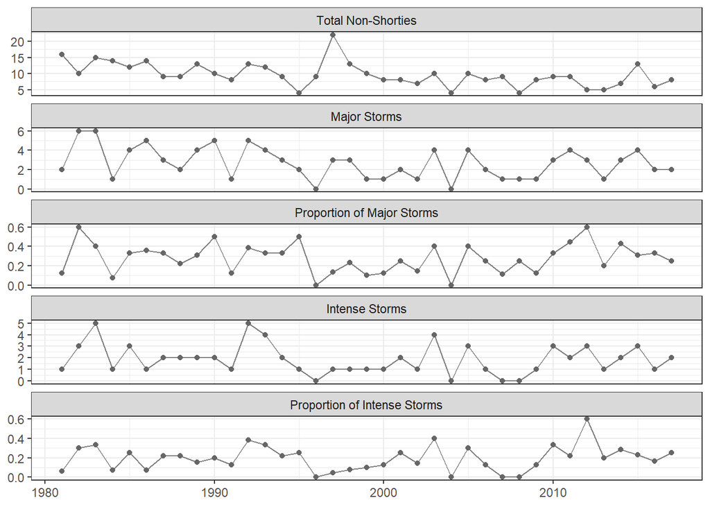

### Regression Methods

#### Poisson Regression on non-Shorties

```
Call:  glm(formula = Total_Storms ~ YearsSinceStart, family = poisson(link = "log"),
    data = storm_basin)

Coefficients:
    (Intercept)  YearsSinceStart
        2.58622         -0.01834

Degrees of Freedom: 36 Total (i.e. Null);  35 Residual
Null Deviance:      49.84
Residual Deviance: 36.19    AIC: 190.4
```

```
Single term deletions

Model:
Total_Storms ~ YearsSinceStart
                Df Deviance    AIC    LRT  Pr(>Chi)
<none>               36.187 190.44
YearsSinceStart  1   49.835 202.08 13.649 0.0002204 ***
---
Signif. codes:  0 '***' 0.001 '**' 0.01 '*' 0.05 '.' 0.1 ' ' 1
```

Using this model, we would predict 13.2795406 storms in 1981 and 6.861628 storms in 2017.

That is a change of -1.734571 storms per decade.

#### Poisson Regression on Major Storms

```
Call:  glm(formula = Major_Storms ~ YearsSinceStart, family = poisson(link = "log"),
    data = storm_basin)

Coefficients:
    (Intercept)  YearsSinceStart
        1.30184         -0.01876

Degrees of Freedom: 36 Total (i.e. Null);  35 Residual
Null Deviance:      39.6
Residual Deviance: 35.67    AIC: 137.5
```

```
Single term deletions

Model:
Major_Storms ~ YearsSinceStart
                Df Deviance    AIC    LRT Pr(>Chi)
<none>               35.673 137.53
YearsSinceStart  1   39.596 139.45 3.9231  0.04763 *
---
Signif. codes:  0 '***' 0.001 '**' 0.01 '*' 0.05 '.' 0.1 ' ' 1
```

Using this model the number of a major storm in 1981 was 3.6760514 and 1.8712758 in 2017.

That is a change of -0.4877772 storms per decade.

#### Poisson Regression on Intense Storms

```
Call:  glm(formula = Intense_Storms ~ YearsSinceStart, family = poisson(link = "log"),
    data = storm_basin)

Coefficients:
    (Intercept)  YearsSinceStart
        0.80398         -0.01126

Degrees of Freedom: 36 Total (i.e. Null);  35 Residual
Null Deviance:      36.1
Residual Deviance: 35.13    AIC: 122.1
```

```
Single term deletions

Model:
Intense_Storms ~ YearsSinceStart
                Df Deviance    AIC    LRT Pr(>Chi)
<none>               35.127 122.09
YearsSinceStart  1   36.105 121.07 0.9778   0.3227
```

Using this model the number of a intense storms in 1981 was 2.2344057 and 1.4900107 in 2017.

That is a change of -0.2011878 storms per decade.

#### Logistic Regression on Proportions of Major

```
Call:  glm(formula = cbind(Major_Storms, Non_Major) ~ YearsSinceStart,
    family = binomial, data = prop_data)

Coefficients:
    (Intercept)  YearsSinceStart
     -0.9604998       -0.0005594

Degrees of Freedom: 36 Total (i.e. Null);  35 Residual
Null Deviance:      41.15
Residual Deviance: 41.14    AIC: 130.3
```

```
Single term deletions

Model:
cbind(Major_Storms, Non_Major) ~ YearsSinceStart
                Df Deviance    AIC      LRT Pr(>Chi)
<none>               41.143 130.33
YearsSinceStart  1   41.145 128.34 0.002559   0.9597
```

Using this model the probability of a major storm in 1981 was 0.2767781 and 0.272765 in 2017.

That is a change of -0.1084621 percent per decade.

#### Logistic Regression on Proportions of Intense

```
Call:  glm(formula = cbind(Intense_Storms, Non_Intense) ~ YearsSinceStart,
    family = binomial, data = prop_data)

Coefficients:
    (Intercept)  YearsSinceStart
      -1.596106         0.008557

Degrees of Freedom: 36 Total (i.e. Null);  35 Residual
Null Deviance:      39.58
Residual Deviance: 39.11    AIC: 117.8
```

```
Single term deletions

Model:
cbind(Intense_Storms, Non_Intense) ~ YearsSinceStart
                Df Deviance    AIC     LRT Pr(>Chi)
<none>               39.112 117.77
YearsSinceStart  1   39.575 116.23 0.46368   0.4959
```

Using this model the probability of an intense storm in 1981 was 0.1685265 and 0.2161796 in 2017.

That is a change of 1.2879219 percent per decade.

### Changepoint Methods

#### Change in Non-Shorty Counts

```
  SCUSUM Stat chpt Location       p-value
 1.424489e+00  1.900000e+01  2.664233e-04
```

The dates suggest the changepoint would occur from 1999 to 2000 with $p$-value 2.6642335^{-4}.

In regime one, the mean number of total storms is 11.6842105 and in regime two, the mean number of storms is 7.6666667; a change of -4.0175439.

#### Change in counts of major storms

```
  SCUSUM Stat chpt Location       p-value
   0.52027949   14.00000000    0.03820727
```

The dates suggest the changepoint would occur from 1994 to 1995 with $p$-value 0.0382073.

In regime one, the mean number of major storms is 3.6428571 and in regime two, the mean number of storms is 2.0869565; a change of -1.5559006.

#### Change in counts of intense storms

```
  SCUSUM Stat chpt Location       p-value
    0.1813797    14.0000000     0.3445764
```

The dates suggest the changepoint would occur from 1994 to 1995 with $p$-value 0.3445764.

In regime one, the mean number of intense storms is 2.4285714 and in regime two, the mean number of storms is 1.4782609; a change of -0.9503106.

#### Proportion of major storms

A change in the proportion of major storms?

```
  SCUSUM Stat chpt Location       p-value
    0.1310477    15.0000000     0.5196784
```

The change in proportions occurs 1995 to 1996 with $p$-value 0.5196784.

In regime one, the proportion of major storms is 0.3154762 and in regime two, the proportion of major storms is 0.2395833; a change of -0.0758929.

#### Proportion of intense storms

A change in the proportion of major storms?

```
  SCUSUM Stat chpt Location       p-value
    0.1160233    29.0000000     0.5948072
```

The change in proportions occurs 2009 to 2010 with $p$-value 0.5948072.

In regime one, the proportion of intense storms is 0.1711409 and in regime two, the proportion of major storms is 0.2741935; a change of 0.1030526.

## HURSAT Test Results

**Generalized Linear Model Approaches**

Note:

- we report the Likelihood Ratio Test for the generalized linear models, this is better to use than the default $Z$-test provided in the `summary()` output.
- the Change per decade is found by comparing the predicted value at the start time (1981) and end time (2017) and scaling by the number of years $\times 10$.

| Response | Coefficent | p.value | Start | End | Change per Decade |
| --- | --- | --- | --- | --- | --- |
| Cyclone Freq | -0.01834 | 0.00022 | 13.27954 | 6.86163 | -1.73457 |
| Major Freq | -0.01876 | 0.04763 | 3.67605 | 1.87128 | -0.48778 |
| Prop Major | -0.00056 | 0.95965 | 27.67781 | 27.27650 | -0.10846 |
| Intense Freq | -0.01126 | 0.32274 | 2.23441 | 1.49001 | -0.20119 |
| Prop Freq | 0.00856 | 0.49591 | 16.85265 | 21.61796 | 1.28792 |

**Changepoint Methods**

| Response | Chpt.Location | p.value | Regime1 | Regime2 | Change | Perc_Change |
| --- | --- | --- | --- | --- | --- | --- |
| Cyclone Freq | 2000 | 0.00027 | 11.68421 | 7.66667 | -4.01754 | -34.38438 |
| Major Freq | 1995 | 0.03821 | 3.64286 | 2.08696 | -1.55590 | -42.71100 |
| Prop Major | 1996 | 0.51968 | 31.54762 | 23.95833 | -7.58929 | -24.05660 |
| Intense Freq | 1995 | 0.34458 | 2.42857 | 1.47826 | -0.95031 | -39.13043 |
| Prop Freq | 2010 | 0.59481 | 17.11409 | 27.41935 | 10.30526 | 60.21505 |

## Trimmed IBTRacs Full Analysis

### Summary Statistics (overall)

| Total Storms (Avg) | Total Storms (stddev) | Major Storms (Avg) | Major Storms (stddev) | Prop Major Storms | Intense Storms (Avg) | Intense Storms (stddev) | Prop Intense Storms |
| --- | --- | --- | --- | --- | --- | --- | --- |
| 8.459459 | 3.254011 | 2.675676 | 1.546574 | 0.3162939 | 1.486487 | 1.282827 | 0.1757188 |

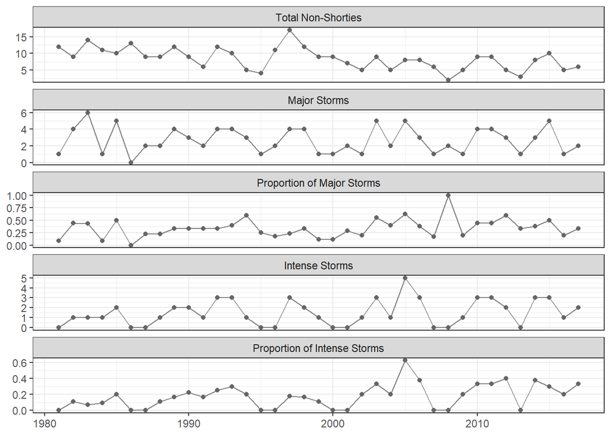

### Regression Methods

#### Poisson Regression on non-Shorties

```
Call:  glm(formula = Total_Storms ~ YearsSinceStart, family = poisson(link = "log"),
    data = storm_basin)

Coefficients:
    (Intercept)  YearsSinceStart
        2.46069         -0.01925

Degrees of Freedom: 36 Total (i.e. Null);  35 Residual
Null Deviance:      46.97
Residual Deviance: 33.92    AIC: 182.7
```

```
Single term deletions

Model:
Total_Storms ~ YearsSinceStart
                Df Deviance    AIC    LRT Pr(>Chi)
<none>               33.915 182.65
YearsSinceStart  1   46.967 193.70 13.052 0.000303 ***
---
Signif. codes:  0 '***' 0.001 '**' 0.01 '*' 0.05 '.' 0.1 ' ' 1
```

Using this model, we would predict 11.7128907 storms in 1981 and 5.8581317 storms in 2017.

That is a change of -1.5823673 storms per decade.

#### Poisson Regression on Major Storms

```
Call:  glm(formula = Major_Storms ~ YearsSinceStart, family = poisson(link = "log"),
    data = storm_basin)

Coefficients:
    (Intercept)  YearsSinceStart
       1.042615        -0.003279

Degrees of Freedom: 36 Total (i.e. Null);  35 Residual
Null Deviance:      34.87
Residual Deviance: 34.75    AIC: 138.3
```

```
Single term deletions

Model:
Major_Storms ~ YearsSinceStart
                Df Deviance    AIC     LRT Pr(>Chi)
<none>               34.747 138.32
YearsSinceStart  1   34.869 136.44 0.12132   0.7276
```

Using this model the number of a major storm in 1981 was 2.8366243 and 2.5207675 in 2017.

That is a change of -0.0853667 storms per decade.

#### Poisson Regression on Intense Storms

```
Call:  glm(formula = Intense_Storms ~ YearsSinceStart, family = poisson(link = "log"),
    data = storm_basin)

Coefficients:
    (Intercept)  YearsSinceStart
       -0.02892          0.02209

Degrees of Freedom: 36 Total (i.e. Null);  35 Residual
Null Deviance:      48.45
Residual Deviance: 45.44    AIC: 117.5
```

```
Single term deletions

Model:
Intense_Storms ~ YearsSinceStart
                Df Deviance    AIC  LRT Pr(>Chi)
<none>               45.439 117.53
YearsSinceStart  1   48.449 118.54 3.01  0.08275 .
---
Signif. codes:  0 '***' 0.001 '**' 0.01 '*' 0.05 '.' 0.1 ' ' 1
```

Using this model the number of an intense storm in 1981 was 0.9714986 and 2.1520313 in 2017.

That is a change of 0.3190629 storms per decade.

#### Logistic Regression on Proportions of Major

```
Call:  glm(formula = cbind(Major_Storms, Non_Major) ~ YearsSinceStart,
    family = binomial, data = prop_data)

Coefficients:
    (Intercept)  YearsSinceStart
        -1.1555           0.0236

Degrees of Freedom: 36 Total (i.e. Null);  35 Residual
Null Deviance:      45.07
Residual Deviance: 40.86    AIC: 127.3
```

```
Single term deletions

Model:
cbind(Major_Storms, Non_Major) ~ YearsSinceStart
                Df Deviance    AIC   LRT Pr(>Chi)
<none>               40.862 127.29
YearsSinceStart  1   45.068 129.49 4.206  0.04028 *
---
Signif. codes:  0 '***' 0.001 '**' 0.01 '*' 0.05 '.' 0.1 ' ' 1
```

Using this model the probability of a major storm in 1981 was 0.2394922 and 0.4241289 in 2017.

That is a change of 4.9901835 percent per decade.

#### Logistic Regression on Proportions of Intense

```
Call:  glm(formula = cbind(Intense_Storms, Non_Intense) ~ YearsSinceStart,
    family = binomial, data = prop_data)

Coefficients:
    (Intercept)  YearsSinceStart
       -2.44487          0.05097

Degrees of Freedom: 36 Total (i.e. Null);  35 Residual
Null Deviance:      52.38
Residual Deviance: 39.42    AIC: 103.8
```

```
Single term deletions

Model:
cbind(Intense_Storms, Non_Intense) ~ YearsSinceStart
                Df Deviance    AIC    LRT  Pr(>Chi)
<none>               39.421 103.82
YearsSinceStart  1   52.379 114.78 12.959 0.0003184 ***
---
Signif. codes:  0 '***' 0.001 '**' 0.01 '*' 0.05 '.' 0.1 ' ' 1
```

Using this model the probability of an intense storm in 1981 was 0.0798148 and 0.3520466 in 2017.

That is a change of 7.3576155 percent per decade.

### Changepoint Methods

#### Change in Non-Shorty Counts

```
  SCUSUM Stat chpt Location       p-value
 1.375162e+00  2.000000e+01  3.458904e-04
```

The dates suggest the changepoint would occur from 2000 to 2001 with $p$-value 3.4589045^{-4}.

In regime one, the mean number of total storms is 10.15 and in regime two, the mean number of storms is 6.4705882; a change of -3.6794118.

#### Change in counts of major storms

```
  SCUSUM Stat chpt Location       p-value
   0.03115892   18.00000000    0.97111221
```

The dates suggest the changepoint would occur from 1998 to 1999 with $p$-value 0.9711122.

In regime one, the mean number of major storms is 2.8888889 and in regime two, the mean number of storms is 2.4736842; a change of -0.4152047.

#### Change in counts of intense storms

```
  SCUSUM Stat chpt Location       p-value
    0.3176174    22.0000000     0.1329380
```

The dates suggest the changepoint would occur from 2002 to 2003 with $p$-value 0.132938.

In regime one, the mean number of intense storms is 1.1363636 and in regime two, the mean number of storms is 2; a change of 0.8636364.

#### Proportion of major storms

A change in the proportion of major storms?

```
  SCUSUM Stat chpt Location       p-value
   0.46419284   22.00000000    0.05334794
```

The change in proportions occurs 2002 to 2003 with $p$-value 0.0533479.

In regime one, the proportion of major storms is 0.2651163 and in regime two, the proportion of major storms is 0.4285714; a change of 0.1634551.

#### Proportion of intense storms

A change in the proportion of major storms?

```
  SCUSUM Stat chpt Location       p-value
  0.801316572  21.000000000   0.007692289
```

The change in proportions occurs 2001 to 2002 with $p$-value 0.0076923.

In regime one, the proportion of intense storms is 0.1142857 and in regime two, the proportion of major storms is 0.3009709; a change of 0.1866852.

## Trimmed IBTRacs Test Results

**Generalized Linear Model Approaches**

Note:

- we report the Likelihood Ratio Test for the generalized linear models, this is better to use than the default $Z$-test provided in the `summary()` output.
- the Change per decade is found by comparing the predicted value at the start time (1981) and end time (2017) and scaling by the number of years $\times 10$.

| Response | Coefficent | p.value | Start | End | Change per Decade |
| --- | --- | --- | --- | --- | --- |
| Cyclone Freq | -0.01925 | 0.00030 | 11.71289 | 5.85813 | -1.58237 |
| Major Freq | -0.00328 | 0.72761 | 2.83662 | 2.52077 | -0.08537 |
| Prop Major | 0.02360 | 0.04028 | 23.94922 | 42.41289 | 4.99018 |
| Intense Freq | 0.02209 | 0.08275 | 0.97150 | 2.15203 | 0.31906 |
| Prop Freq | 0.05097 | 0.00032 | 7.98148 | 35.20466 | 7.35762 |

**Changepoint Methods**

| Response | Chpt.Location | p.value | Regime1 | Regime2 | Change | Perc_Change |
| --- | --- | --- | --- | --- | --- | --- |
| Cyclone Freq | 2001 | 0.00035 | 10.15000 | 6.47059 | -3.67941 | -36.25036 |
| Major Freq | 1999 | 0.97111 | 2.88889 | 2.47368 | -0.41520 | -14.37247 |
| Prop Major | 2003 | 0.05335 | 26.51163 | 42.85714 | 16.34551 | 61.65414 |
| Intense Freq | 2003 | 0.13294 | 1.13636 | 2.00000 | 0.86364 | 76.00000 |
| Prop Freq | 2002 | 0.00769 | 11.42857 | 30.09709 | 18.66852 | 163.34951 |

## References

Lund, Robert B, Claudie Beaulieu, Rebecca Killick, QiQi Lu, and Xueheng Shi. 2023. “Good Practices and Common Pitfalls in Climate Time Series Changepoint Techniques: A Review.” *Journal of Climate* 36 (23): 8041–57.

McCullagh, Peter, and J. A. Nelder. 2019. *Generalized Linear Models*. Routledge.

Robbins, Michael W, Robert B Lund, Colin M Gallagher, and QiQi Lu. 2011. “Changepoints in the North Atlantic Tropical Cyclone Record.” *Journal of the American Statistical Association* 106 (493): 89–99.

Tolmatz, Leonid. 2002. “On the Distribution of the Square Integral of the Brownian Bridge.” *The Annals of Probability* 30 (1): 253–69. https://doi.org/10.1214/aop/1020107767.